[figure not shown]

# 什么是数理逻辑？

# **What Is Mathematical Logic?**

# 什么是数理逻辑？

# **What Is Mathematical Logic?**

J. N. 克罗斯利

**J.N. Crossley**

C. J. 阿什

**C.J. Ash**

C. J. 布里克希尔

**C.J. Brickhill**

J. C. 斯蒂尔韦尔

**J.C. Stillwell**

N. H. 威廉斯

**N.H. Williams**

多佛出版公司

**DOVER PUBLICATIONS, IC.**

纽约

**New York**

版权 © 1972，牛津大学出版社。

Copyright © 1972 by Oxford University Press.

依照《泛美版权公约》及国际版权公约，保留所有权利。

All rights reserved under Pan American and International Copyright Conventions.

本多佛版于 1990 年首次出版，是牛津大学出版社 1972 年初版的完整、未经改动的重印本。经纽约州纽约市麦迪逊大道 200 号牛津大学出版社特别授权重印，邮编 10016。

This Dover edition, first published in 1990, is an unabridged and unaltered republication of the work first published by the Oxford University Press in 1972. It is reprinted by special arrangement with Oxford University Press, Inc., 200 Madison Ave., New York, N.Y. 10016.

作者：J. N. 克罗斯利，数学与计算机科学教授；C. J. 阿什，数学高级讲师；J. C. 斯蒂尔韦尔，数学高级讲师，以上三位任职于澳大利亚维多利亚州克莱顿的莫纳什大学；N. H. 威廉斯，数学高级讲师，任职于澳大利亚昆士兰州布里斯班圣卢西亚的昆士兰大学；C. J. 布里克希尔，美国纽约市 Intelcom Data Systems 公司总裁。

The authors: J.N. Crossley, Professor, Mathematics and Computer Science, C.J. Ash, Reader, Mathematics, J.C. Stillwell, Senior Lecturer, Mathematics, Monash University, Clayton, Victoria, Australia; N.H. Williams, Senior Lecturer, Mathematics, University of Queensland, St. Lucia, Brisbane, Queensland, Australia; C.J. Brickhill, President, Intelcom Data Systems Inc., New York, N.Y.

美国国会图书馆在版编目数据

**Library of Congress Cataloging-in-Publication Data**

《什么是数理逻辑？》／J. N. 克罗斯利等著。

What is mathematical logic? / J.N. Crossley ... [et al.].

页数；厘米。

p. cm.

含参考文献及索引。

Includes bibliographical references (p. ) and index.

电子书 ISBN-13：978-0-486-15152-6

eISBN 13: 978-0-486-15152-6

1. 符号逻辑与数理逻辑。I. 克罗斯利，约翰·N. QA9.W47 1990

1. Logic, Symbolic and mathematical. I. Crossley, John N. QA9.W47 1990

511.3—dc20

511.3—dc20

90-3739

在版编目

CIP

由 Courier 公司在美国印制

Manufactured in the United States by Courier Corporation

26404106

www.doverpublications.com

www.doverpublications.com

## 前言

## Preface

本书所依据的系列讲座由克里斯·布里克希尔和约翰·克罗斯利构思。我们的目的是介绍现代数理逻辑中十分重要的思想，而不涉及专业逻辑研究者所需的细致数学推演。这些讲座于 1971 年秋冬两季在莫纳什大学和墨尔本大学举行。讲座受到欢迎，促使我们编写了本书，希望没有受过数学训练的读者也能由此领略数理逻辑令人振奋的一面。

THE lectures on which this book is based were conceived by Chris Brickhill and John Crossley. Our aim was to introduce the very important ideas in modern mathematical logic without the detailed mathematical work which is required of those with a professional interest in logic. The lectures were given at Monash University and the University of Melbourne in the autumn and winter of 1971. Their popularity induced us to produce this book which we hope will give some idea of the exciting aspects of mathematical logic to those who have no mathematical training.

还要补充的是，我们十分乐于讲授这些内容，听众的反应超出了我们的所有预期。感谢莫纳什大学约翰·麦格奇副教授和墨尔本大学道格拉斯·加斯金教授对这项工作的有力支持。也感谢丹尼斯·罗宾逊和特里·伯姆协助克里斯·布里克希尔准备讲义。最后，感谢安妮-玛丽·范登贝格出色地完成打字工作。

We must add that we very much enjoyed giving these lectures and that the audience response exceeded all our expectations. We thank Associate Pro¬fessor John McGechie of Monash University and Professor Douglas Gasking of the University of Melbourne who so ably supported us in this venture. We must also thank Dennis Robinson and Terry Boehm for their assistance to Chris Brickhill in the preparation of these notes. Finally we thank Anne-Marie Vandenberg who so masterfully dealt with the typing.

J. N. 克罗斯利

J. N. CROSSLEY

艾尔斯岩

*Ayers Rock*

1971 年 8 月

August 1971

## 目录

## Contents

引言

Introduction

延伸阅读建议

Some Suggestions for Further Reading

索引

Index

## 引言

## Introduction

数理逻辑是一门生机勃勃、活跃发展的学科。我们希望本书略显不拘常规的写作风格能够传达这一点。最初的讲座由四位作者讲授，但内容后来经过大幅改写，因此似乎不宜再详细标明各部分的作者。

MATHEMATICAL logic is a living and lively subject. We hope that this will be conveyed by the somewhat unconventional style in which this book is written. Originally lectures were given by four of the authors but they have been so revamped that it seemed inappropriate to specify the authorship in detail.

我们希望并相信，任何读者日后若完整修读一门逻辑课程，都能把本书中的所有证明梗概补充为完整证明。

It is our hope and belief that any reader who later undergoes a full course in logic would be able to fill out all our sketches into full proofs.

各章在许多方面彼此独立，不过第 5、6 章会用到第 2、3 章的一些内容。建议读者若觉得某一章困难，可以先读另一章，稍后再回来。这样也许会发现，原先的困难已减轻了。

The chapters are in many ways independent, though items from Chapters 2 and 3 are used in Chapters 5 and 6, and we suggest that a reader who finds a chapter difficult should turn to another one and return to the first one later. In this way you may find the difficulties have been ameliorated.

## 1. 历史概述

## 1. Historical Survey

逻辑的各个领域，是在复杂的历史进程中，由种种困难和新发现促成的。因此，第 1 章将围绕一张流程图展开说明（见第 2 页）。我会相当简略地介绍各个领域，若遇到许多陌生术语，不必担心，后文会加以解释。我打算把这段历史看成两条源远流长的线索：一条是形式演绎的历史，当然可以追溯到亚里士多德、欧几里得及其同时代的人；另一条是数学分析的历史，可以追溯到同一时代的阿基米德。两条线索长期独立发展，直到大约 1600—1700 年，牛顿和莱布尼茨发明微积分，最终使数学与逻辑走到一起。

THE different areas in logic emerged as a result of difficulties and new discoveries in a complicated history, so this first chapter is going to describe a flow chart (*see* p. 2). I shall skip rather briefly over the different areas, so do not be worried if you find a lot of strange terminology—it will be explained later on in the book. I am going to view the history as two different streams, both of which are very long: one is the history of formal deduction which goes back, of course, to Aristotle and Euclid and others of that era, and the other is the history of mathematical analysis which can be dated back to Archimedes in the same era. These two streams developed separately for a long time—until around 1600–1700, when we have Newton and Leibnitz and their invention of the calculus, which was ultimately to bring mathematics and logic together.

两条线索在 19 世纪开始汇合，不妨大致定在 1850 年前后。当时，布尔、弗雷格等逻辑学家试图为形式演绎究竟是什么给出最终而明确的形式。亚里士多德已提出相当明确的演绎规则，但使用的是自然语言。布尔希望更进一步，发展出纯粹的符号系统。弗雷格将其扩展，形成谓词演算；事实证明，它足以作为当今全部数学的逻辑基础。从此以后，符号变得极其重要，因此值得稍作说明，看看符号语言是什么样的。

The two streams start to converge in the 19th century, let us say arbitrarily about 1850, when we have logicians such as Boole and Frege attempting to give a final and definitive form to what formal deduction actually was. Now Aristotle had made rather explicit rules of deduction, but he had stated them in natural language. Boole wanted to go further than this and he developed a purely symbolic system. This was extended by Frege, who arrived at the predicate calculus which turned out to be an adequate logical basis for all of today’s mathematics. Perhaps I can dwell a little on this, since symbolism became so important from this point onwards. A little description of what symbolism can look like will help.

纯逻辑联结词，例如“且”“或”“非”，分别用 &、V、 等符号表示；还需要 x、y、z 等变量符号，以及表示谓词（性质或关系）的 P、Q、R。由此组成公式，例如 P(x) V Q(x)，读作“x 具有性质 P，或者 x 具有性质 Q”。再以 ∀x 表示“对所有 x”，以 x 表示“存在一个 x”，便可以量化。因此，∀x P(x) 表示每个 x 都具有性质 P。

Purely logical connectives, such as *and*, *or*, *not* are given symbols such as **&**, V, ; need symbols (*x*, *y*, *z* and so on) for variables and also symbols *P*, *Q*, *R* for predicates (or properties or relations). Out of these we make formulae such as this: *P*(*x*) V *Q*(*x*), which is read as saying that *x* has property *P* or *x* has property *Q*, and this can be quantified by expressing ‘for all *x*’ by ∀*x* and ‘there exists an *x*’ by *x*. Thus ∀*x* *P*(*x*) says every *x* has property *P*.

只要适当选择谓词字母，任何数学领域都能翻译成这种语言。例如在算术中，变量所指的对象是数，我们要表达数的各种性质，例如相等，或两个数与第三个数之间的关系，其中第三个数是前两个数的和；还可以有乘积关系。你很快就能确信，数论中通常涉及整除、素数、某个数是否为另两个数之和的所有陈述，都能用这些谓词表达。弗雷格给出了在这种语言中进行演绎的规则，整个体系就称为谓词演算。

Now any mathematical domain can be translated into this language with a suitable choice of predicate letters: arithmetic, for instance. We have numbers as the objects that the variables will denote, and we have various properties of numbers that we wish to express, such as being equal or the relationship between two numbers and a third one which is the sum of the other two; another one could be the product relationship. You can quickly convince yourself that all statements that we are accustomed to make in number theory about divisibility, prime numbers, and whether one number is the sum of another two can be made using these predicates. Frege gave rules for making deductions in this language and the whole conglomeration is called *predicate* *calculus*.

历史发展图：形式演绎一线由布尔、弗雷格通向谓词演算；分析学一线由波尔查诺、戴德金、康托尔通向集合论。约 1850—1880 年，两条线索汇合。约 1900 年，罗素提出“数学＝逻辑＋集合论”，同时出现悖论；康托尔的对角线论证区分可数集与不可数集。1915 年，勒文海姆、斯科伦发展可数模型理论；1930 年，哥德尔证明谓词演算完备性；1931 年，证明算术不完备性；1936 年，图灵推动递归函数理论；1938 年，哥德尔证明连续统假设与选择公理的相对一致性；1963 年，科恩证明它们的独立性。

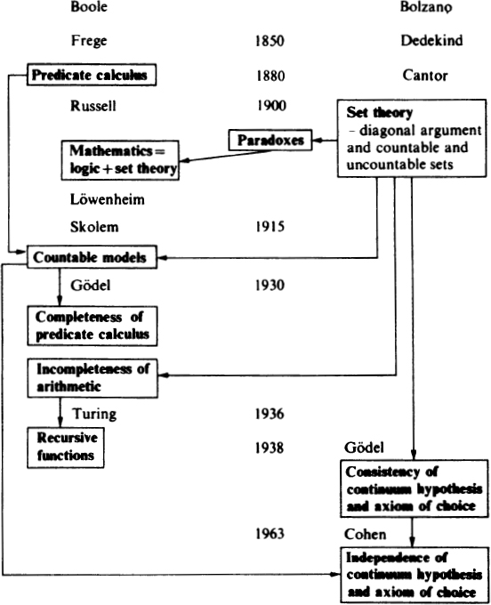

与此同时，分析学界曾连续几个世纪争论牛顿引入的导数和积分等概念的含义，因为他谈到了无穷小。许多人不相信无穷小，认为它们会导致矛盾，事实上当时的说法确实如此。然而牛顿仍得出了正确结果。为了弄清原因，人们澄清了这些概念，作出贡献的包括波尔查诺、戴德金和康托尔。（时间已来到约 1880 年。）他们认识到，要恰当地处理导数和积分，必须考虑无限集合，而且必须极其精确，无法绕开无限集合。这就是集合论的起源。

Now meanwhile in analysis there was a long period, a couple of centuries, of controversy over the meaning of concepts that Newton introduced—the derivative and the integral—because he talked about infinitesimals. A lot of people did not believe in these and thought they were contradictory, which they were. But nevertheless he got the right results and, to find out why he got the right results, clarification of the notions was made. Some of the people responsible for this were Bolzano, Dedekind, and Cantor. (This brings us down to about 1880.) These people realized that, to deal adequately with derivatives and integrals, infinite sets had to be considered, and considered very precisely. There was no way of avoiding infinite sets. This was the origin of set theory.

值得指出的是，康托尔是从分析学问题进入集合论的。他并非试图定义自然数，或后来人们用集合论处理的其他对象；他最初的动机是分析实数的无限集合。我认为这才是集合论真正适合的领域：解决这类问题，而不是定义原始概念。当然，后者也能做到，弗雷格就这样做过，尽管其体系实际上不一致，后来由罗素纠正。罗素坚信数学就是逻辑。他所说的逻辑，比今天我们理解的范围大得多。我们会说，他真正表明的是数学等于逻辑加集合论。只要有足够耐心，允许定义足够长，任何数学领域都能用逻辑和集合论来定义，所有证明都能在谓词演算中完成。

I think it is worth pointing out that Cantor had got into set theory from a problem in analysis. He was not trying to define natural numbers or any of the other things that people have used set theory for since. His original motivation was analysis of infinite sets of real numbers. And I think this is really the proper domain of set theory: to solve problems like that rather than problems of definition of primitive concepts. This *can* be done and it was done by Frege (actually in an inconsistent way, but this was put right by Russell). Russell was dedicated to the proposition that mathematics was just logic. Logic to Russell was a lot more than we would consider logic today. We would say that really he showed that mathematics was logic and set theory. With sufficient patience and sufficient lengths of definitions any mathematical field can be defined in terms of logic and set theory and all the proofs carried out within the predicate calculus.

不过，康托尔此时已走得更远。他远远超出了求解分析学问题的范围，对集合本身产生兴趣，并真正发现了集合的魅力。（稍后会看到，他的集合论成果也反过来影响了分析学。）这里至少应介绍康托尔结果的两个证明，因为这些论证完全是革命性的，此后渗透了整个逻辑学。我觉得，多数定理都能追溯到下面将介绍的某一种论证。研究无限集合时，康托尔很快发现，许多无限集合与自然数（整数）集合相似，可以与之建立一一对应。伽利略早已在偶数这一简单例子中认识到这种对应，但他颇为不安，以为这摧毁了区分无限集合大小的一切希望，认为这种概念必定毫无意义。康托尔却不在意：我们仍然说这两个集合具有相同的无限大小，再看看还有多少集合能与自然数集合匹配。他的第一个重大发现是，有理数可以与自然数一一对应。（有理数是分数 p/q，其中 p、q 为自然数，q ≠ 0。）

But of course Cantor was jumping ahead at this stage. He went way beyond trying to solve problems in analysis; he was interested in sets themselves and he really discovered how fascinating they were. (His results in set theory did feed back into analysis, as we shall see in a moment.) I think it is important to give you at least two proofs here of Cantor’s results because the arguments he used were totally revolutionary and they have permeated the whole of logic ever since then. In fact most of the theorems, I feel, can be traced back to one or other of these arguments that I am about to describe. Cantor, in considering infinite sets, quickly came to the realization that a lot of infinite sets were similar to the set of natural (whole) numbers in the sense that they could be put in one-to-one correspondence with them. This was already known to Galileo in the simple case of even numbers. Galileo realized this correspondence existed and he was rather distraught about it, because he thought this ruined all hope of describing different sizes of infinite sets; he thought the concept must be meaningless. But Cantor was not bothered about this; he said we shall nevertheless say that these two sets are of the same infinite size, and then see how many other sets we can match with the set of natural numbers. And his first major discovery was that the rational numbers can be put in one-to-one correspondence with the natural numbers. (The rational numbers are the fractions *p/q*, where *p* and *q* are natural numbers, *q* ≠ 0.)

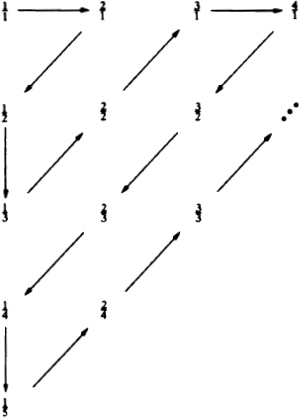

实数对应于直线上的点，也就是构成连续统的全部点，可以用无限小数展开表示，而且通常必须无限展开，例如 √2 就是无限小数，没有有限小数表示。因此，若要建立实数与自然数的对应，就要先把 0 与某个无限小数匹配（这里只考虑 0 与 1 之间的实数，小数点前没有其他内容），再把 1 与某个无限小数匹配，再匹配 2，依此类推，希望得到包含所有实数的列表。康托尔指出，无论怎样尝试都必定失败：给定任何列表，我们都能构造一个数，让它第一位小数不同于列表第一个数的第一位，第二位不同于第二个数的第二位，第三位不同于第三个数的第三位，如此继续，得到一个与列表中每个数都不同的无限小数。无论列表是什么，这个方法都有效。因此实数与自然数之间不可能一一对应，我们由此发现了一个更大的无限集合。

Now the real numbers, which correspond to the points on the line (all points on the line, forming a continuum) can be expressed by infinite decimal expansions and in general the decimal expansion has to be infinite ( for instance is an infinite decimal; there is no finite representation for it). So if we are going to make a correspondence between the real numbers and the natural numbers it will look something like this: we start by matching zero with some infinite decimal. (I just consider real numbers between zero and one, so there is nothing in front of the decimal point.) Next one is matched with some infinite decimal, then two is matched with some infinite decimal, and so on. Our ambition is somehow to get a list with all the real numbers in. Cantor said that no matter how you try to do this you fail, for the following reason: for any list that is given we can construct a number that is different from the first number by writing down a different digit in the first decimal place. We can make the number different from the second number by making it different in the second decimal place and we can make it different from the third number by making it different in the third decimal place, and by continuing in this way we get a real number that is an infinite decimal that is different from any number of the list. And it does not matter what the list is, this method will always work. So there cannot be any correspondence between the real numbers and the natural numbers, and so we have discovered a larger infinite set.

康托尔还推广了这一论证。任取集合 S，S 不可能与其所有子集构成的集合 {T:T ⊆ S} 一一对应。虽然看起来不同，论证实质与前面相同。姑且把 S 的成员排成一个“列表”；它们未必真的能列举，只需想象正在把 S 的成员与 S 的子集匹配。设 Tₛ 是与成员 s 匹配的子集。康托尔立即构造出一个不在列表中的子集 U：它包含那些不属于与自己匹配的子集的成员 s。因为 s 要么属于 Tₛ，要么不属于，我们总能使 U 在 s 这一点上不同于 Tₛ：若 s ∈ Tₛ，就不把 s 放进 U；若 s ∉ Tₛ，就把 s 放进 U。因此，S 的子集比能与 S 的成员一一匹配的还多，任何匹配都会遗漏这样的 U。

Cantor gave an elaboration of this argument too, which I shall briefly describe. Take any set, *S*: you cannot put *S* in one-to-one correspondence with the set of all its subsets, that is, the set {*T:T* ⊆ *S*}. And the argument is really the same as the previous one, though it looks a bit different. This time we shall make what we would loosely call a list of the members of *S*. They might not be a listable set, but just imagine that somehow we are trying to match the members of *S* with the subsets of *S*. And let *T<sub>s</sub>* be the subset that we match with the member *s*. Cantor immediately constructs a subset which is not on this list. He constructs a subset *U* consisting of the members *s* which are matched with a subset to which they do not belong. Now if you think about it we are making *U* different from every subset *T* because *T<sub>s</sub>* either has *s* as an element or it does not. Either way we make *U* different from *T<sub>s</sub>* with respect to this element *s*. If *s* is in *T<sub>s</sub>*, we leave *s* out of *U*. If *s* is not in *T<sub>s</sub>* we put s in *U*. Thus there are more subsets of *S* than can ever be matched one-to-one with the members of *S*—any such matching omits a set *U* such as we have described.

还可以再进一步：假设 S 是宇宙中所有集合构成的集合。取 S 的所有子集，这应该又是一个集合。上述论证似乎表明，从宇宙中的全部集合出发再取子集，还能得到更多集合，但不可能比宇宙中的全部集合还多。康托尔意识到了这个问题，却泰然处之，我觉得这很有洞察力。罗素也发现了这个问题，并为之忧虑。这就是臭名昭著的罗素悖论，或者至少是与之非常相近的问题。

Now there is one further step you can take in this argument: suppose *S* is the set of all sets in the universe. Take the subsets of *S*—that is, another set, or it ought to be. This argument seems to be saying that if you start with all of the sets in the universe and take all the subsets, you get more. But you cannot get more than there is in the universe. Cantor was aware of this problem but took it in his stride, which I think was very perceptive of him. Russell also found out about it, and he worried about it. This was the notorious Russell paradox, or something very similar to it anyway.

于是，把数学归结为逻辑和集合论的整个计划受到威胁，因为集合论此时显得很不可靠。数学家的首要任务立即变成清理集合论的基础，避免悖论。必须设法阻止把宇宙中所有集合的总体也视为集合。其实，只要坚持集合总是从已知的东西，例如自然数和实数，逐层构造，并且永不停止，总能再上升一层，就很容易做到：整个宇宙永不完成，只有已完成的东西才视为集合。策梅洛约在 1908 年提出了这一思想。罗素也做了类似的事，但方法技术上更笨重，今天已很少使用。1922 年，弗兰克尔和斯科伦帮助最终完善了它，形成一种似乎避开了这些问题的公理化集合论。

So this whole program of reducing mathematics to logic and set theory was endangered by the fact that set theory looked very dodgy at this point. Immediately the first concern of mathematicians was to clean up the basis of set theory so that paradoxes could not arise. Somehow we have to prevent the collection of all sets in the universe being considered as a set itself. And that is actually very easy to do, if you insist that sets are always built up from things that you know about to begin with—that is, the natural numbers and the real numbers—and you do not stop; you always consider it possible to go one level higher, so that you never complete the whole universe and only things which are completed are regarded as sets. Now this idea was suggested about 1908, by Zermelo. And Russell did a similar thing, though his method is technically more clumsy and is scarcely used today. The idea was finally polished up with the help of Fraenkel and Skolem in 1922. This was then an axiomatic set theory which seemed to avoid the problems.

大约同时，把数学归结为符号语言的观念又遇到另一个问题。我们起初心中有某个研究领域，可能是自然数，也可能是分析，然后转向只使用符号的形式理论，形式化到一切都成为机械操作。关于该领域的每个陈述都是符号串，演绎通过对符号的机械操作完成，得到称为定理的结果，它们是关于该领域的真陈述。看起来很好。但一组符号可以有许多不同的解释，也称模型；其中可能有与最初设想的领域完全不同的解释。因此必须谨慎地考虑理论的其他模型。勒文海姆于 1915 年证明了一个决定性结果，表明确实存在非预期解释，后来斯科伦加强了它，自然称为勒文海姆—斯科伦定理。

Around the same time another problem had developed with this conception of reducing mathematics to a symbolic language, and this was the following. So far, we had a certain domain of study in mind; it might have been the natural numbers or it might have been analysis and we have gone to a formal theory, just using symbols. And so formal that everything is just mechanical. Every statement about this domain is a series of symbols. We make the deductions by mechanical operations on the symbols. We get things out which we call theorems, and these are true statements about the domain. So that seems fine. But when we just have a collection of symbols, they are susceptible to many different interpretations (or models as they are called) and it is possible that interpretations exist that are entirely different from the domain we thought of in the first place. So to be careful we should consider other models, if there are any, of the theory. The decisive result which shows that there are definitely unintended interpretations was proved in 1915 by Löwenheim, and this was sharpened by Skolem. Naturally enough it is called the Löwenheim–Skolem Theorem.

下面略谈这个有趣的结果，它值得在流程图中单列一框。勒文海姆—斯科伦定理简单说就是：每个理论都有可数模型。这令人震惊，因为我们已经有不可数集合，以及本应描述不可数论域的理论，例如实数理论。因此，公理的模型可能肯定不是我们原来想要的。简要说明其原因：语言毕竟只有可数多个表达式，它们只是有限符号串；推广前面枚举有理数的方法，就能枚举理论的所有陈述。再考虑预期论域以及公理真正确定的内容。公理可以说某些初始对象存在，例如自然数理论中的 0；其他内容粗略地说是“如果某物存在，那么另一物必须存在”。因此满足公理并不需要太多对象：从初始对象开始，加入它们所要求的对象，再加入后者要求的对象，就能构造只含可数多个点的骨架。因为若只能对某论域说可数多件事，就只需可数多个对象满足这些陈述。

We shall talk a little about this interesting result. This deserves a box of its own in our chart. The Löwenheim–Skolem Theorem simply says that every theory has countable models. This was a tremendous shock because we already have uncountable sets and theories about these things, such as the theory of real numbers, that are supposed to be about uncountable domains. So we have models for axioms that are definitely not what we intended. I can briefly describe how this result comes about. First we observe that languages after all are only countable—they are just finite strings of symbols and by elaborating the technique of enumerating the rational numbers given above, you can enumerate all the statements in a theory. Now consider the intended domain and what the axioms really determine about it. Axioms can say that certain objects exist initially; for example, they can say that zero exists, if you talk about the natural numbers. If you analyze the other things they can say, roughly speaking they are things like: if such and such exists, then something else must exist. So not too many things are actually necessary in order to satisfy the axioms. We have to start with the initial objects and then what is needed because of them, and what is needed because of that, and so a skeleton can be built up which contains only countably many points. This is possible because, if you can only say countably many things about a certain domain, then only countably many objects are needed to satisfy those statements.

这一点看似明显，却长期未受注意。后来人们又困惑：集合论本应存在不可数多个对象，怎么也会这样？既然集合论公理能证明不可数集合存在，它们如何在可数论域中得到满足？这称为斯科伦悖论。它不是真正的悖论，后面会解决，但一个谈论不可数对象的理论居然能有可数模型，看起来确实矛盾。我们必须问：“可数”相对于一个模型是什么意思？第 3 章会讨论。这些问题极富启发性，后来促成了格外出色的定理。

Obvious as this may be, it escaped people’s attention for a long time and then it bothered them, of course, that such things can hold about set theory where there are supposed to be uncountably many objects existing. Since the axioms of set theory yield a proof that uncountable sets exist, how can they be satisfied in a countable domain? This state of affairs is called the Skolem paradox. It is not a real paradox and it gets resolved later, but there seems to be a paradox if theories can have countable models and yet there is a theory about uncountable things. We have to say: what does ‘countable’ mean in relation to a model? And this will be treated in Chapter 3. But this was very thought-provoking and it led to exceptionally good theorems later on.

直到这时，即 1920 年，事实上直到 1930 年，人们一直用谓词演算作逻辑演绎，却不确定是否由此得到所有有效陈述。至少在某些表述中，勒文海姆—斯科伦定理的论证类似于谓词演算完备性的证明。这是另一个里程碑，也是哥德尔证明的第一个重大结果，当然不是最后一个。“完备性”究竟是什么意思？在具有谓词符号、变量和量词的语言中，有些陈述无论如何解释符号都成立。无论 P 表示什么性质，变量遍历什么论域，∀x P(x) → ∃x P(x) 都为真，其中 → 表示蕴涵。谓词演算的目的，是以机械方式产生全部逻辑有效公式。哥德尔成功证明它是完备的，确实达到了这一目的。

All the time up until this (1920), and up to 1930 in fact, people had used predicate calculus for making logical deductions without finding out for sure whether they obtained all of the valid statements this way. The argument that was developed for the Löwenheim–Skolem theorem is similar, in some presentations at least, to a proof of the completeness of the predicate calculus. This is another milestone. This was the first major result that Gödel proved, and not the last. What exactly does ‘completeness’ mean? If we have a language with predicate symbols, variables, and quantifiers, certain things are valid no matter how we interpret the symbols. No matter what property *P* may denote and no matter what domain the variables are ranging over, ∀*x* *P*(*x*) → *x* *P*(*x*) is definitely true (where → means implies). The object of the predicate calculus was to produce in a mechanical fashion *all* logically valid formulae. Gödel succeeded in proving that it was complete, that it did achieve this object.

不久之后，1931 年，他又证明了一个震撼性的结果：甚至算术也存在不完备性。这里算术指前面勾勒的理论，可以证明自然数及由加法、乘法定义的性质。算术形式系统的目标自然是证明关于自然数的一切真理。但哥德尔表明，无论从什么形式系统出发，都无法完成，总有算术语句相对于原系统既不能证明也不能反驳。他使用了大量论证，有些追溯到康托尔的对角线论证；另一种技巧是用数表达形式系统符号的性质，从而在系统内部表达关于系统本身的陈述。系统因而能在某种意义上谈论自身。这种公式与符号编码依靠复杂机制：从加法、乘法等简单函数逐步构造更复杂的函数，但所有函数都能在算术中定义。此后人们开始研究这些函数本身，称为递归函数，其最终形式约在 1936 年确立。简言之，递归函数就是可计算函数。哥德尔使用的函数，任何人只要遵照简单指令都能计算，例如两数之和、积或第 n 个素数，尽管有些复杂。数学家开始追问：这些函数是否包含每个可计算函数？他们长期未能确信，于是大量尝试其他可计算性的定义。

Just a little while later he proved a really shattering result, in 1931, about incompleteness: incompleteness was present even in arithmetic. By arithmetic I mean the theory I sketched before, in which you can prove things about the natural numbers and the properties that are definable in terms of addition and multiplication. Now, our object with the formal system for arithmetic naturally would be to prove everything that is true about the natural numbers. But Gödel showed that, no matter what formal system you start with, this cannot be accomplished; there are always sentences of arithmetic which cannot be proved or disproved relative to the original system. In establishing this result he used a welter of arguments: some of them dated back to Cantor’s diagonal argument; another technique was to express properties of the symbols of the formal system in terms of numbers and hence in terms of statements in the system itself. The system could therefore talk about itself in some sense. And this coding of formulae and symbols was accomplished by rather elaborate machinery: he defined functions from very simple functions like addition and multiplication and from these he built up to more and more complicated functions, but all of these functions could be defined in arithmetic. After he had done this, people began to be interested in the functions themselves. They are called recursive functions and reached their definitive form around 1936. I shall try and briefly explain what a recursive function is. In fact in one word it is a computable function. The functions Gödel used were ones which anybody could compute given simple instructions. Anybody could compute the product of two numbers and the sum of two numbers; anybody can compute the *n*th prime number. (It is a bit complicated, but you can do it.) Mathematicians began to wonder if Gödel’s functions did indeed include every computable function. They were not convinced of this for quite some time, and a lot of experimentation was done with other methods of defining computable.

其中最重要的一种来自图灵，他刻画了计算机器的概念，并论证人能完成的任何计算都能由这类机器完成。他分析计算时的所有步骤：书写、查看符号块、记笔记、回看以前的工作、列清单等等，然后设计出以极简单方式完成这些操作的机器。机器只需查看纸带方格并识别其中符号，每次看一格，可以左移一格、右移一格，或改写符号。有限程序告诉它看到某符号时该做什么，仅此而已。（见第 4 章。）这一概念与哥德尔通过算术语言定义的概念一致。其他人也采用不同方法，丘奇就是其中之一，最终都得到同一个概念。于是大家终于相信，这些确实就是可计算函数。原本没人料到可计算性这样模糊的概念能有精确定义，事实却如此。这带来巨大收获，许多以前做不到的事情现在可以做了：首次能够证明某些问题不可解。

One of the most important of these is due to Turing; he delineated the concept of a machine, a computing machine. He gave arguments to suggest that any computation a person could do could also be done by one of these machines. He analysed all the steps that you do when you make a computation: writing things down, scanning blocks of symbols, making notes, going back to things you had done before, making lists, and all this sort of thing, and he devised a kind of machine which could do all these operations in a very simple way. The machine only needs to be able to look at squares on a tape and to identify symbols in the squares. It looks at one square at a time and it can move one square to the left or one square to the right and it can change the symbol. It has a program telling it what to do if it sees a certain symbol and it is a finite program; that is all there is to it. (See Chapter 4.) This concept agreed with Gödel’s concept which he defined in terms of the language of arithmetic. Others pursued different methods (Church was another to define computable functions) and they all arrived at the same concept. So they finally became convinced that these were, indeed, the computable functions. Now this is an extraordinary thing, because no-one had expected such a vague concept as computability to have a precise definition. And yet it did. This was a great bonanza, because now all sorts of things could be done that could not be done before. For the first time you could prove things to be unsolvable.

只要给出 a、b、c，答案就会机械地产生。因此可以让机器完成这项工作，以同一种机械方式解出无限多个二次方程。

and if you quote the numbers *a*, *b*, *c*, the answer pops up mechanically. So you could get a machine to do this work and it would solve all the infinitely many quadratic equations, all in the same mechanical manner.

然而，有些问题尚无已知的机械解法。显然，我们没有机械方法判定任意数学陈述的真假。如今首次可以证明或反驳这类问题，因为我们终于知道机械方法是什么。也许能够证明，某些问题，例如判定数学陈述真假，根本不存在机械解法。谓词演算又如何？我们能找到全部有效语句，却不知道如何判定一个语句是否有效，只知道若它有效，最终就能证明它。丘奇证明，不存在机械方法判定谓词演算中的真假，这称为谓词演算的不可判定性定理。此后出现许多不可判定性结果；把数学整体考虑，它当然不可判定。许多较小部分，例如算术、群论，以及困扰数学家数十年的其他问题，也在这一精确概念出现后被证明不可判定。递归函数论本身也朝许多方向发展，后面尤其第 4 章将有所介绍。

There were questions, however, for which no mechanical solution was known. Obviously we do not have a mechanical method of telling whether a given statement of mathematics is true or not. And so this kind of question is open to proof or disproof now for the first time, because we now know what a mechanical method is. It might be possible to prove that there is no mechanical method that would solve such a problem as finding truth or falsity for statements of mathematics. In fact, what about the predicate calculus? We have a way of finding all the valid sentences but it was not known how you could tell if a sentence was valid or not; all that could be said was that if it was valid we should eventually succeed in proving it. And Church showed that there was no mechanical method that would decide truth or falsity in a predicate calculus. This was called the undecidability theorem for predicate calculus. There have been a number of undecidability results since then; of course, all of mathematics, if you take the whole of it, is going to be undecidable. Also a lot of smaller parts, like arithmetic, group theory, and other problems which had been bothering mathematicians for many decades were eventually shown to be undecidable once this precise concept came into existence. And recursive function theory itself is growing in many ways, some of which we shall describe in later chapters (especially Chapter 4).

现在回到集合论。1938 年又有一项进展：又是哥德尔，证明了两条特定公理的一致性，需要稍作说明，即选择公理和连续统假设。选择公理说的事情看起来极其平凡：若有一个由集合组成的集合，就存在一个集合，从其中每个集合各取一个成员。画成图似乎无人能反对，但许多事情没有它就无法证明。例如，一个很古老的定理说，任何无限集合都含有可列子集。枚举方法是先取一个成员；因为原集合无限，还有成员，再取一个；仍然有剩余，再取第三个，如此继续。

Now let us get back to set theory. There was another advance in set theory in 1938. Gödel (again) showed the consistency of two particular axioms which I have to talk about a little now. These are the Axiom of Choice and the Continuum Hypothesis. The Axiom of Choice says a very trivial thing. If you try to draw a picture to represent this axiom, it looks utterly trivial. It says: if you have a set of sets then there exists a set consisting of one member from each of these sets. And drawing it in picture form no-one can possibly argue with it, but a lot of things cannot be proved without it. For instance, if you have an infinite set it is a very old theorem that this contains a denumerable subset, and the way you count out an infinite subset is to take one member and since the set was infinite to start off with, there are more members left, so we can take another one; there are still some left, because it is infinite, so we can take a third one, and so on.

这里进行了无限次选择，而无法实际定义这个无限序列，可能会使你不安。坦白说，我会不安，但许多数学家不会。再举一例：能否定义函数 f，使得对任意实数集合 X，f(X) 都是 X 的成员？首先也许想取最小成员，但许多实数集合没有最小成员，例如正实数集合。因此这不是充分的定义。你可以尝试更复杂的函数，例如利用小数展开及其性质，却始终无法定义这样的函数，尽管它似乎显然存在。使这种函数存在的唯一办法，是断言选择公理。数学家经常需要这类函数，因此早在 1900 年前就长期使用选择公理。这是哥德尔证明一致的第一条公理，换言之，你无法反驳它。

We are making an infinite sequence of choices here and it might bother you that there is no way of actually defining this infinite sequence. It bothers me, really, but a lot of mathematicians are not bothered. Here is another example: can you define a function *f* so that if *X* is any set of real numbers, then *f*(*X*) is a member of *Χ*? If you try to do it, you think: first of all, how about taking the least member of *X*? But that is no good because a lot of sets of real numbers do not have a least member. The set of real numbers greater than zero, for instance, has no least member. So this is not an adequate definition; you can play with more and with more complicated functions like taking the decimal expansions and finding properties of them, and you just never succeed in defining such a function, even though it seems obvious that it must exist. The only way to bring this function into existence is to assert the Axiom of Choice. And since mathematicians frequently need functions like this, they were using the Axiom of Choice for a long time, since before 1900. And that was the first of the axioms that Gödel proved to be consistent. You cannot disprove it, in other words.

另一条是连续统假设。这是康托尔的猜想，而且仍是猜想。发现实数集合比自然数集合大，却找不到大小介于二者之间的集合后，康托尔觉得，若连续统恰好是下一个更大的无限集合就好了，于是提出连续统假设，当然给出了精确表述。哥德尔证明它也一致。

The other one was the Continuum Hypothesis. This was a conjecture of Cantor and it is still a conjecture. As soon as Cantor found that the real numbers constituted a bigger set than the natural numbers and he could not seem to find any that were intermediate in size, he thought it would be nice if the continuum was the next biggest infinite set, and made this his conjecture of the Continuum Hypothesis; he expressed it precisely, though. Gödel showed that this also was consistent.

最后要说的是，时间一下跳到 1963 年：科恩（见第 6 章）证明，这两条公理的否定也一致。因此你也无法证明它们。于是，关于它们究竟是否为真，我们仍悬而未决。

And the last thing I want to mention (with a big jump in time to 1963) is this: Cohen (*see* Chapter 6) showed that the negations of these two axioms are also consistent. You cannot prove them either. So we are left completely up in the air as to whether they are true or not.

## 2. 谓词演算的完备性

## 2. The Completeness of Predicate Calculus

本章将证明谓词演算的完备性，也就是说，在谓词演算中可证明的陈述，恰好就是真正为真的陈述。我只假定读者至少接触过谓词演算形式化所涉及的一些思想，因此对此将简要处理。考虑语句：

IN this chapter I am going to prove the completeness of predicate calculus, that is, that the statements which we can prove in predicate calculus are exactly the ones that are really true. All that I shall assume is that the reader has at least met some of the ideas involved in formalization in a predicate calculus, and so my treatment of this will be correspondingly brief. Consider the sentence

(i) 若 x 是 y 的祖先，且 y 是 z 的祖先，那么 x 是 z 的祖先。

(i) If *x* is an ancestor of *y* and *y* is an ancestor of *z*, then *x* is an ancester of *z*.

用“→”表示“如果……那么……”，用“&”表示“且”，用“P(x, y)”表示“x 是 y 的祖先”，则 (i) 可在谓词演算中形式化为

Using ‘→’ for ‘if… then…’, ‘**&**’ for ‘and’ and ‘*P*(*x*, *y*)’ for ‘*x* is an ancestor of *y*’ (i) can be formalized within a predicate calculus as

(ii) P(x, y) & P(y, z) → P(x, z)。

(ii) *P*(*x*, *y*) **&** *P*(*y*, *z*) → *P*(*x*, *z*).

若要说一切事物都有祖先，就用全称量词“∀”表示“对所有”，存在量词“”表示“存在”或“至少有一个”，得到另一个形式化例子：

If we wished to say that everything has an ancestor, we would employ the universal quantifier ‘**∀**’ to mean ‘for all’ and the existential quantifier ‘’ to mean ‘there exists’ or ‘there is at least one’ and write, as a further example of a formalization within a predicate calculus:

(iii) ∀y xP(x, y)。

(iii) **∀***y* *xP*(*x*, *y*).

有了这两个例子，现在正式描述谓词演算。为便于处理，考虑形式系统 PC，它只有一个谓词 P(x, y)。事实上，对于有多个谓词符号，例如 Q(x, y, z)，以及函数符号、常元符号的系统，同样可以进行以下工作，只是更繁琐。

With these two examples in mind, I shall now describe predicate calculus formally. To make things more manageable I consider the formal system PC. PC is a predicate calculus with only the one predicate *P*(*x*, *y*). In fact, what I do can be done equally well (it is just more tedious) for systems that have more than the one predicate symbol (e.g. *Q*(*x*, *y*, *z*) etc.), and which have function symbols and constant symbols as well.

### 形式系统 PC

### **The formal system PC**

1. PC 的字母表：可列的个体变量集合 v₁、v₂、v₃、……，一个二元谓词字母 P；两个逻辑联结词 （非）和 &（且）；一个量词符号 （存在）；三个辅助符号，即左括号、逗号和右括号。

1. The alphabet of PC: a denumerable set of individual variables: *v*<sub>1</sub>, *v*<sub>2</sub>, *v*<sub>3</sub>,… and a two-place predicate letter *P*. Two logical connectives: (not) and **&** (and). One quantifier symbol (there exists). Three improper symbols: (, ) (the left bracket, the comma, and the right bracket).

2. 按下列规则，用这些符号构造 PC 的（合式）公式。

2. We use these symbols to build the (well-formed) *formulae* of PC, according to the following rules.

(a) 若 x、y 为个体变量，则 P(x, y) 是 PC 的公式。

(a) If *x*, *y* are individual variables, then *P*(*x*, *y*) is a formula of PC.

(b) 若 ϕ、ψ 为 PC 的公式，则 (ϕ & ψ) 和 ψ 也是。

(b) If *ϕ*, *ψ* are formulae of PC then so are (*ϕ* & *ψ*) and *ψ*.

(c) 若 x 为个体变量，ϕ 为公式，则 xϕ 也是公式。

(c) If *x* is an individual variable and *ϕ* is a formula then so is *xϕ*.

(d) 除非根据 (a)、(b)、(c) 得到，否则任何表达式都不是 PC 的公式。

(d) Nothing is a formula of PC unless it is one by virtue of (a), (b), or (c).

为简单起见，字母表只包含逻辑符号 、&、。这并非真正的限制，因为其他常用符号，即 V（或）、→（蕴涵）、↔（当且仅当）、∀（对所有），都能如下定义：

For simplicity, we put only the logical symbols , &, in the alphabet. This is really no restriction, for the other usual symbols, namely V (or), → (implies), ↔ (if and only if), and ∀ (for all) can be defined from these, as follows:

(ϕ V ψ) 定义为 (ϕ & ψ)，(ϕ → ψ) 定义为 (ϕ & ψ)，(ϕ ↔ ψ) 定义为 ((ϕ → ψ) & (ψ → ϕ))，∀xϕ 定义为 x ϕ。

(*ϕ* V *ψ*) is defined as (*ϕ* & *ψ*), (*ϕ* → *ψ*) as (*ϕ* & *ψ*), (*ϕ* ↔ *ψ*) as ((*ϕ* → *ψ*) & (*ψ* → *ϕ*)), and ∀*xϕ* as *x* *ϕ*.

变量若受量词管辖，就称为受约束的；不受约束则称为自由的。例如，在 xP(x, y) 中，x 受约束，y 自由。

A variable is said to be *bound* if it is governed by a quantifier. If a variable is not bound it is said to be *free*. For example, in the formula *xP*(*x*, *y*), *x* is bound and *y* is free.

只要谨慎，约束变量可以任意改名。也就是说，只要不使新变量受到原先未约束旧变量的量词约束，就可以改名。PC 中不含自由变量的公式称为语句。

Bound variables can be changed with impunity if care is taken. That is, we can change variables so long as we do not thereby allow the new variable to be bound by a quantifier that did not bind the old variable. A formula of PC is said to be a *sentence* if it contains no free variables.

### 解释

### **Interpretations**

考虑 PC 的下列语句：

Consider the following sentences of PC:

(iv) ∀x∀y(P(x, y) → P(x, y))，

(iv) **∀***x***∀***y*(*P*(*x*, *y*) → *P*(*x*, *y*)),

(v) ((P(x, y) & P(y, z)) → P(x, z))，

(v) ((*P*(*x*, *y*) & *P*(*y*, *z*)) → *P*(*x*, *z*)),

(vi) ∀yxP(x, y)。

(vi) ∀*y**xP*(*x*, *y*).

若在所有活着或已故的人构成的论域上，把 P 解释为祖先关系，则 (iv)、(v)、(vi) 都为真。它们分别变成：

If we interpret *P* as the ancestor relation over the domain of people, both living and dead, (iv), (v), and (vi) are all true. With this interpretation they become

(iv) 对任意 x、y，若 x 是 y 的祖先，则 x 是 y 的祖先；

(iv) if *x* is an ancestor of *y* then *x* is an ancestor of *y*, for any *x* and *y*,

(v) 若 x 是 y 的祖先，且 y 是 z 的祖先，则 x 是 z 的祖先；

(v) if *x* is an ancestor of *y* and *y* is an ancestor of *z* then *x* is an ancestor of *z*,

(vi) 每个人都有祖先。

(vi) everybody has an ancestor.

同样，若在自然数 1、2、3、……上把 P 解释为 >（大于），或在整数……、−2、−1、0、1、2、……上解释为 <，这些语句也都为真。但若在自然数上把 P 解释为 <，则 (vi) 为假。若在人构成的论域上把 P 解释为“是……的父亲”，则 (v) 为假。然而，无论如何解释 P，(iv) 都为真。PC 中有许多这样的语句，称为普遍有效的语句。

Also, if we interpret *P* as > (greater than) over the natural numbers (1, 2, 3,…) or as < over the integers (…, −2, −1, 0, 1, 2,…) these are all true sentences as well. But if *P* is interpreted as < over the natural numbers, then (vi) is false. Also, if *P* is interpreted as ‘the father of’ over the domain of people, (v) is false. However, (iv) will remain true no matter what interpretation one gives to *P*. There are many such sentences of PC and they are said to be *universally* *valid*.

### 完备性问题

### **Completeness problem**

在 PC 这样的语言中，选取有限个公理或公理模式，即选定的公式，再选取有限条推理规则，即从给定有限公式集推导公式的方法，所得就是形式系统的一个例子。（由于这里不介绍全部形式细节，读者不必关注具体公理；本章末尾会列出谓词演算的一组公理和推理规则。）

What one gets if one chooses a finite number of axioms or schemes for axioms (selected formulae) and a finite number of rules of inference (ways of inferring formulae from given finite sets of formulae) in a language such as PC is an example of a formal system. (As we are not giving all the formal details it is not essential for the reader to be concerned with the specific axioms, but at the end of this chapter we list a set of axioms and rule of inference for predicate calculus.)

以下为明确起见，只考虑一条推理规则的谓词演算，即分离规则：由 ϕ 和 (ϕ → ψ) 推出 ψ。从公理和先前推出的公式出发，有限次使用推理规则所得的公式称为定理。完备性问题是：如何给出有限个公理或公理模式，使推理规则由此恰好导出那些真语句？

In what follows, for the sake of definiteness, we shall be thinking of predicate calculus with just one rule of inference (namely *modus* *ponens*: from *ϕ* and (*ϕ* → *ψ*) infer *ψ*). The formulae inferred by means of the rule of inference in a finite number of steps from axioms and previously inferred formulae are called *theorems*. The completeness problem is this: how can we give a finite number of axioms or schemes for axioms from which the rule of inference will give exactly the true sentences?

在研究这个问题前，必须形式地考虑“在一个解释中为真”的含义。说一个公式在解释 中为真是什么意思？我们希望对 PC 的所有公式都能回答，无论是否含自由变量，也就是无论是否为语句。因此，依照前面 PC 公式的定义，逐步定义解释中的真。立刻遇到一个困难：当 P 解释为“祖先”时，P(x, y) 对某些 x、y 的取值为真，对其他取值为假，例如祖先关系只在某些人对之间成立。因此解释自由变量时，必须指定具体取值；约束变量没有这个问题。

Before we look at this problem, I shall have to consider formally what is meant by ‘truth in an interpretation’. What does it mean to say that a formula is true in an interpretation ? We want to be able to answer this question for all formulae of PC regardless of whether they contain free variables or not (that is, regardless of whether they are or are not sentences). So we give the definition of truth in an interpretation step by step following the earlier definition of formulae of PC. There is one immediate difficulty: *P*(*x*, *y*) when *P* is interpreted as ‘ancestor of is true for some values we give to *x* and *y* and false for others; for example, the ancestor relation holds for some pairs of individuals and not for others. This means that we shall have to specify particular values for free variables when interpreting them. This problem does not arise for bound variables.

现在给出定义。形式系统 PC 的一个解释是结构 ，其中 U 是非空集合，成员为 a、a′、a″、……，R 是 U 上的关系。U 称为解释的论域；我们最终把谓词字母 P 解释为 R，因此 R 本身也是二元关系。

So now here is the definition. An interpretation of the formal system PC is a structure , where *U* is a set (which must not be empty) the members of which are: *a*, *a*<sub>|</sub>, *a*<sub>||</sub>, …, and *R* is a relation on *U*. *U* is said to be the universe of the interpretation and we will eventually interpret the predicate letter *P* as *R*, so *R* will itself be two-place.

现在给 PC 的所有个体变量指派 U 中的成员，每个变量至多指派一个成员，但同一个成员可以指派给两个或更多变量。若把 a₁ 指派给 x、a₂ 指派给 y、……，其中 x、y、……是 ϕ 的自由变量，并且 U 上对应于 ϕ 的关系，即把 ϕ 中每个 P 换成 R 所得的关系，在这些被指派的元素之间成立，就说这一指派在解释中满足 ϕ。此时记为

Now let members of *U* be assigned to all the individual variables of PC in such a way that not more than one member of *U* is assigned to each variable of PC. (But we may assign one member of *U* to two or more variables.) *ϕ* is said to be satisfied in by an assignment of *a*<sub>1</sub> to *x*, *a*<sub>2</sub> to *y*, … (where *x*, *y*,... are the free variables in *ϕ*) if the relation over *U* corresponding to *ϕ* (that is, when each *P* in *ϕ* is replaced by *R*) holds between the elements assigned to the free variables of *ϕ*. In this case we write

其中方括号中的列表包含对 ϕ 的所有自由变量的指派。

where the list in the square brackets includes all the assignments to the free variables in *ϕ*.

因此，对于 PC 的解释 ，有：

Thus for the interpretation of PC, we have

1. 当且仅当 a₁ 与 a₂ 具有关系 R，可写成 a₁Ra₂。

1. if and only if *a*<sub>1</sub> bears the relation *R* to *a*<sub>2</sub> (which can be written *a*<sub>1</sub>*Ra*<sub>2</sub>).

4. If *ψ*(*x*<sub>1</sub>, …, *x<sub>n</sub>*) is of the form *yϕ*(*x*<sub>1</sub>, …, *x<sub>n</sub>*, *y*) then if and only if there is a *b* in *U* such that .

若 ϕ 没有自由变量，即 ϕ 是语句，则规定： 当且仅当对某种 a₁、……、aₙ 的选择有 。（不难看出，具体选择实际上无关紧要。）

If *ϕ* has no free variables, that is, if *ϕ* is a sentence, we say that if and only if for some choice of *a*<sub>1</sub>, …, *a<sub>n</sub>*. (The choice is in fact irrelevant, as you can easily see.)

举例来说，取解释 ，其中 W 是所有活着或已故的人构成的论域，A 是 W 上的祖先关系。考虑公式 xP(x, y)。设 b、c 是人，则

As an example of all this, let us take the interpretation where *W* is the universe of people, living or dead, and *A* is the ancestor relation as defined over *W*. Consider the formula *xP*(*x*, *y*). Let *b* and *c* be people. Then

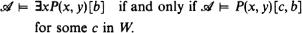

这当且仅当 W 中某个 c 满足 cAb。但这总是成立：每个 b 总有祖先，所以 W 中总存在满足 cAb 的 c。因此 。也就是说，xP(x, y) 在 中为真。

This holds if and only if *cAb* for some *c* in *W*. But this is always so: for each *b* there is always someone who is an ancestor of *b*, and so there always exists *c* in *W* for which *cAb*. Thus . That is, *xP*(*x*, *y*) is true in .

若 Σ 是 PC 的语句集， 是一个解释，且对 Σ 中每个语句 ϕ 都有 ，则称 为 Σ 的模型。

If Σ is a set of sentences of PC and is an interpretation such that for every sentence *ϕ* in Σ, then is said to be a *model* of Σ.

现在的目标是找出能产生所有普遍有效公式的形式系统。也就是提出一些公式作为公理，并给出一条或多条推理规则，使生成的定理包括全部普遍有效公式，而且为保持一致性，只包括这些公式。给定公理和规则后，正式把 PC 中的证明定义为有限公式序列，每个公式要么是公理，要么由序列中较早的公式按推理规则推出。任何证明的最后一行称为定理；若 ϕ 是定理，记为 ϕ。

Now our aim is to find a formal system that produces all the universally valid formulae. That is, we have to suggest some formulae as axioms and one or more rules of inference such that the theorems generated by them are all (and, in order to have consistency, only) the universally valid formulae. Once we have the axioms and rules, we formally define a proof in PC to be a finite sequence of formulae such that each one is either an axiom or inferred from formulae earlier in the sequence by a rule of inference. By a *theorem* we mean the last line of any proof and we write *ϕ* if *ϕ* is a theorem.

我们常希望向给定系统加入额外公理，并在扩大后的系统中构造证明。若 Σ 是这组公理，而 ϕ 可在原谓词演算公理加上 Σ 中语句作为公理所得的系统中证明，就写作 Σ ϕ。

Often we want to add extra axioms to any given system and construct proofs within the larger system. If Σ is the set of axioms, we write Σ *ϕ* if *ϕ* can be proved in the system that we get by adding the sentences in Σ as axioms to the initial predicate calculus axioms.

若不存在公式 ϕ，使 Σ ϕ 和 Σ ϕ 同时成立，就称语句集 Σ 一致。

We say that a set of sentences Σ is consistent if for no formula *ϕ* do we have both Σ *ϕ* and Σ *ϕ*.

换言之，若 Σ + ϕ 不一致，则 Σ ϕ。

In other words, if Σ + *ϕ* is inconsistent, then Σ *ϕ*.

完备性定理：ϕ 可证明，当且仅当 ϕ 普遍有效；换言之， ϕ 当且仅当 ϕ。

COMPLETENESS THEOREM: *ϕ* is provable if and only if *ϕ* is universally valid, in other words *ϕ* if and only if *ϕ*.

对于所选公理，例如本章末列出的那些，逐一检验每个公理普遍有效、推理规则保持普遍有效性，虽然费力但并不困难。因此所有定理都普遍有效，即若 ϕ，则 ϕ。这也表明谓词演算一致：若 ϕ 且 ϕ，就会有 ϕ 且 ϕ，即 ϕ 和 ϕ 都普遍有效，这是不可能的。

Now if we take the axioms (such as those listed at the end of this chapter) it turns out that it is straightforward but laborious to check that each of the axioms is universally valid, and that the rule of inference preserves universal validity. From this we are assured that all the theorems are universally valid. Thus we have that if *ϕ* then *ϕ*. This also shows that the predicate calculus is consistent, for if *ϕ* and *ϕ* then *ϕ* and *ϕ*. Thus both *ϕ* and *ϕ* would be universally valid, which is impossible.

为证明完备性，还需证明：若 ϕ，则 ϕ；等价地，若 ϕ 不是定理，则不普遍有效。也就是说，要证明若 ，则 ϕ 有模型，因为 ϕ 有模型就意味着 ϕ 不普遍有效。由上一定理，若 ，则 {ϕ} 一致。因此只需证明下述定理。

Now in order to prove completeness we need to show that if *ϕ* then *ϕ* or equivalently that if *ϕ* is not a theorem, then *ϕ* is not universally valid. That is, we need to show that if then *ϕ* has a model, because *ϕ* has a model only if *ϕ* is not universally valid. But, the above theorem if then {*ϕ*) is consistent. All we need is to prove the theorem that follows.

### 哥德尔—亨金完备性定理

### **The Gödel–Henkin Completeness Theorem**

若 Σ 是一致的公式集，则存在解释 ，使对 Σ 中所有 ψ 都有 。

If Σ is a consistent set of formulae, then there exists an interpretation such that for all *ψ* in Σ.

因为只需取 Σ 为单个语句 ϕ，就能表明：若 ϕ 一致，则 是 ϕ 的模型。因此 ϕ 在 中为假，故不普遍有效。下面简要勾勒证明，先列出证明各阶段，再详细解释。

For if we then take Σ as just the single sentence *ϕ* we shall have shown that if *ϕ* is consistent then is a model for *ϕ*. This implies that *ϕ* is false in so that *ϕ* is not universally valid. I shall now briefly sketch a proof of this theorem, starting by setting out the stages in the proof, which I shall then explain in more detail.

1. 从理论 Σ 开始。2. 向语言加入个体常元 b₁、b₂、……，称为“见证”；检查加入后理论是否仍一致。3. 列出以 v₁ 为自由变量的全部公式 ψ₀(v₁)、ψ₁(v₁)、……。

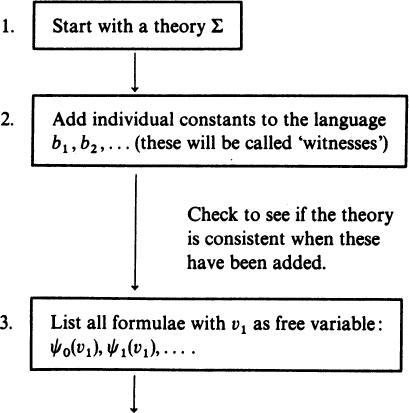

4. 对第 3 阶段列出的每个公式，选适当见证 b，加入形如 ∃v₁ψ(v₁) → ψ(b) 的新公理；再次检查一致性。5. 应用林登鲍姆引理，得到扩大的语句集 Σ*，使语言中每个语句 ψ 都满足 Σ* ⊢ ψ 或 Σ* ⊢ ¬ψ。6. 为扩大的语句集 Σ* 定义解释 𝒜。7. 验证 𝒜 ⊨ ψ 当且仅当 Σ* ⊢ ψ。8. 因为 Σ 包含于 Σ*，所以对 Σ 中每个 ψ 都有 𝒜 ⊨ ψ，故 𝒜 就是所需模型。

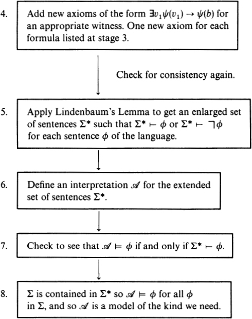

继续之前，先说明林登鲍姆引理。若一致语句集 Σ 对语言中每个语句 ϕ 都满足 Σ ϕ 或 Σ ϕ，就称 Σ 为完全的。林登鲍姆引理断言：

Before I go on, I should explain Lindenbaum’s Lemma. A consistent set of sentences Σ is said to be *full* if for each sentence *ϕ* of the language either Σ *ϕ* or Σ *ϕ*. Then Lindenbaum’s Lemma states:

若 Σ 一致，则存在 Σ 的一个完全且一致的扩张 Σ*，即对语言中任意 ϕ，都有 Σ* ϕ 或 Σ* ϕ，但二者不能同时成立。

If Σ is consistent, then there exists a full consistent extension Σ* of Σ, that is, for any *ϕ* in the language either Σ* *ϕ* or Σ* *ϕ*, but not both.

证明如下：列出 PC 的全部语句 ϕ₁、ϕ₂、……，逐步构造 Σ*。按下述方式定义语句集序列 Σ₀、Σ₁、Σ₂、……。令 Σ₀ = Σ，再取

The proof goes like this: list all the sentences *ϕ*<sub>1</sub>, *ϕ*<sub>2</sub>,… of PC. We shall build up step by step to Σ*. Define a sequence Σ<sub>0</sub>, Σ<sub>1</sub>, Σ<sub>2</sub>,… of sets of sentences in the following way. Put Σ<sub>0</sub> = Σ. Take

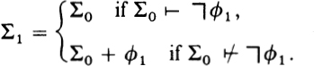

也就是说，若向 Σ₀ 加入 ϕ₁ 后仍一致，就加入它得到 Σ₁；否则保持 Σ₁ = Σ₀。事实上，对 ϕ₁、ϕ₂、ϕ₃、……依次如此操作，于是

(Thus, if *ϕ*<sub>1</sub> can be added to Σ<sub>0</sub> so that the new set is still consistent, then add it to get Σ<sub>1</sub>; if not, leave Σ<sub>1</sub> = Σ<sub>0</sub>.) And in fact do this successively with *ϕ*<sub>1</sub>, *ϕ*<sub>2</sub>, *ϕ*<sub>3</sub>,…. So

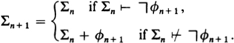

每个 Σₙ 都一致，因为从一致集合出发，每次加入时都小心保持一致性。

Now each Σ*<sub>n</sub>* is consistent, because we started with a consistent set and were careful to preserve consistency at each addition.

对 PC 语句列表中的每个公式，视情况加入或不加入后，所得集合记为 Σ*。Σ* 一致，因为所有证明长度有限；若能证明 Σ* 不一致，就意味着某个 Σₙ 不一致。但构造已保证每个 Σₙ 一致，所以不可能。

Let Σ* be what we get after we have added, or not added as the case may be, each formula in our list of sentences of PC. Σ* will be consistent because, as all proofs are finite in length, a proof of inconsistency in Σ* will mean that one of the Σ*<sub>n</sub>* is inconsistent. But this is impossible because we have guaranteed by the construction that each of the Σ*<sub>n</sub>* is consistent.

语言的所有语句都在 ϕ₁、ϕ₂、……中，每个阶段 n 都决定是否向 Σₙ 加入 ϕₙ。只有已能从该集合证明 ϕₙ 时才不加入。因此，对所有公式 ϕ，ϕ 或 ϕ 都可由 Σ* 证明；事实上，ϕ 或 ϕ 本身就在 Σ* 中。因此 Σ* 是完全且一致的集合，正如林登鲍姆引理所断言。

Also all sentences of the language are in the list *ϕ*<sub>1</sub>, *ϕ*<sub>2</sub>,… and at each stage *n* we determined whether or not to add *ϕ<sub>n</sub>* to the Σ*<sub>n</sub>*. Only when *ϕ<sub>n</sub>* was already provable from this set did we not add it. So for all formulae *ϕ* either *ϕ* or *ϕ* can be proved from Σ* and, in fact, either *ϕ* or *ϕ* is in Σ*. Thus Σ* is a full consistent set, as was asserted to exist in Lindenbaum’s Lemma.

现在补充主要证明各阶段的一些细节：

Now we can fill in some of the details in the stages of the main proof:

[output not shown]

最后指出，实际证明的比原目标更多。由于 bᵢ 构成可数集，我们已经证明 Σ 有可数模型。下一章将进一步讨论。

We finally remark that we have in fact shown more than we set out to do. We have shown that Σ has a *countable* *model*, since the *b<sub>i</sub>* form a countable set. More will be made of this in the next chapter.

### 附录

### **Appendix**

#### 谓词演算的公理与推理规则

#### **Axioms and rule of inference for predicate calculus**

下面给出有限个公理模式。（使用代入规则也可以只用有限条公理，但为简化本章内容，我们没有这样做。）

We give a finite number of schemes for axioms. (We could make do with a finite number of axioms by using a substitution rule, but in order to simplify the contents of this chapter we have chosen not to.)

公理是具有下列形式的全部公式，其中 ϕ、ψ、χ 是公式，x、y、y₁、……、yₙ、……是变量，ϕ(y) 是把 ϕ(x) 中 x 的所有自由出现替换为 y 所得的结果。

The axioms are all formulae of the following forms, where *ϕ*, *ψ*, *χ* are formulae, *x*, *y*, *y*<sub>1</sub>, …, *y<sub>n</sub>*,… are variables, and *ϕ*(*y*) is the result of replacing all free occurrences of *x* in *ϕ*(*x*) by *y*.

∀y₁ … ∀yₙ(ϕ → (ψ → ϕ))。

∀*y*<sub>1</sub> … ∀*y<sub>n</sub>*(*ϕ* → (*ψ* → *ϕ*)).

∀y₁ … ∀yₙ((ϕ → (ψ → χ)) → ((ϕ → ψ) → (ϕ → χ)))。

∀*y*<sub>1 …</sub> ∀*y<sub>n</sub>*((*ϕ* → (*ψ* → *χ*)) → ((*ϕ* → *ψ*) → (*ϕ* → *χ*))).

∀y₁ … ∀yₙ((ϕ → ψ) → ((ϕ → ψ) → ϕ)))。

∀*y*<sub>1</sub> … ∀*y<sub>n</sub>*((*ϕ* → *ψ*) → ((*ϕ* → *ψ*) → *ϕ*))).

∀y₁ … ∀yₙ(∀x(ϕ → ψ) → (ϕ → ∀xψ))，条件是 ϕ 中没有 x 的自由出现。

∀*y*<sub>1</sub> … ∀*y<sub>n</sub>*(∀*x*(*ϕ* → *ψ*) → (*ϕ* → ∀*x**ψ*)) provided *ϕ* has no free occurrence of *x*.

∀y₁ … ∀yₙ((ϕ → ψ) → (∀y₁ … ∀yₙϕ → ∀y₁ … ∀yₙψ))。

∀*y*<sub>1</sub> … ∀*<sub>yn</sub>* ((*ϕ* → *ψ*) → (∀*y*<sub>1</sub> … ∀*y<sub>n</sub>ϕ* → ∀*y*<sub>1</sub> … ∀*y<sub>n</sub>ψ*)).

∀y₁ … ∀yₙ(∀xϕ(x) → ϕ(y))，条件是：用 y 替换 ϕ(x) 中 x 的自由出现时，这些 y 在 ϕ(y) 中仍自由，即不受 ϕ 中已有的 y 量词管辖。

∀*y*1 … ∀*y<sub>n</sub>*(∀*xϕ*(*x*) → *ϕ*(*y*)), provided that when *y* is substituted for free occurrences of *x* in *ϕ*(*x*) the *y*’s are free in *ϕ*(*y*) (that is, they are not governed by *y* quantifiers already occurring in *ϕ*).

推理规则是分离规则：由 ϕ、(ϕ → ψ) 推出 ψ。

The rule of inference is *modus* *ponens*: from *ϕ*, (*ϕ* → *ψ*) infer *ψ*.

## 3. 模型论

## 3. **Model Theory**

本章讨论模型论，涉及三个方面：首先是带等词的谓词演算，简称 PC(=)；其次是紧致性定理；最后是勒文海姆—斯科伦定理。模型论研究语言与世界的关系，更精确地说，是形式语言与其解释之间的关系。我假定你知道形式语言是什么，但在开始 PC(=) 之前，还要多谈一点解释。

IN this chapter I am going to discuss Model Theory, and in doing so I shall be concerned with three separate things. Firstly I want to discuss Predicate Calculus with Identity, which I shall abbreviate as PC( = ). Secondly I shall consider the Compactness Theorem and thirdly I shall discuss the Löwen-heim-Skolem Theorems. Model Theory is the study of the relations between languages and the world, or more precisely between formal languages and the interpretations of formal languages. I assume you know what formal languages are but I shall talk a little more about interpretations before I start on PC(=).

先看一个英语语句，考察要将它形式化，需要哪些谓词符号、名称、联结词和量词。考虑：

We shall begin by looking at an English sentence and try to find what we need in the way of predicate symbols, names, connectives, and quantifiers in order to formalize it. Consider the sentence:

(i) 如果老板负责，而乔就是老板，那么乔负责。

(i) If the boss is in charge and Joe is the boss, then Joe is in charge.

为形式化 (i)，取谓词语言 ℒ。除通常的命题演算机制和量词外，ℒ 还包含一元谓词字母 P，解释为“负责”；二元谓词字母 E，解释为“与……相同”；两个常元字母 j、b，分别表示“乔”和“老板”。还需要命题演算联结词 &、→，分别表示“且”和“蕴涵”。于是 (i) 可以形式化为

To formalize (i) I am going to take the predicate language . if has, in addition to the usual sort of machinery of propositional calculus plus quantifiers, a one-place predicate letter *P* to be interpreted as ‘is in charge’, a two**-**place predicate letter *E*, interpreted as ‘is the same as’ and two constant letters; and *b,* for ‘Joe’ and ‘the boss’ respectively. We shall also need in this case just two of the usual propositional calculus connectives, & and → for ‘and’ and ‘implies’; then (i) can be formalized as

谓词字母 E 称为等同谓词，带有 E 的谓词演算称为带等词的谓词演算。因此 (ii) 是 PC(=) 中的语句。

The predicate letter *E* is called the identity predicate and predicate calculus with *E* is called predicate calculus with identity. So (ii) is a sentence in PC( = ).

考虑结构 𝒜 = ⟨A, R, a₁, a₂, S⟩，其中 A 为非空集，R 是性质，S 是 A 上的关系，a₁、a₂ 是 A 的成员。记住，集合上的性质就是它的子集，关系就是由该集合元素构成的有序对的集合。稍后会规定 S 为 A 上的等同关系，即有序对的第一分量与第二分量相同，且 A 的每个成员都出现在某个这样的对中，也就是 S = {(x,x):x∈A}。𝒜 可以解释 (ii)：把 j 解释为 a₁，b 解释为 a₂，E 解释为 S，P 解释为 R，详见第 2 章。为简单起见，设 A 只有 a₁、a₂ 两个成员。若 S 是 A 上的等同关系，(ii) 就是说：若 a₂ 有性质 R，且 a₁、a₂ 相同，则 a₁ 有性质 R。这在 𝒜 中显然为真。二元谓词 E 不一定非要解释为等同关系；但若这样解释，而这总是可能的，就称该解释为正规的。因此，语言 ℒ 的正规解释，就是把二元谓词 E 解释为等同关系的解释。显然 (ii) 在每个正规解释中都为真，但在其他解释中未必。下列公式在每个正规解释中也为真：

Now consider the structure = 〈*A*, *R*, *a***<sub>1,</sub>***a*<sub>2</sub>, S〉 where *A* is a non-empty set, *R* is a property, *S* is a relation on *A*, and *a*, and *a*, are members of *A*. Remember that a property on a set is just a subset of that set and a relation on a set is a set of ordered pairs whose members come from that set. We are later going to say that *S* is the identity relation on *A*, so *S* will be the set of ordered pairs such that the first member of an ordered pair is the same as that pair’s second member, and each member of *A* will be a member of some pair in *S;* that is, *S* = {*x*, *x*〉:*x* ∈ *A*}. Now is a structure in which it is possible to interpret (ii). That means we can let *j* be interpreted as *a*<sub>1</sub> *b* as *a*<sub>2</sub>, *E* as 5, and *P* as *R* (for the details, see Chapter 2). We now consider this interpretation and for simplicity we shall take *A* to be the set with just *a*<sub>1</sub>and *a*<sub>2</sub> as members. Then if *S* is the identity relation on *A,* what (ii) says is that if *a<sub>2</sub>* has the property *R* and if *a<sub>1</sub>* and *a<sub>2</sub>* are *the same* then *a*<sub>1</sub> has the property *R*; which is clearly true in . Now it is not necessary to interpret the two-place predicate letter, *E*, as the identity relation, but if we do, and this is always possible, we say that the interpretation is normal. Thus a *normal* interpretation for a language is one for which the interpretation of the two-place predicate, *E,* is the identity relation. Clearly (ii) is true in every normal interpretation, but not necessarily true in other interpretations. The following are also true in every normal interpretation:

(iii) ∀xE(x, x)，

(iii) **∀***x*E(*x*, *x*),

(iv) ∀x∀y(E(x, y) → E(y, x))，

(iv) **∀***x* **∀***y*(*E*(*x*, *y*) → *E*(*y*, *x*)),

(v) ∀x∀y∀z(E(x, y) & E(y, z) → E(x, z))，

(vi) 对 ℒ 的任意公式 φ，∀x∀y(E(x, y) → (φ(x, x) → φ(x, y)))。

(vi) For any formula *φ* of , **∀***x* **∀***y*(*E*(*x*, *y*) - (*φ*(*x*, *x*) → *φ*(*x*, *y*))).

(iii) 表示 E 自反，(iv) 表示对称，(v) 表示传递，(vi) 是莱布尼茨律。(iii)、(iv)、(v)、(vi) 称为等词公理。

(iii) says that *E* is reflexive, (iv) that it is symmetric, (v) that it is transitive and (vi) is Leibnitz’ Law. (iii), (iv), (v) and (vi) ) are called the *axioms for equality*.

现在断言：ℒ 的公式 φ 在每个正规解释中为真，当且仅当 φ 可由逻辑公理和等词公理证明。分别用 {Logical} 和 {Equality} 表示逻辑公理集与等词公理集，我们断言：

I now claim that a formula *φ* of is true in every normal interpretation if and only if *φ* is provable from the logical axioms together with the axioms for equality. Now writing {Logical} and {Equality} for the sets of the logical and equality axioms respectively, we claim that

{Logical} + {Equality} ⊢ φ，当且仅当对所有正规模型 𝒜 都有 𝒜 ⊨ φ，其中 φ 是 ℒ 的公式。这就是说，ℒ 连同其公理相对于正规解释是完备的。

{Logical} + {Equality} *φ* if and only if *φ* for all normal models , where *φ* is a formula of . This is just the claim that together with its axioms is complete with respect to its normal interpretations.

由于 {Logical} + {Equality} 中的语句在 ℒ 的所有正规解释中为真，而且推理规则在任意解释中都只会从真公式推出真公式，所以若 {Logical} + {Equality} ⊢ φ，则对所有正规解释 𝒜 都有 𝒜 ⊨ φ。现在证明反方向，将使用哥德尔—亨金完备性定理。假设 {Logical} + {Equality} ⊬ φ，则 {Logical} + {Equality} + {¬φ} 一致，故有模型。为证明上述断言，需要给出 ¬φ 的正规模型。这样就说明 φ 并非在所有正规模型中为真，从而得到：若 φ 在所有正规模型中为真，就可由 {Logical} + {Equality} 证明。

Now because the sentences of {Logical} + {Equality} are true in all normal interpretations of , and because the rules of inference yield, for any interpretation, only true formulae from true formulae, we know that if {Logical} + {Equality} *φ*, then *φ* for all normal interpretations . Now we want to show that if *φ* is true in all normal models, then {Logical} + {Equality} *φ*. We shall use the Gödel-Henkin completeness theorem in proving this. So suppose {Logical} + {Equality} *φ*. Then {Logical} + {Equality} + {*φ*} is consistent and so by the Gödel-Henkin theorem this set of sentences will have a model. In order to prove my claim I have to give a normal model for *φ*. This will show that *φ* is not true in all normal models, thus showing that if *φ* is true in all normal models, then *φ* is provable from {Logical} + {Equality}.

下面概述：对包含 {Equality} 的语句集，只要它有模型，就总能得到正规模型。设集合 A 的成员为 x、y、z、……，A 上有自反、对称、传递且满足 (vi) 的关系 S。S 不一定是相等关系，例如在人构成的论域上，若语言没有其他谓词符号，“同龄”关系就满足这些条件。同龄不意味着同一个人，但它自反、对称、传递，且满足莱布尼茨律，因为只含 E 的公式，其解释显然只依赖所涉及人的年龄。按 S 把 A 分成若干子集：x、y 同属一类，当且仅当 xSy。由等词公理，每个元素与本类全部元素有关系 S，与其他类元素无此关系。每类选一个代表，这些代表构成原语句集的正规模型，所有语句在其中仍为真。代表集是原模型的子集，对新模型中任意 u、v，uSv 当且仅当 u = v，所以 E 可以解释为等同关系。因此，在带二元谓词 E 的语言中，任何包含等词公理的语句集，只要有模型，就有正规模型。于是 {Logical} + {Equality} + {¬φ} 有正规模型，φ 并非在所有正规模型中为真。因此，若对所有正规模型 𝒜 都有 𝒜 ⊨ φ，就有 {Logical} + {Equality} ⊢ φ。断言得证。

I am now going to outline how one can always get a normal model for a set *of* sentences including {Equality} given that the set has a model at all. Consider a set *A* with members *x*,.*y*, *z*, … and let there be a relation *S* defined on *A* which is reflexive, symmetric, and transitive and such that (vi) holds. (This relation is not necessarily equality, for consider the relation ‘same age as’ and the domain of people as the interpretation for a language where there are no other predicate symbols. That two people are the same age does not imply that they are the same person. Yet this relation is reflexive, symmetric, and transitive and Leibnitz’ Law holds of it, since the interpretation of a formula involving only the symbol *E* can clearly depend only on the ages of the people involved.) Now divide *A* up into subsets according to whether the elements are in the relation *S* to each other or not: x and *y* belong to the same subset if and only if *xSy*. We can see that any element bears the relation *S* to every other element in its subset and to no other from the fact that the axioms for equality hold. Now let us choose a representative from each subset. These representatives will form a normal model for the original set of sentences. All the sentences will be true of them and as the representatives are themselves a subset of the original model, for any two elements in the new model *u* and *v* *uSv* if and only if *u* = *v* So *E* can be interpreted as identity in this new model. This shows that for any set of sentences, in a language with the two-place predicate letter *E*, and which contains the axioms for equality, if the set has a model, then we can always find a normal model for it. Thus because {Logical} + {Equality) + {*φ*} has a model, it has a normal models. So *φ* is not true in every normal model. Thus if *φ* for all normal models , then {Logical} + {Equality} *φ*. This proves my claim.

模型论通常关注特定解释。下面这个解释尤为重要。考虑结构 𝒩 = ⟨N, <⟩，其中 N 是自然数 0、1、2、3、4、……的集合，< 是“小于”关系。（严格说应写 ⟨N, <, =⟩，但从现在起，假定每个解释都以等同关系解释等号；谈可证明性与一致性时，也都指相对于 {Logical} + {Equality} 而言。）

In Model Theory we are usually interested in particular interpretations. One that I am going to give now is of particular importance as you will soon see. I want to look at the structure where *N* is the set of natural numbers, 0, 1, 2, 3, 4, … etc. and < is the relation ‘less than’. (I should write 〈N, <, =〉 but in all cases from now on I assume that each interpretation has the identity relation to interpret the equality symbol. I shall also mean, when talking about provability and consistency, provability from and consistency with {Logical} + {Equality}.)

前述语言 ℒ 的哪些语句在这个解释中为真？例如：

Which sentences of the language that we talked about before are true in this interpretation? Some are:

(viii) ∀x(¬P(x, x))，

(viii) **∀***x*(*P*(*x*, *x*)),

(ix) ∀x∀y(¬(P(x, y) & P(y, x)))，

(ix) **∀***x* **∀***y*( (*P*(*x*, *y*) **&** *P*(*y*, *x*))),

(x) ∀x∀y∀z(P(x, y) & P(y, z) → P(x, z))，

(x) **∀***x* **∀***y* **∀***z* (*P*(*x*, *y*) **&** *P*(*y*, *z*) → *P*(*x*, *z*)),

(xi) ∀x∀y(P(x, y) ∨ P(y, x) ∨ E(x, y))，

(xi) **∀***x* **∀***y* (*P*(*x*, *y*) *P*(*y*, *x*) *E*(*x*, *y*)),

(xii) ∃x∀y(¬P(y, x))，

(xii) *x* **∀***y*(*P*(*y*, *x*)),

(xiii) ∀x∃y(P(x, y) & ∀z¬(P(x, z) & P(z, y)))，

(xiii) **∀***x* *y* (P(*x*, *y*) **&** **∀***z* ( *P*(*x*, *z*) **&** *P*(*z*, *y*))),

(xiv) ∀x(∃yP(y, x) → ∃y(P(y, x) & ∀z¬(P(y, z) & P(z, x)))))。

(xiv) **∀***x* (*y* *P*(*y*, *x*) → *y* (*P*(*y*, *x*) **&** **∀***z* ((*Ρ*(*x*, *z*) **&** *P*(*z*, *y*))))).

以后经常引用这些语句，因此用 Σ 表示它们构成的集合，即 Σ = {(viii), …, (xiv)}。

I am going to refer to these sentences often from now on, so I shall use **Σ** to refer to the collection of them: **Σ** is the set {(viii),…, (xiv)}.

(viii)、(ix)、(x)、(xi) 正是所有有序集中成立的性质：若 P 给一组对象排序，则 P 非自反、非对称、传递，且任意两个不相等对象都可比较，P 在其中一个方向成立。(xii) 说解释有首元素；(xiii) 说每个对象都有紧邻其后的更大对象，即后继；(xiv) 说除首元素外，每个元素都有紧邻其前的较小对象，即前驱。考察各语句的含义，便能看出它们在 𝒩 = ⟨N, <⟩ 中都为真。

Now (viii), (ix), (x), (xi) are just the things that are true in all ordered sets. That is if *P* is a relation that orders a set of objects then *P* is irreflexive (viii), *P* is asymmetric (ix), *P* is transitive (x), and if any two objects are not equal then they are comparable and the relation *P* holds one way between them (xi). (xii) says that our interpretation has a first element and (xiii) says that for each object there is always another that is next biggest in terms of our ordering relation. That is, each element has a successor. Finally (xiv) says that every element except the first has a next smallest. That is, all elements but the first have predecessors. All these sentences are true in as you can see by looking at them and considering what they say.

现在陈述一个关于 Σ 的结果，说明它对 𝒩 的重要性：Σ 完全公理化了 𝒩。更精确地说：

引理：若 𝒜 是 Σ 的任意模型，则在 𝒜 中为真的语句，恰好与在 𝒩 中为真的语句相同。

LEMMA. If is any model for **Σ** then the same sentences are true in as are true in .

这个引理可用相当技术性的模型论证明。由此得到推论：𝒩 ⊨ ψ 当且仅当 Σ ⊢ ψ。假设 Σ ⊬ ψ，则 Σ + {¬ψ} 一致，依哥德尔—亨金定理有模型 ℳ。因此 ℳ ⊨ ¬ψ，由引理可得 𝒩 ⊨ ¬ψ。所以若 𝒩 ⊨ ψ，必有 Σ ⊢ ψ。反过来，Σ 中语句都在 𝒩 中为真，而唯一使用的推理规则保持解释中的真，因此 Σ ⊢ ψ 蕴涵 𝒩 ⊨ ψ。既然一个语句在 𝒩 中为真当且仅当可从 Σ 证明，我们实际上公理化了 𝒩 的全部真语句：它们都可由逻辑公理、等词公理及 Σ 证明。

This lemma can be proved by some rather technical model theory, and from it we can deduce the corollary that if and only if **Σ** *ψ*. For suppose **Σ** *ψ*. Then **Σ** + {*ψ*} is consistent. Therefore by the Gödel-Henkin theorem it has a model, say . Thus , and by the lemma we conclude . Thus we conclude **Σ** *ψ*. We had above that the sentences in **Σ** are all true in and as the only rule of inference we are using preserves truth in an interpretation, we also have that if **Σ** *ψ* then Because of the fact that if (and only if) a sentence is true in we can prove it from the set of sentences **Σ**, what we have in fact done is axiomatize the set the set of sentences true in . That is, all sentences that are true in can be proved from the logical axioms and the axioms of equality plus **Σ**.

现在问：Σ 在多大程度上确定了 𝒩 本身？换句话说，已知某个解释满足 Σ 中的语句，距离知道它就是 𝒩 还有多远？首先，𝒩 不是 Σ 的唯一模型。𝒩 是 ⟨{0,1,2,3,…}, <⟩。很容易得到与它同构、因而也是 Σ 模型的结构：只需保证有首元素，每个元素有后继，除首元素外都有前驱，关系非自反、非对称、传递，且元素彼此可比较。最初没有理由非从 0 开始，因此取 ℳ = ⟨{1,2,3,…}, <⟩，令 M = {1,2,3,…}。在下列对应下，ℳ 显然与 𝒩 同构：

I am going to ask the question: to what extent does **Σ** determine itself? Another way to put this question is to ask: given that we know the sentences of **Σ** are satisfied in an interpretation, how close are we to knowing that the interpretation is ? First I want to say that is not the only model for **Σ**. Remember that is the structure 〈{0, 1, 2, 3, …}, <〉. It is easy to get another structure that is isomorphic to , that is, has the same structure as , and such that it will be a model for **Σ**. All we have to do is guarantee that we have a first element, that every element has a successor, and all but the first has a predecessor, etc., and that the relation of the structure is irreflexive, asymmetric, and transitive and that the members of the set are connected (xi above). Now there was no reason for starting off with the natural number 0 when giving . So let us consider a new structure = 〈{1, 2, 3, ...}, <〉 and put *M* ={1, 2, 3, …}. is clearly isomorphic to under the correspondence

也就是把 𝒩 的集合 N 中每个 x 对应于 ℳ 的集合 M 中的 x + 1，两个集合的全部成员都被用到。因此 𝒩 与 ℳ 是 Σ 的同构模型。若能证明 Σ 的所有模型都与 𝒩 同构，就取得了很大成果，可以说 Σ 在许多重要方面确实确定了 𝒩。因为同构模型只在元素的本性上不同，结构相同：一个模型中的性质和关系，与另一个模型中对应元素的性质和关系相对应。两个同构模型之间的数学或逻辑差别只是无关紧要的。

That is, we make any member *x* of the set *N* in correspond to the member *x* + 1 of the set M in and in doing so use up all the members of each set. Thus and are isomorphic models for **Σ**. Now if we could prove that all the models for **Σ** were isomorphic to , then we would have achieved a great deal and we could say that in many important respects **Σ** did determine . This is so because isomorphic models differ only in the nature of their elements—the structure in each is the same. That is, the properties and relations that hold in one of two isomorphic models correspond to the properties and relations that hold between the corresponding elements of the other. The difference between two isomorphic models is only in a trivial sense a mathematical or logical one.

遗憾的是，Σ 还有不与 𝒩 同构的模型。先把 N 的成员沿直线画出：

But alas, there is also a model for **Σ** that is not isomorphic to . To see this, firstly draw the members of the set *N* out along a straight line:

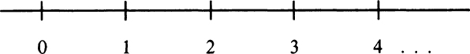

在 0 与 1 之间标出 ，即 {1 − 1/n:n∈N,n>0} 中的点；在 1 与 2 之间标出 ，即 {1 + 1/n:n∈N,n>1} 中的点；在 2 与 3 之间重复 0 与 1 之间的做法，标出 {3 − 1/n:n∈N,n>0} 中的点。于是得到如下直线：

Now between 0 and 1 we mark the points , that is, we mark in the points that correspond to the members of the set {1 – 1/*n*: *n* ∈ *N*, *n* > 0}. Next between 1 and 2 we mark in the points corresponding to the fractions . That is, we mark in the members of the set {1 + 1/*n*: *n* ∈ *N*, *n* > 1}. Then between 2 and 3 we do what we did for 0 and 1. We mark in the points corresponding to the members of the set {3 – 1/*n*: *n* ∈ *N, n* > 0}. So we get a line that looks like:

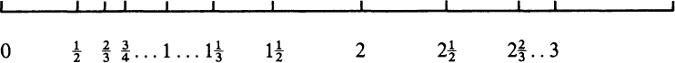

取 0 与 3 之间所有这些点构成的集合，包含 0，但不包含 1 和 3，即

We then consider the set which has as its members all these points between 0 and 3, including 0 but excluding 1 and 3. This will be the set

现在断言，ℬ = ⟨B, <⟩ 是 Σ 的模型，但不与 𝒩 同构。

Now I claim that = 〈B, <〉 is a model for **Σ**, and that it is not isomorphic to .

为什么 ℬ 是 Σ 的模型？逐一检查可知，Σ 的每个语句在 ℬ 中为真。没有数小于自身，所以 ∀x¬(x<x) 为真；没有数既小于又大于另一个数，所以 (ix) 为真；< 在 B 上传递，任意两个不同元素可比较，所以 (x)、(xi) 为真；0 是首元素，所以 (xii) 为真；每个元素有后继，除 0 外都有直接前驱，所以 (xiii)、(xiv) 为真。因此 ℬ 是 Σ 的模型。但 ℬ 与 𝒩 的结构显然不同：ℬ 中的 1½ 前面有无限多个元素，而 N 中没有任何元素具有这一性质，所以 N 中不可能有与它对应的元素，二者不可能同构。因此，Σ 不仅有模型 𝒩，还有与它同构的模型及不与它同构的模型。这表明 Σ 无法告诉我们关于 𝒩 的很多事情。仅知道某结构满足 Σ，不能断定其中元素是自然数，甚至不能断定它们在所有方面都像自然数。Σ 既不能确定对象是什么，也不能涵盖它们的一切结构关系。唯一知道的是，形式语言中每个在 𝒩 中为真的语句，都能由 Σ 加逻辑公理和等词公理证明。

Why is a model for **Σ**? Each of the sentences of **Σ** is true in as you can see by inspection. None of these numbers is smaller than itself, so **∀***x* (*x* < *x*) is true. No number is both smaller than and greater than another, so (ix) is true. Also < is transitive over *B* and any two elements of *B* are related, so (x) and (xi) are true in . 0 is a first element, so (xii) is true and each element has a successor and all but zero has an immediate predecessor, so (xiii) and (xiv) are true. Thus all of the sentences in **Σ** are true and is therefore a model for **Σ**. But clearly and possess different structures. There can be no element of *N* corresponding to in the structure , since this has infinitely many elements before it and no element of *N* has this property. So the structures cannot be isomorphic. We conclude that not only does **Σ** have as a model, it has other models isomorphic to and yet other models not isomorphic to . SO from the last result we know that **Σ** cannot tell us very much about . If all we are told is that we have a structure and that the sentences in **Σ** are true in this structure, then we cannot say whether the elements in it are the natural numbers, or even behave like the natural numbers in *all* respects. **Σ** neither determines what objects we have nor encompasses all the structural relations into which they enter. The only thing we do know is that we can prove from **Σ** plus the logical and equality axioms any sentence of our formal language which is true in .

暂时说到这里，转向另一个问题。下面介绍紧致性定理及其含义，不过先证明一个引理。

I want to stop here for the moment and turn to another thing. I am now going to tell you what the Compactness Theorem is and what it says. But before I do, I shall have to prove a lemma.

引理：若 Σ 不一致，则 Σ 的某个有限子集不一致。

LEMMA. If **Σ** is inconsistent, then some finite subset of **Σ** is inconsistent.

若 Σ 不一致，按定义，对某公式 φ 同时有 Σ ⊢ φ 和 Σ ⊢ ¬φ，即 Σ ⊢ φ & ¬φ。因此存在有限公式串 φ₁、φ₂、……、φₙ，其中 φₙ = φ & ¬φ，且每个 φᵢ 满足以下条件之一：

If **Σ** is inconsistent, then by definition we have that for some formula *φ* both **Σ** h *φ* and **Σ** *φ*, or in other words, **Σ** *φ* **&** *φ*. That is, there is a finite string of formulae *φ*<sub>1</sub>, *φ*<sub>2</sub>, …, *φ<sub>n</sub>* where *φ<sub>n</sub>* = *φ* **&** *φ* and where for each *φ<sub>ί</sub>* either

| (i) (i) | φᵢ 是逻辑公理或等词公理；或 *φ<sub>ί</sub>* is a logical or equality axiom, or |
| --- | --- |
| (ii) (ii) | φᵢ 是 Σ 的成员；或 *φ<sub>i</sub>* is a member of **∑**, or |
| (iii) (iii) | φᵢ 由列表中位于它之前的两个公式，按推理规则推出。 *φ<sub>i</sub>* follows by the rule of inference from two formulae in the list before *φ<sub>i</sub>*. |

列表有限，因此其中属于 Σ 的公式也只有有限多个。故若 Σ 不一致，就存在 Σ 的有限子集不一致。

Because the list is finite, the number of formulae in it that are members of **Σ** will be finite. So we conclude that if **Σ** is inconsistent, then there is a finite subset of **Σ** that is inconsistent.

上一章证明的哥德尔—亨金定理告诉我们，若 Σ 一致，即使它无限，也有模型。现在用刚才的引理和该定理证明紧致性定理。

Now from the Gödel-Henkin theorem that was proved in the last chapter, we know that if **Σ** is consistent (and **Σ** may be infinite) then **Σ** has a model. So now I want to prove, using the lemma I just proved and the Gödel-Henkin theorem, the Compactness Theorem.

紧致性定理：若 Σ 的每个有限子集都有模型，则 Σ 有模型。

THE COMPACTNESS THEOREM. If every finite subset of **Σ** has a model then **Σ** has a model.

设可能无限的语句集 Σ 的每个有限子集都有模型，则每个有限子集都一致。由引理，Σ 必一致。再由哥德尔—亨金定理，Σ 有模型。

Assume that every finite subset of a possibly infinite set of sentences **Σ** has a model. Then we know that every finite subset of **Σ** is consistent. But then by the lemma **Σ** must be consistent. So by the Gödel-Henkin theorem **Σ** has a model.

下面举一个无限语句集的例子，其每个有限子集都有模型。由紧致性定理可推得，整个集合也有模型。

As an example of this I am going to show you a set of sentences that is infinite and which is such that every finite subset has a model. Thus by the Compactness Theorem we shall deduce that the set itself has a model.

回想前面的语言 ℒ，它是带等词的谓词演算，再加一个谓词字母，结构 ⟨N, <⟩ 是它的解释。现在考虑扩张语言 ℒ⁺，即向 ℒ 添加一个常元字母 c。为了解某些语句对 ℒ⁺ 模型的要求，取 Σ 中的语句，再加上下列语句：

Think of the language that I discussed earlier. It was the predicate calculus with identity with one additional predicate letter. I said that the structure 〈*N*, <〉 was an interpretation for . I now want to consider an extension of the language , I shall call it *<sup>+</sup>*. *<sup>+</sup>* is to be the language with an additional constant letter *c*. Also I want to consider a particular collection of sentences of <sup>+</sup> in order to see what this collection of sentences says about the models of <sup>+</sup>. The sentences are those in **Σ** together with

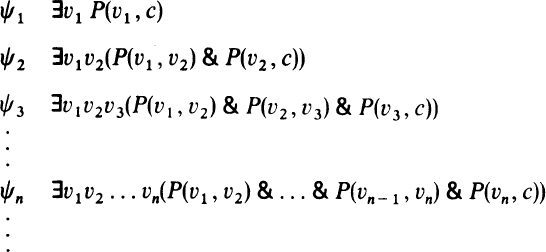

设 Σ* 为所有这些语句的集合，即 Σ 中语句加上所有 n ≥ 1 的 ψₙ。取其有限子集 Σ′，考虑结构 ⟨A, R, a⟩，其中 a∈A，说明其中某些结构是 Σ′ 的模型。若对每个有限子集都能构造模型，紧致性定理就保证 Σ* 本身有模型。

Now suppose that **Σ*** is the collection of all those sentences. That is, **Σ*** is the set of sentences in **Σ** together with all the sentences *ψ<sub>n</sub>* for . Suppose that **Σ**′ is a finite subset of **Σ**. I am going to consider a collection of structures 〈*A*, *R*, *a*〉 where a is an element of *A* and I am going to show how some of these can be models for **Σ**′. If I produce a model for each **Σ**′ I shall have produced a model for each finite subset of **Σ*** and thus, using the compactness theorem, shall have shown that **Σ*** itself has a model.

先规定 ⟨A, R, a⟩ 中的 A、R 分别为 𝒩 = ⟨N, <⟩ 中的 N、<，于是 ⟨A, R⟩ 是 Σ 的模型。有限子集 Σ′ 只涉及 Σ 的一些语句和有限多个 ψ。设 k 是其中出现的 ψₙ 的最大下标，则 ⟨N, <, k⟩ 是 Σ′ 的模型。Σ 中语句本来就在 ⟨N, <⟩ 中为真，因此仍为真；若 n ≤ k，则 ⟨N, <, k⟩ ⊨ ψₙ。例如 ψ₁ 说有某物小于 c，把 c 解释为 1 就成立；ψ₂ 说存在两个对象，第一个小于第二个，第二个小于 c，把 c 解释为 2 就成立，依此类推。每个有限子集都有最大的下标，所以只需 k 至少等于该最大下标，就得到模型。因此由紧致性定理，Σ* 有模型。

I first stipulate that the *A* and the *R* of 〈*A*, *R*, *a*〉 are to be *N* and < of my structure . Thus 〈*A*, *R*〉 is a model for **Σ**. Secondly, consider a finite subset **Σ**′ of **Σ***. **Σ**′ will involve some of the sentences in **Σ** and only finitely many of the *ψ*’s. Let *k* be the largest *n* such that *φ<sub>n</sub>* ∈ **Σ**′. Now I claim that 〈*N*, <, *k*〉 is a model for **Σ**′. First all the sentences in **Σ** are true in 〈*N*, <, *k*〉 because they are true in 〈*N*, < 〉. So the sentences in **Σ**′ that are also in **Σ** are true in 〈*N*, <, *k*〉. Secondly we have that if then 〈*N*, <, *k*〉 *ψ<sub>n</sub>*. This is clearly so because, for instance, *ψ*<sub>1</sub> says that there is something that is less than *c*. And if we interpret *c* as 1, *ψ*<sub>1</sub> is true. If *k* = 1 we can interpret *c* as 1, so the interpretation where *k* = 1 is a model for *ψ***<sub>1</sub>**. *ψ*<sub>2</sub> says that there are two things such that the first is less than the second and the second is less than *c*. Thus *ψ*<sub>2</sub> is true in 〈*N*, <, 2〉, and so on. Each finite subset will have a largest *ψ<sub>n</sub>*, so each finite subset will have models 〈*N*, <, *k*> where *k* is at least as big as any *n* of a *ψ<sub>n</sub>* in the finite subset. So we have that **Σ*** has a model by the Compactness Theorem.

把这个模型称为 𝒜。由于本章开头已有 ⟨N, <⟩ ⊨ ψ 当且仅当 Σ ⊢ ψ，𝒜 与 𝒩 满足相同的 ℒ 语句。现在看 Σ* 的模型是什么样：由 Σ 的公理，𝒜 有第一、第二、第三个元素等等，简单记为 0、1、2、……。常元 c 必须指派给 𝒜 论域中的某个对象，但它不可能是 N 的成员；若 c = n∈N，则 ψₙ₊₁ 会要求 c > n，不可能。因此模型不能只含自然数，还必须有一个大于所有自然数的对象来解释 c。这称为 Σ 的非标准模型，因为容易证明它不与预期的标准模型 𝒩 同构。

In this model, let’s call it , the same sentences in the language will be true as were true in , because we had at the beginning of this chapter that 〈*N*, <〉 *ψ* if and only if **Σ** *ψ*. But now let us consider what the model for **Σ*** looks like. will have a first, second, third element and so on because of the axioms in **Σ**. For simplicity let us just call these 0, 1, 2, …. Now *c* of must be assigned **t**o an object of the domain of . But this cannot be a member of *N*, because for any *n*, if *c* = *n* where *n* ∈ *N*, then *ψ<sub>n</sub>*<sub>+1</sub> will say that *c* > *n* which is impossible. Thus the model for **Σ*** cannot contain only natural numbers, but must also have something bigger than all the natural numbers (to give the interpretation of *c*). Here we have what is called a *non-standard* model for **Σ**, so called because we can easily show that it is not isomorphic to the intended, or *standard* model of **Σ**.

事实上，前面已经描述过这样的非标准模型，但这种技巧适用范围更广。例如，要完整描述 ⟨N, <, +, ·⟩ 的全部真语句的非标准模型并不容易，但刚才的方法能证明它存在。紧致性定理也可类似地产生其他数系的非标准模型。对于实数，这样的模型例如可以用来说明使用无穷小的一致性。

In fact we have already described such a non-standard model, but this technique can be used more generally. For example, it is not easy to give a full description of a non-standard model for the sentences true in 〈*N*, <, +, · 〉, but the method we have just used can be applied to show that one exists. In a similar fashion, the Compactness Theorem can be used to yield non-standard models for other number systems. In the case of the real numbers such a model can be used to show, for example, the consistency of the use of infinitesimals.

再举一个例子体会紧致性定理：若语句集 Σ 有任意大的有限正规模型，则它有无限正规模型。证明时，在 Σ 的语言中加入无限多个新常元 c₁、c₂、……，令 Σ* 为 Σ 加上所有 i ≠ j 时的 ¬E(cᵢ,cⱼ)。只需证明每个有限子集有模型，再应用紧致性。设 Σ′ 是 Σ* 的有限子集，除 Σ 中一些语句外，只含有限多个 ¬E(cᵢ,cⱼ)，因而只涉及有限多个常元，均包含于某个 c₁、……、cₙ 中。按假设，Σ 有至少 n 个元素的正规模型 ⟨A,…⟩。在 A 中选互异的 a₁、……、aₙ 来解释这些常元，就得到 Σ′ 的模型。因此 Σ* 有模型，也就有正规模型 ⟨B,…,b₁,b₂,…⟩。因为 Σ* 包含 Σ，⟨B,…⟩ 是 Σ 的正规模型；其余语句保证 i ≠ j 时 bᵢ ≠ bⱼ，所以 B 无限，结论得证。

To get the flavour of the compactness theorem, let us pause for another example of its use. Let **Σ** be a set of sentences with arbitrarily large finite normal models, then **Σ** has an infinite normal model. To prove this, consider, in the language of **Σ** augmented by an *infinite* set of new constant letters *c*<sub>1</sub> *c*<sub>2</sub>, …, the set of sentences **Σ*** consisting of **Σ** together with all those sentences *E*(*c<sub>i</sub>*, *c<sub>j</sub>*) for which *i* ≠ *j*. We show that **Σ*** has model by showing that every finite subset of **Σ*** has and then applying the compactness theorem. For suppose that **Σ**′ is a finite subset of **Σ***. Then **Σ**′ contains, apart from some of the sentences of **Σ**, finitely many sentences *E*(*c<sub>i</sub>*, *c<sub>j</sub>*). These will involve only finitely many of the constant letters *c<sub>i</sub>*, which will, for some *n*, be among *c*<sub>1</sub>, …, *c<sub>n</sub>* Now, by assumption, **Σ** has a normal model 〈*A*, …〉 with at least *n* elements, so choosing elements *a*<sub>1</sub>, *a*<sub>2</sub>, … of *A* with *a*<sub>1</sub>, …, *a<sub>n</sub>* distinct, it is easy to see that 〈*A*, …,*a*<sub>1</sub>, *a*<sub>2</sub>, …〉 is a model for **Σ**′, where *a*<sub>1</sub>, *a*<sub>2</sub>, … are the interpretations of *c*<sub>1</sub>, *c*<sub>2</sub>, … Thus **Σ*** has a model, and so has a normal model 〈*B*, … *b*<sub>1</sub> *b*<sub>2</sub>, …〉 where *b*<sub>1</sub>, *b*<sub>2</sub>, … are the interpretations of *c*<sub>1</sub>*c*<sub>2</sub>, … . Then 〈*B*, …〉 is a normal model of **Σ**, since **Σ*** includes **Σ**, and *b<sub>i</sub>* ≠ *b<sub>j</sub>* whenever *i* ≠ *j*, by the remaining sentences of **Σ***, *B* is infinite. Thus **Σ** has an infinite normal model as required.

由于上述及许多其他原因，紧致性定理是模型论的重要工具。稍后还要介绍另一工具，但先引入集合论中的一些概念，比较无限集合的大小。比较方式很多，例如看一个集合是否包含于另一个：{0,1,2,…} ⊆ {−1,0,1,2,…}。另一方式是看两集合成员能否一一对应，即每个成员恰与另一集合的一个成员配对，双方都不剩余。例如上述两集合可把第一个的 0 配第二个的 −1，1 配 0，2 配 1，3 配 2，依此类推，一般把 n 配 n − 1。这样每个成员都恰好配对，没有遗漏。

The Compactness Theorem is, for the reasons I have indicated and many others, an important tool in model theory. I shall shortly turn to another such tool, but before this I must introduce some notions in set theory. I want to talk about comparing the sizes of infinite sets. There are many ways of comparing infinite sets. One way is to look and see whether one set is included in the other. For example, we know that {0,1,2, …} is a subset of {−1, 0, 1, 2, …} and we write {0, 1, 2, …} ⊆ {−1, 0, 1, 2, …}. Another way is to see if there is a one-to-one correspondence between the members of the two sets. That is, we see if we can pair off the members of the two sets so that each member from one set is paired with just one member from the other and there are no members in either set left unpaired. For example, the above two sets can be paired off: 0 from the first with −1 of the second, 1 from the first with 0 from the second, 2 with 1, then 3 with 2, and so on—in general *n* with *n* – 1. In this way all members of one set are paired off, each with just one member from the other and there are no unpaired members.

这里采用后一种方式：若能如上配对，就说两个集合大小相同。因此，{−1,0,1,2,3,…} 与 {0,1,2,3,…} 大小相同。在此意义下大小相同的两个集合，称为具有相同的基数，另见第 6 章。

For our purposes it is better if we say that the sets are the same size if there is a way of pairing as I have just described. So for our purposes, the sets {−1, 0, 1, 2, 3, …} and {0, 1, 2, 3, …} are the same size. Two sets which are the same size in this sense are said to *have the same cardinal* (*see also* Chapter 6).

与自然数集具有相同基数的集合称为可列集，因此 {−1,0,1,2,3,…} 可列。可列集或有限集统称可数集。第 1 章已证明实数集不可数，这里不重复。因此至少存在一种不可数的无限集合大小，事实上有很多种。

A set with the same cardinal as the set of natural numbers is said to be denumerable, so the set {−1, 1, 0, 1, 2, 3, …} is denumerable. A set which is either denumerable or finite is said to be countable. Now it was shown in Chapter 1, that the set of real numbers is not countable. (I shall not repeat the proof here.) So there is at least one uncountable size of infinite set, and in fact there are many.

哥德尔—亨金定理的证明不仅表明，可数语言，即只有可数多个公式的语言中，每个一致语句集有模型，而且表明它有可数模型。虽然模型未必正规，但由本章前面类似的论证，总能找到满足相同语句的正规模型，其大小不大于原模型。因此，在带等词谓词的可数语言中，每个包含等词公理的一致语句集都有可数正规模型。例如取实数结构 ℛ = ⟨R, <, +, ·⟩，其中 R 为实数集，其余符号表示通常的小于、加法和乘法。选择合适的可数语言，例如以 P、f、g 分别解释为 <、+、·，把在 ℛ 中为真的全部语句记为 Σℛ。它来自可数语言，因此有可数正规模型 𝒜 = ⟨A, ≺, ⊕, ⊙⟩。同一组语句在 ℛ 和 𝒜 中都为真，至少看起来很奇怪，尤其当我们把 A 取为一个可数实数集时。这意味着，每当某个实数能用形式语言中的公式描述为具有某种性质的唯一对象时，它已在 A 中；其余实数在某种意义上多余。这乍看似乎违背实数系的各种刻画，当然实际上没有。集合论中还有一个或许更清楚的例子：考虑结构 𝒮 = ⟨所有集合, 属于关系⟩，其中全部真语句也必有可列模型。由幂集公理（见第 6 章）可推出其中一个语句，断言存在成员多于可列多个的集合；后面还会看到，公理蕴涵存在许多比自然数集大的集合。然而这些语句也在可列模型中为真。若总共只有可数多个对象，断言某集合有不可数多个成员的语句如何为真？为消除这一悖论，必须仔细考察语句实际说了什么。

在这个可列模型中，每个无限集合实际上都可列，因此它与自然数之间有一一对应。但把这种对应表示为集合时，该集合未必属于这个可列模型。这就说明，模型中可以包含一个可列集合，而它在该模型内部仍满足“是不可数集”这一谓词。

In our denumerable model, every infinite set is *in fact* denumerable, so there is a one-to-one correspondence between it and the natural numbers. But this correspondence, when expressed as a set, may not belong to the denumerable model, which shows how it may contain a denumerable set which nevertheless satisfies *in the denumerable model* the predicate ‘is an uncountable set’.

把这些结果综合起来之前，先介绍勒文海姆、斯科伦和塔尔斯基的定理，说明不仅能得到更小的模型，也能得到更大的模型：

Before I tie all this together, I want to present a theorem, due to Löwenheim, Skolem, and Tarski, which shows that not only can we get smaller models, but also larger ones:

定理：若可数语言中的语句集 Σ 有无限正规模型，则 Σ 有各种无限基数大小的正规模型。也就是说，只要 Σ 有任意一个无限正规模型，那么对任意无限集 S，都有 Σ 的正规模型 ⟨A,…⟩，使 A 与 S 具有相同基数。

THEOREM : If a set **Σ** of sentences in a countable language has an infinite normal model, then **Σ** has normal models of all infinite cardinalities. That is, for any infinite set *S*, there is a normal model 〈*A*, …〉 of the set of formulae **Σ** such that *A* has the same cardinality as *S*, if indeed **Σ** has any infinite normal model.

因此，任何在某个无限结构中为真的语句集，甚至无法告诉我们底集的大小。若它有某种无限基数的模型，就不能仅由语句集推出这一基数或关于它的任何信息，除了它是无限的。

So from this theorem we know that any set of sentences which are true in some infinite structure cannot even tell us the size of the underlying set. If a set of sentences has a model of infinite cardinality then we are unable to deduce this cardinality or anything about it from the set of sentences (except that it is infinite).

到目前为止，只用模型论指出了语句集对其模型不能说些什么。若语句集有模型，就有可数正规模型，但一般不能说这些模型相同；若有无限模型，就有每种无限基数大小的模型；特别地，某个 Σ 既有底集由数构成的模型，也有底集并非由数构成的模型。那么，能得到什么积极结论？若对某个特定模型 𝒜 找到语句集 Σ，使 𝒜 ⊨ ψ 当且仅当 Σ ⊢ ψ，这意味着什么？

形如“语句 ψ 在 ⟨N, <⟩ 中为真吗？”的问题有无限多个，每个 ψ 对应一个。回答的一种办法是把全部真语句公理化，前面给出的 Σ 就做到了，然后寻找 ψ 的证明。因为对每个 ψ，ψ 或 ¬ψ 总有一个在 ⟨N, <⟩ 中为真，因此总有一个可从 Σ 证明。只要系统地搜索，保证最终找到其中一个的证明，从而确定 ψ 的真假。因此，证明引理就建立了回答这些问题的系统方法。在这个意义上，我们确切知道哪些语句在 ⟨N, <⟩ 中为真。稍费力一些，对 ⟨N, <, +⟩ 也能做到同样的事：写出一组相当明显的真语句，再用模型论方法证明其中可推出该结构的一切真语句，从而获得判定语句真假的实际方法。同样的程序也适用于实数域和复数域，但不适用于 ⟨N, <, +, ·⟩，第 5 章将说明原因。

Well, there is an infinite class of questions of the form: is a sentence *ψ* true in 〈*N*, < 〉? There is a question like this for every *ψ*. One way of answering this question is to axiomatize the set of truths (which the set **Σ** we have given does) and then to attempt to discover a proof of the *ψ* in question. Since for every *ψ*, either *ψ* or *ψ* is true in 〈*N*, < 〉, one or the other **i**s provable from **Σ**. If we are sufficiently systematic in our search for such a proof, we can guarantee that we shall find one or other eventually, which will establish whether *ψ* is true or not in 〈*N*, <〉. Thus by proving our lemma, we establish a systematic method for answering these questions. So we have this much: we know exactly which sentences are true in 〈N, <〉. We can, with a little more difficulty, do the same for the structure 〈*N*, <, + 〉 that we have done for 〈*N*, <〉. That is, we can write down a fairly obvious set of sentences true in this structure, and then using model-theoretic methods show that from these sentences everything true in this structure can be proved. In this way we get a practical method for finding whether a sentence is true in the structure or not. The same procedure can be applied to the real and complex number fields, although not to the structure 〈*N*, <, +,·〉, as Chapter 5 will show.

## 4. 图灵机与递归函数

## 4. **Turing Machines and Recursive Functions**

从本书其他各章可以看出，数理逻辑经常研究无限的语句类，并寻求系统、统一或机械地处理它们的方法。例如，第 3 章给出了判定结构 ⟨N, <⟩ 中任一语句真假的系统方法，第 2 章给出了列出谓词演算全部真语句的系统方法。这两种方法显然都可在某种意义上归结为机械计算，因此可视为某种“可计算性理论”中的肯定性结果。

As can be seen from other chapters in this book, mathematical logic is frequently concerned with infinite classes of statements, and seeks to deal with them in systematic, uniform, or mechanical ways. For example, in Chapter 3 a systematic method was found for determining the truth of a given sentence in the structure 〈*N*, <〉, and in Chapter 2 a systematic method was found for listing all the true statements of predicate calculus. In both cases the method was clearly reducible to a mechanical computation, in some sense, so these may be regarded as positive results in some ‘theory of computability’.

在另一些情形中，例如判定给定谓词演算语句是否为真（不同于在它为真时从定理列表中找到它），我们缺少系统的机械方法。这些问题因而可能产生可计算性理论中的否定性结果，即证明不存在机械解法。寻找否定性结果的困难在于，必须定义可计算性：在肯定性结果中，只要展示实际计算方法就够了，无须定义；但要表明任何机械方法都无法解决某问题，就预先需要一个涵盖全部计算方式的定义。

In other cases, such as deciding whether a given statement of predicate calculus is true (as distinct from finding it in the list of theorems if it *is* true) we lack systematic mechanical methods, so here are possible candidates for *negative* results in the theory of computability, i.e. there may be proofs that no mechanical solution is possible. The trouble with the search for negative results is that it necessitates a definition of computability—as long as we are exhibiting actual computation methods in our positive results no definition is necessary, but to show that *no* mechanical method solves a given problem presupposes a definition that embraces all types of computation.

涵盖一切计算形式自然会带来一定复杂性，不过本章的主要思路基本直接，而且几乎不可避免：可计算性的定义导出一个无法通过计算解决的问题；谓词演算的普遍表达能力又使这个问题能够翻译成逻辑问题，由此得到逻辑有效性问题的一般不可解性。

To embrace all forms of computation naturally leads to a certain amount of intricacy; however, the main lines of this chapter are basically straightforward and almost inevitable—the definition of computability leads to a problem unsolvable by computation, then the universal expressive power of the predicate calculus leads to the translation of this problem into logic, and thence to the general unsolvability of the problem of logical validity.

### 图灵机计算

### **Turing machine computation**

1936 年，图灵和波斯特独立地对计算概念作出了精确分析。由于计算是直观概念，任何精确表述都只能依靠证据，而非数学证明。不过可以说，迄今没有发现任何证据，足以动摇我们对所谓图灵机能够执行一切可能计算的信心。图灵的分析还揭示了原因：如果一种计算过程是一组明确无歧义、无需发挥想象力即可由人遵循的指令，那么它似乎不可能是图灵机无法执行的。

Turing and Post independently in 1936 arrived at a precise analysis of the concept of computation. Since the notion of computation is an intuitive one, any precise formulation of this notion will have to rest on evidence rather than mathematical proof. However, we can say that no evidence has so far been found to shake our confidence that Turing machines, as they are called, can perform all possible computations. Turing’s analysis in addition exposes the reasons why no computation procedure, in the sense of an unambiguous set of instructions which a human being could follow without using any imagination, is likely to be one which a Turing machine could not carry out.

图灵机有一条向两个方向无限延伸的纸带。纸带分为方格，如下：

A Turing machine has a tape which is endless in both directions. The tape is divided into squares, thus

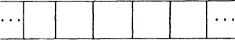

每格可以写一个符号。读头每次检查或扫描一个方格。带读头的机器具体采用什么技术，与我们无关。给定机器有特定字母表，由有限个符号 S₀、S₁、……、Sₙ 组成，规定 S₀ 是空白符 □。此外，机器有若干内部状态 q₀、q₁、……、qₘ。某时刻的动作由内部状态和当前扫描格中的符号唯一确定，动作是下列三种之一：

and each square can have a symbol written on it. The tape is inspected or *scanned* one square at a time by a *reading head*. The actual technology involved in a machine with a reading head does not concern us. A given machine has a specific *alphabet* consisting of a finite number of symbols *S*<sub>0</sub>, *S*<sub>1</sub>, …, *S<sub>n</sub>*(and we take *S*<sub>0</sub> to be the blank square □). In addition the machine possesses a number of *internal states* *q*<sub>0,</sub>*q<sub>1</sub>*, …, *q<sub>m</sub>*. *The* machine’s act at a given time is uniquely determined by its internal state and the symbol in the scanned square, and this act will be to either

| (i) | 改变当前扫描的符号， change the scanned symbol, |
| --- | --- |
| (ii) | 向右移动一格， move one square to the right, |

或者

or

| (iii) | 向左移动一格。 move one square to the left. |
| --- | --- |

一台机器可以用下列几类四元组完全规定：

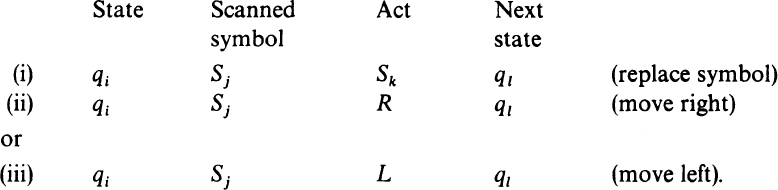

稍后将展示这种机器如何运行。

We shall show how such a machine operates shortly.

机器操作的唯一确定性，体现为不会有两个四元组以相同的 ⟨状态, 符号⟩ 对开头。若机器遇到某种 ⟨状态, 符号⟩ 组合，却没有对应四元组，就停机。若机器处于 qₖ 状态并扫描如下方格：

The unique determination of machine operations will be reflected by the fact that no two quadruples commence with the same 〈state, symbol〉 pair. If the machine ever reaches a 〈state, symbol〉 combination for which no quadruple exists, then it halts. If the machine is in state *q<sub>k</sub>* scanning a square thus

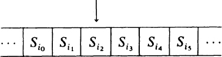

机器处于 q₁ 状态，扫描第二个 S₁，即

由于没有以 q₂ S₁ 开头的指令，机器此时停机。

构造机器指令表时，不妨设身处地想象自己就是机器，每次只能看到一格。内部状态相当于对先前扫描情况所作的“心中笔记”，使纸带某一部分的“记忆”可以带到另一部分。

When constructing a machine table it is helpful mentally to put oneself in the machine’s position of being able to see only one square at a time. Internal states correspond to ‘mental notes’ of situations previously scanned and hence enable ‘memory’ of one part of the tape to be carried to another part.

在构造复杂机器时，通常不必写出完整的标准指令表。只需把表中的若干行替换为已有机器能够完成的任务，因为调整 q 的下标来连接基本机器只是例行工作。例如，第一台机器使用 q₁、……、q₂₀，第二台使用 q₁、……、q₁₂，就把第二台的状态重新编号为 q₂₁、……、q₃₂。

In practice tables rapidly become lengthy even for simple computations, so we develop a stock of basic machines which perform tasks involved in a variety of computations. Then in constructing a complex machine we replace the lines in its table by tasks for which machines have already been constructed, since it is a routine matter to arrange the suffixes on the *q*’s so as to link up basic machines. For example, if the first machine uses *q*<sub>1</sub>, …, *q*<sub>20</sub>and the second *q*<sub>1</sub>, …, *q*<sub>12</sub> then we renumber the *q*’s of the second machine as, say, *q*<sub>21</sub>, …, *q*<sub>32</sub>.

基本任务的例子如下。

Examples of basic tasks are

1. 向右搜索 Sⱼ。

1. Search to right for *S<sub>j</sub>*.

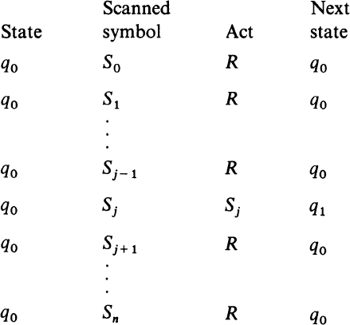

这台机器在 Sⱼ 上停机。若希望继续操作，可把 q₁ 用作后续四元组序列的初始状态。例如，把上面的 q₀ 换成 q₁、q₁ 换成 q₂ 再重复一次，就能搜索起点右侧的第二个 Sⱼ。“向左搜索”的机器当然类似。

This machine halts on *S<sub>j</sub>*. If we want the machine to take further action, we can use *q*<sub>1</sub> as the first state in a further series of quadruples. For example, a repeat of the above with *q*<sub>1</sub> in the place of *q*<sub>0</sub> and with *q*<sub>2</sub> in the place of *q*<sub>1</sub>gives a search for the *second S<sub>j</sub>* to the right of the starting point. A ‘search left’ machine is of course similar.

2. 给 S 加标记。

类似地，q₀ S′ S q₀ 可以“去掉 S 上的标记”。虽然必须把 S′ 当作单个符号，但可移动标记的全部好处仍然保留。要标记任一方格，只需把其中的 S 替换为 S′。

Similarly, *q*<sub>0</sub> *S*′ *S* *q*<sub>0</sub> ‘removes the marker’ from *S*. Although we have to treat *S*′ as a single symbol, all the advantages of a movable marker can be obtained. To put a marker on any square simply replace the symbol *S* in that square by *S*′.

3. 向右移动，并擦除所有标记。

3. Move right, erasing all markers.

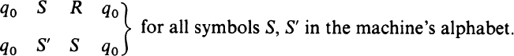

若希望机器遇到某个符号，例如 □，就停止，只需删去第二项为 □ 的那些四元组。

If we want this to stop at a given symbol, say □, we omit those quadruples whose second entry is □.

（标记以某种形式成为图灵机技术不可或缺的部分。根本原因是，任何机器的内部记忆，即内部状态数，都预先有界，而一般计算需要无界的记忆。例如，比较纸带上两段符号块的长度，不能只靠内部状态。若机器有 n 个内部状态，则长度至多 n + 1 的符号块中，必有两个在机器遍历后使其到达同一内部状态。因此，机器只能依靠在纸带上作出的标记来区分。最直接的方法是在两块之间来回移动，每次访问一块就再标记一格，直到某块用尽。另见下面的例子。）

(Markers are an indispensable item of Turing machine technique in one form or another. The basic reason is that any machine has its internal memory, that is, the number of internal states, bounded in advance, whereas general computation requires unbounded amounts of memory. For example, to compare the lengths of two blocks of symbols on its tape a machine cannot rely on internal states alone. If a machine has *n* internal states there will be two blocks among those of length at most *n* + 1 for which the machine arrives at the same internal state after traversing them both. Therefore it can only decide between them on the basis of marks made on its tape. The most obvious way to do this is to zig-zag back and forth between the blocks, marking one more square each time a block is visited, until one block is exhausted. (See also the example below.))

4. 把当前扫描格右侧的每个符号向右移一格。

4. Move each symbol on the right of the scanned square one square to the right.

这台机器对每个符号 Sᵢ 需要两个特殊状态。为清楚表明作用，用字母而非数字作下标。首先是“记住 Sᵢ”的状态 qᴿₛᵢ，机器看到 Sᵢ 时进入；其次是“送出 Sᵢ”的状态 qᴰₛᵢ，机器离开原先写着 Sᵢ 的方格时进入。

This machine requires two special states for each symbol *S<sub>i</sub>*. Accordingly we use letters as subscripts for these states, rather than numerals, to show their role more clearly. Firstly, a ‘remember *S<sub>i</sub>*’ state which we call *q<sub>RS</sub><sub>i</sub>* which the machine enters when it sees the symbol *S<sub>i</sub>* and secondly a ‘deliver *S*,’ state *q<sub>DS</sub><sub>i</sub>* which the machine assumes as it leaves the square formerly bearing *S<sub>i</sub>*.

若希望机器到达某个结束标记 Sₖ 时停止，就修改 qᴰₛₖ 的四元组，使它转入某个停机状态。

If we want the machine to stop when it reaches some end marker *S<sub>k</sub>* then we change the *q<sub>DS</sub><sub>k</sub>* quadruple to make a transition into some halting state.

现在举例说明如何由基本任务组合成复杂任务：下面的机器把给定的 1 符号块加倍。图中先是初始情形，再是依次执行四元组和基本任务后的情形。机器每次把一格复制到纸带空白部分，复制前先标记该符号。当原符号块中已无未标记格时，机器知道整块已复制完，于是擦除标记并停机。

Now as an example of the way a complex task may be synthesized from basic tasks, here is a machine which doubles a given block of 1’s. The diagram represents the initial machine situation, followed by the situations which result when the quadruples and basic tasks are applied. The machine copies one square at a time into the blank portion of its tape, putting a marker on the symbol to be copied before it does so. Then when the machine finds no unmarked square left in the given block, it knows it has copied the entire block, so it erases the markers, and halts.

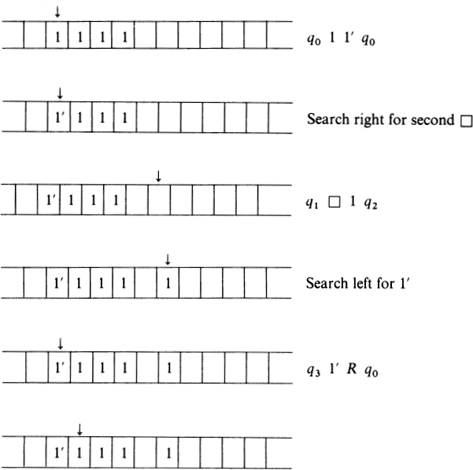

然后重复循环，得到

The cycle then repeats to give

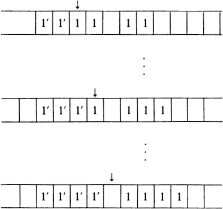

此时机器处于 q₀ 状态并扫描 □，尚无对应四元组，因此再加入指令“向左移动，擦除标记”，执行后得到：

At this point the machine is in state *q*<sub>0</sub> scanning □, a situation for which no quadruple has yet been given, so we now have the instruction ‘Move left, erasing markers’ and after applying it get:

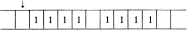

把基本任务展开为四元组表，再调整状态下标以连接相继的基本任务，就得到这台机器的标准指令表。

Expanding the basic tasks into their tables of quadruples, and arranging state subscripts so as to link up the successive basic tasks, we can obtain the standard table for this machine.

### 部分递归函数

### **Partial recursive functions**

规定用 n + 1 个 1 组成的符号块作为向机器输入数 n 的标准方式（0 也需要一个标记，好让机器知道确实有输入）。于是，每台图灵机 M 都关联一个部分函数 φ：φ(n) 是 M 从输入 n 开始、完成计算后纸带上留下的 1 的数目。称为“部分”函数，是因为并非每个 n 都会导致完成的计算：M 可能不停机。

Let us take a block of *n* + 1 ones as the standard way of presenting a number *n* to a machine (we need one mark for 0 just so the machine knows it is being presented with something). Then a partial function *φ* is associated with each Turing machine *M*, where *φ*(*n*) is the number of ones left on *M*’s tape after *M* has completed a computation beginning with presentation of the number *n*. We say ‘partial’ because not every *n* may lead to a completed computation—M may not halt.

k 元组，即按顺序排列的 k 个数，可用 k 个符号块表示，块之间以单个空白格隔开；类似地，M 关联一个 k 元部分函数。

A *k*-tuple of numbers (a set of *k* numbers in order) can be presented as *k* blocks separated by single blank squares, and a *k*-place partial function associated with *M* similarly.

定义：若部分函数 φ 能以上述方式与某台图灵机 M 关联，就称 φ 为部分递归函数；若它对全部自变量都有定义，即为全函数，则称 φ 为递归函数。

*Definition*. A partial function *φ* is called *partial recursive* if *φ* can be associated with some Turing machine *M* in the above manner; *φ* is called *recursive* if it is defined for all arguments (that is, is total).

因此，若接受一切计算都能由图灵机完成，则可计算的部分函数恰好就是部分递归函数。（必须考虑部分函数，而不能只考虑全函数，因为不存在可计算方法筛除那些不是全函数的部分函数。稍后讨论停机问题时会看清这一点。）

Thus if we accept that all computations can be done by Turing machines then the computable partial functions are precisely the partial recursive functions. (We are forced to consider partial functions, rather than total functions only, because there is no computable method for filtering out the partial functions which are not total. This will be apparent later in our discussion of the halting problem.)

上面的机器例子表明，φ(n) = 2n 是部分递归函数；也容易构造机器，表明 φ(m,n) = m × n 及其他常见函数都是部分递归函数。

Our machine example above shows that the function *φ*(*n*) = *2n* is partial recursive, and it is easy to construct machines which show that *φ*(*m*, *n*) = *m* × *n* and other common functions are partial recursive.

与可计算性相关的概念，是问题能否由算法解决。这里所说的问题，是寻求统一方法来回答无限多个问题 Q。例如，Q 可以是：对自然数 a、b、c，c 是否为 a 与 b 的最大公约数？众所周知，欧几里得算法能解决它，而且容易构造图灵机 M，输入任意三元组 ⟨a,b,c⟩ 后，最终在答案为“是”时发出“是”的信号，例如停在写着 1 的格上，否则发出“否”的信号，例如停在 □ 上。

Connected with the notion of computability is the notion of *solvability of problems by an algorithm*. The kind of problem I refer to is that where a uniform method is sought to answer an infinite class of questions *Q*. For instance, *Q* might be: is *c* the greatest common divisor of *a* and *b* (for natural numbers a, *b*, *c*)? As we know, the Euclidean algorithm is available to solve this problem, and it is easy to construct a Turing machine M which will take any 3-tuple 〈*a*, *b*, *c*〉 and eventually signal **YES** (say by stopping when it is scanning a square with a 1 on it if *Q* has answer **YES**), and signal **NO** (say by stopping on □) otherwise.

一般地，若问题 Q 在某个有限字母表中有自然表示，因而能写在图灵机纸带上，就可以给出下述定义。

In general, if the questions *Q* possess some natural representation in some finite alphabet, so that they can be put on the tape of a Turing machine, then we may set up the following definition.

定义：若存在图灵机 M，对任意 Q，答案为“是”时最终停在 1 上，答案为“否”时最终停在 □ 上，就称问题类 Q 可解，或可判定。

*Definition*. The class of questions *Q* is solvable (or decidable) if there is a Turing machine *M* which, when applied to any *Q*, eventually stops on 1 if the answer to *Q* is **YES**, and on □ if the answer to *Q* is **NO**.

### 图灵机的标准描述

### **Standard description of Turing machines**

本节为一种常称为“对角线”或“自指”的论证奠定基础。康托尔证明实数不可列的论证，以及哥德尔断言自身不可证明的语句（见下一章），都是这类例子。人们常对对角线论证心存疑虑，其实它完全具体，并无悖论。对图灵机而言，基础是：任何图灵机都可用有限符号序列描述，而有限符号序列本来就是图灵机处理的对象。

In this section we lay the foundation for an argument which is often called ‘diagonal’ or ‘self-referential’. Cantor’s proof of non-denumerability of the real numbers and Gödei’s sentence which asserts its own unprovability (see next chapter) are both examples of this type of argument. The diagonal argument is often regarded with suspicion; however in reality it is perfectly concrete and non-paradoxical. In the case of Turing machines it rests upon the fact that any Turing machine can be described by a finite sequence of symbols, and finite sequences of symbols are what Turing machines themselves act upon.

把这个字母表中与机器 M 关联的词称为 M 的标准描述，记为 ⌈M⌉。

We call the word in this alphabet which is associated with the machine *M* the *standard description* of *M* and denote it by <sup>⌈</sup>*M*<sup>⌉</sup>.

### 一个不可解问题

### **An unsolvable problem**

考虑下列无限问题类，即所谓“停机问题”的一种形式。

Consider the infinite class of question^ (one form of the so-called ‘halting problem’).

Qₘ：机器 M 作用于其自身的标准描述 ⌈M⌉ 后，最终会停在 □ 上吗？

可以合理地用词 ⌈M⌉ 表示问题 Qₘ，因为它包含全部必要信息。若机器 S 能解决此问题，则输入 ⌈M⌉ 后，若 Qₘ 的答案为“是”，最终停在 1 上；若答案为“否”，最终停在 □ 上。

It is reasonable to assume the question *Q<sub>M</sub>* to be represented by the word <sup>⌈</sup>*M*<sup>⌉</sup>, since this word contains all the necessary information. A machine *S* which solves this problem would then take the word <sup>⌈</sup>*M*<sup>⌉</sup> and eventually stop on 1 if the answer to *Q<sub>M</sub>* was **YES**, or on □ if the answer to *Q<sub>M</sub>* Was **NO**.

但 S 作用于 ⌈S⌉ 时会怎样？若 S 停在 1 上，就表示 Qₛ 的答案为“是”，即 S 输入 ⌈S⌉ 后停在 □ 上。若 S 停在 □ 上，就表示 Qₛ 的答案为“否”，即 S 不停在 □ 上。这一矛盾表明机器 S 不存在，因此没有解决 Qₘ 这一问题类的一般方法，称 Qₘ 在算法意义下不可解。

But how does *S* act on <sup>⌈</sup>*S*<sup>⌉</sup>? If *S* stops on 1 this indicates that the answer to *Q<sub>s</sub>* is **YES**, that is, that *S* stops on □ after being applied to <sup>⌈</sup>*S*<sup>⌉</sup>. And if *S* stops on □ this indicates that the answer to *Q<sub>s</sub>* is NO, in other words that *S* does not stop on □. This contradiction shows that the machine *S* does not exist, and hence there is no general method for solving the problem represented by the class of questions *Q<sub>M</sub>* and we say that *Q<sub>M</sub>* is algorithmically unsolvable.

有人可能说，这个问题不公平地利用了机器表示“是”和“否”的约定。然而，若另一台机器 T 能在其他约定下解决它，显然可把 T 接到一台翻译机器上，把 T 的“是”转换成 1、“否”转换成 □，得到符合约定的解题机器。上述论证表明这种组合机器不存在，所以 T 也不存在。

It may be claimed that the set-up of the problem unfairly exploits our convention for the signalling of YES and NO by machines. However any other machine *T* which solves the problem under another convention can obviously be converted into a machine which solves the problem under the agreed convention—simply by linking *T* to a machine which translates T’s YES into a 1 and *T*’s NO into a □. Such a combination machine cannot exist by the argument above; hence neither can *T*.

同样的论证也适用于问题的另一端，即 Qₘ 的表达方式。对任何合理表达，都存在图灵机把 ⌈M⌉ 转换为这种表达；将它与假设存在的新表示下的解题机器连接，又会得到已经证明不可能存在的解法。

The same argument applies to the other end of the problem—the way in which *Q<sub>M</sub>* is expressed. For any reasonable expression of *Q<sub>M</sub>* there is a Turing machine which converts <sup>⌈</sup>*M*<sup>⌉</sup> into this expression, so linking this to the hypothetical solution in terms of the new representation again gives a solution which we have shown to be impossible.

特别地，可以给问题纯粹的数值表示：把 ⌈M⌉ 看作六进制数码，尝试计算

In particular, the problem could be given a purely numerical representation—interpret <sup>⌈</sup>*M*<sup>⌉</sup> as a numeral in base 6 and try to calculate

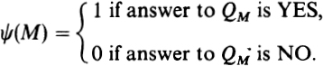

由于没有机器能做到，ψ 是一个非部分递归函数。

Since no machine can do this, *ψ* is a function which is not partial recursive.

对这个问题还可能有另一种不安：如果这些不可判定性结果都依赖病态的“自指”构造，它们在数学上有何意义？答案是，同样的病态实际上也出现在谓词演算、群论等表面上健康的结构中。可以证明，若能解决其中任一理论的可推导性问题，就能解决 Qₘ 的问题；下面将对谓词演算说明这一点。

A further source of uneasiness with this problem may be expressed as follows: of what mathematical significance are such undecidability results if they all rest on pathological ‘self-reference’ constructions? The answer to this is that the same pathology actually occurs in such superficially healthy structures as predicate calculus and group theory. It is possible to show (as we shall for predicate calculus) that a solution of the problem of deducibility in either of these theories would yield a solution of the problem of the *Q<sub>M</sub>*’s.

### 通用机

### **Universal machine**

也许有人以为，Qₘ 问题不可解，是因为单台机器无法涵盖所有机器的运行。事实上，确实存在通用机 U：它接受任意机器的标准描述 ⌈M⌉ 和任意纸带图样 P 的编码 ⌈P⌉，然后模拟 M 作用于 P 的过程。因此，必须转而承认，关于 U 本身也存在不可解问题。

It may be thought that the problem of the *Q<sub>M</sub>*’s is unsolvable because of the inability of any single machine to encompass the workings of all machines. In fact, a universal machine *U* does exist, a machine which will take the standard description <sup>⌈</sup>*M*<sup>⌉</sup> of any machine and a coding <sup>⌈</sup>*P*<sup>⌉</sup> of any tape pattern *P*, and proceed to simulate the action of *M* applied to *P*. So we are forced instead to the conclusion that an unsolvable problem exists concerning *U*.

Qᵤ：通用机 U 作用于词 W 后，最终会停在 □ 上吗？

把 Qₘ 问题“浓缩”为关于单台机器的问题，对谓词演算的不可判定性证明至关重要：最终将把机器 U 编码为谓词演算公式 φ，并把 U 对给定输入的作用表示为 φ 的逻辑后果。

This ‘condensation’ of the problem of the *Q<sub>M</sub>*’s to a problem about a single machine is crucial to the undecidability proof for the predicate calculus, for we shall ultimately code the machine *U* as a formula *φ* of predicate calculus, and express the effect of *U* on given inputs as logical consequences of *φ*.

一旦认识到存在算法能重现给定机器 M 对纸带图样 P 的作用，通用机的存在就很明显。用标记指出 M 的四元组中当前的内部状态，以及 P 中当前扫描的方格。随后在二者间来回移动，执行当前四元组要求的 P 中变化，找到以下一状态开头的四元组，把当前状态标记移过去，等等，都很容易。

Now the existence of a universal machine is apparent as soon as one realizes that there is an algorithm for reproducing the effects of a given machine *M* on a tape pattern *P*. Markers are used to tag the current internal state among the quadruples of *M* and the square in *P* currently being scanned. It is a simple matter to move back and forth between them, carrying out the change in *P* indicated by the quadruple which is being applied, finding the quadruple which commences with the next state, shifting the current state marker to it, etc.

技术上的复杂性来自 U 只有有限个内部状态，因而只能读取并“记住”有限种不同符号。这意味着，U 必须用不同长度的符号块表示被模拟机器 M 的不同状态和符号，并逐格费力比较这些块，判断是否确实代表同一符号。此外，要把一个符号换成另一个，U 实际上必须把一个符号块换成另一个，通常长度不同，因此必须反复把纸带图样的某些部分向左或向右移一格，直到新符号块获得恰好容纳它的空间。

A technical complication arises from the fact that *U* has only finitely many internal states and hence it can only read and ‘remember’ finitely many different symbols. This means that *U* must operate with blocks of symbols of different lengths to represent different states and symbols in the machine M being simulated, and laboriously compare blocks square by square to see if they actually represent the same symbol. Also, to replace one symbol by another *U* must actually replace one block by another, generally of a different length, so portions of *U*’s tape pattern must be shifted one square to the right or left repeatedly until the new block being created finds a space in which it fits.

所有这些操作都能由基本任务 1—4 之类的操作组合而成。与其列出数百个四元组，不如给出 U 的基本结构图。

All these operations can be accomplished by synthesis from basic tasks such as 1–4, and it is preferable to give a diagram of the underlying structure of *U* rather than attempt to list hundreds of quadruples.

如前所述，U 的输入纸带形如 *⌈M⌉**⌈P⌉*，在 M 的当前状态块和 P 的当前扫描符号块上保留标记。（* 当然应取标准字母表中的某个符号，例如 1′″″。）当前状态块后依次是“当前符号块”“当前动作块”和“下一状态块”。于是 U 可由下列流程图描述：

As stated above, *U* is applied to a tape of the form *<sup>⌈</sup>*M***<sup>⌉</sup>**<sup>⌈</sup>P<sup>⌉</sup>***, and markers are kept on the current state block in M and the scanned symbol block in *P*. (The *’s should of course be some symbol in the standard alphabet, for instance 1′″″.) The current state block will be followed by the ‘current symbol block’, ‘current act block’ and ‘next state block’. *U* can then be described by the following flow chart:

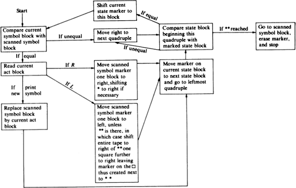

### 用词变换表示图灵机

### **Turing machines in terms of word transformations**

所研究机器的纸带在任一时刻都只有有限多个标记，因此某个机器格局的全部必要信息可编码为一个词，其中包括：(i) 包含当前扫描格及全部标记的那段纸带上的符号序列；(ii) 扫描格位置和当前状态。下面举例说明一种编码方法。把

Since we are concerned with machines whose tape contains only finitely many marks at a given time all the essential information in a given machine situation can be encoded in a word which includes (i) the sequence of symbols on the portion of the tape which includes the scanned square and all marks and (ii) the position of scanned square and current state. One way of doing this is illustrated by the following example. Represent

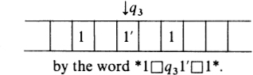

（状态符号放在代表当前扫描格的符号左边，用 * 作端点标记。）

(The state symbol is placed to the left of the symbol representing the scanned square, and *’s are used as end markers.)

把这样的词 W 称为格局词，则紧接其后的格局词 W′，由涉及 W 中 qᵢSⱼ 组合的变换决定。下列词变换能在所有情形中实现从 W 到 W′ 的变化。

If we call such a word *W* a situation word, then the word *W*′ for the immediately consequent situation will be determined by a transformation involving the combination *q<sub>i</sub>S<sub>j</sub>* occurring in *W*. The following transformations of words accomplish the change from *W* to *W*′ in all cases.

四元组类型 变换

Type of quadruple Transformation

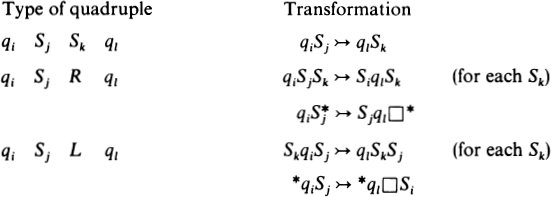

* 的作用是：每当 q 符号需要继续向右或向左移动时，就提供新的空白格。

The * in effect makes new blank squares available whenever they are needed for further movement of the *q* symbol to the right or the left.

因此，给定机器 M 可用与其四元组对应的有限词变换集表示。对任意格局词，至多有一个变换适用，所得词序列正确反映 M 的格局序列。特别地，M 停在 □ 上的格局，对应于含 qₕ□ 组合的词，而该组合不出现在 M 的任何变换左端。

A given machine *M* is thus representable by a finite set of word transformations corresponding to its quadruples. Given any situation word, at most one of these transformations applies to it, and the sequence of words obtained correctly reflects M’s sequence of situations. In particular, a situation where M halts on □ corresponds to a word containing a combination *q<sub>h</sub>*□ not occurring on the left hand side of any transformation for *M*.

以及

and

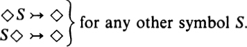

因此，出现一个使 M 停机的词时，就产生符号 ◊，吞掉其他全部符号，最后只剩词 ◊。与 M 的变换不同，后加的变换并非完全确定性的，虽然也可以安排成确定性，因为给定词可能适用多个变换；不过，只有初始格局词最终导致停在 □ 上时，这些变换才会起作用。

Thus the occurrence of a word on which the machine *M* halts creates a symbol ◊ which swallows all other symbols, leaving only the word ◊ itself. Unlike the transformations for *M* the latter transformations are not completely deterministic (though this could be arranged), because more than one may be applicable to a given word; however they can come into operation only if the initial situation word leads to a halting on the □ situation.

把扩大的变换集称为 M 演算；若存在 M 演算中的变换序列把 W₁ 变成 W₂，就一般地记为 W₁ W₂。于是，对格局词 W，W ◊ 当且仅当 W 描述的格局最终导致 M 停在 □ 上。因此，当 M 是 U 这样使后一问题不可解的机器时，就得到下述不可解问题：

Let us call this extended set of transformations the *M*-calculus and write *W*<sub>1</sub> *W*<sub>2</sub> in general if there is a sequence of transformations in the *M*-calculus which takes *W*<sub>1</sub> to *W*<sub>2</sub>. Then if *W* is a situation word we have *W* ◊ if and only if the situation described by *W* eventually leads to *M* halting on □, so when *M* is a machine (such as *U*) for which the latter problem is unsolvable we obtain the following unsolvable problem:

对任意给定词 W，判定是否能通过 U 演算的变换得到 W ◊。

Decide for any given word *W*, whether *W* ◊ via the transformations of the *U*-calculus.

### 在谓词演算中表示词变换

### **Representation of word transformations in predicate calculus**

本节利用上述 U 演算中的变换问题，最终把停机问题翻译为谓词演算中的可推导性问题。所用语言把 U 演算的每个符号 □、1、◊、* 等作为常元，另有连接词的函数 f，以及表示变换的单个二元谓词 Tr。

In this section the halting problem is finally translated into a problem of deducibility in the predicate calculus, using the above problem of transformation in the *U*-calculus. We use a language which has each symbol □, 1, ◊, * etc. of the *U*-calculus as a constant, a function *f* which links words together, and a single binary predicate Tr for transformation.

众所周知，原则上可从谓词演算中消去常元和函数字母，也可消去允许用常元项替换变量的规则。这里使用它们，是因为这样能更清楚地显示词变换与推导之间的对应。

As we know, constants and function letters can in principle be eliminated from the predicate calculus, as can the rule which allows substitution of constant terms for variables. I use them because they make the parallel between word transformations and deductions more transparent.

1. 连接字母的函数。

1. Function for linking letters.

于是，任意词都可视为常元项，例如 *□q₃1* 就是 (* (□ (q₃ (1 (*)))))。公理 (1) 允许任意调整括号，所以括号实际上无关紧要，以下省略。

Any word can then be regarded as a constant term, for instance *□*q*<sub>3</sub>1* is (*(□(*q*<sub>3</sub>(1(*))))), and axiom (1) allows us to rearrange the brackets any way we please, so brackets are actually immaterial and we omit them from now on.

2. 变换公理。

2. Axioms for transformation.

对任意项 t₁、t₂，可把 t₁ t₂ 看作谓词演算公式。（读者若愿意，可更常规地写成 Tr(t₁,t₂)。）当 t₁、t₂ 为常元项 W₁、W₂ 时，公式 W₁ W₂ 断言 U 演算能把 W₁ 变成 W₂。

We can consider *t*<sub>1</sub> *t*<sub>2</sub> for any terms *t*<sub>1</sub>, *t*<sub>2</sub> as a formula of predicate calculus. (The reader may represent it more conventionally as Tr(*t*<sub>1</sub>, *t*<sub>2</sub>) if he prefers.) When *t*<sub>1</sub>, *t<sub>2</sub>* are constant terms *W*<sub>1</sub>, *W*<sub>2</sub> the formula *W*<sub>1</sub> *W*<sub>2</sub> asserts that *W*<sub>1</sub> is transformable into *W*<sub>2</sub> by the *U*-calculus.

希望写出足够的公理，保证公式 W₁ W₂ 可推导，当且仅当 W₁ W₂ 实际成立。

We want to write down enough axioms to guarantee the deducibility of the formula *W*<sub>1</sub> *W*<sub>2</sub> if and only if *W*<sub>1</sub> *W*<sub>2</sub> actually holds.

用常元项 X、Y 替换变量 x、y，即可从 (2) 推出 XTY XT′Y。同样明显的是，从 (2) 推出的所有关系 W W′，都正确表示 U 演算中的直接后继。

and we can deduce *XTY* *XT*′*Y* from (2) by substitution of the constant terms *X*, *Y* for the variables *x*, *y*. It is also clear that all relations *W* *W*′ deducible from (2) correctly represent immediate consequences in the *U*-calculus.

只要 W₂ 是 W₁ 能变换到的词，就能证明 W₁ W₂；同样明显的是，使用 (3) 的推导都正确表示实际词变换。

to be able to prove *W*<sub>1</sub> *W*<sub>2</sub> if *W*<sub>2</sub> is any word into which *W*<sub>1</sub> can be transformed, and again it is clear that any deductions from (3) correctly represent actual word transformations.

3. 消去公理；不可判定性。

3. Elimination of axioms; undecidability.

给定任意 W，都能有效构造公式 φ → (W ◊)。因此，若能判定这个公式是否可推导，就能判定 W ◊ 是否成立。

Given any *W*, we can effectively construct the formula *φ* → (*W* ◊), so if we could decide whether this formula was deducible we could decide whether *W* ◊.

上一节已证明后一问题不可解，因此谓词演算中的可推导性问题也不可解。也就是说，不存在算法，使我们对任意给定的谓词演算公式 ψ，都能判定它是否可由谓词演算公理推出。

As established in the last section, the latter problem is unsolvable, hence so is the problem of deducibility in predicate calculus. That is, *there is no algorithm which will enable us to decide, given any formula ψ of predicate calculus, whether or not φ is deducible from the axioms of predicate calculus*.

由完备性定理，谓词演算中可推导的公式恰好就是逻辑有效公式，因此这个结果也表明，不存在判定给定公式是否逻辑有效的算法。

By the completeness theorem, the deducible formulas in predicate calculus coincide with those that are logically valid, so this result also shows that no algorithm exists for deciding whether a given formula is logically valid.

## 5. 哥德尔不完备性定理

## 5. **Gödel’s Incompleteness Theorems**

本世纪初，数学家希尔伯特提出一个问题：寻找形式系统，给出所有真的数学语句，而且只给出真语句。这称为“希尔伯特纲领”。然而，仅仅形式算术这一简单情形就打破了这个计划。形式算术指处理自然数 0、1、2、……及加法、乘法等通常基本函数的形式系统。1931 年，哥德尔证明，若形式系统 F 包含算术，则：(i) 存在 F 中、甚至算术中的语句，它为真却不可证明；(ii) 若要证明 F 的一致性，需要比 F 更强的系统。

EARLIER this century the mathematician Hilbert posed the problem of finding a formal system which gave all the true mathematical statements, and only those. This was called ‘Hilbert’s programme’. However, the simple case of formal arithmetic disrupted this programme. By formal arithmetic I mean a formal system which will deal with the arithmetic of the natural numbers 0, 1, 2, ... and the usual basic functions such as addition and multiplication. In 1931, Gödel proved that if a formal system, let us call it *F*, included arithmetic, then (i) there is a statement of *F* (or indeed of arithmetic) which is true, but not provable and (ii) we need a system stronger than *F* if the consistency of *F* is to be proved.

本章将描述一个足以处理算术中一切通常问题的形式系统，甚至包括费马大定理这类非同寻常的问题。还将展示一个说“我不可证明”的公式。这个公式为真，因此显然不可证明。

In this chapter I am going to describe a formal system of arithmetic which will be strong enough to treat all the usual things in arithmetic that one might want to deal with, including even such exotic things as Fermat’s Last Theorem. Also in this chapter I shall exhibit a formula which says ‘I am not provable’. This formula will be true, so clearly it will not be provable.

其实描述这个公式很容易，细节稍后再谈。先考虑简写为 x Pf⁺(x,b,c) 的公式。它为真，当且仅当 x 是某个证明的哥德尔数（稍后解释其含义），而该证明所证明的公式，是把数码 （稍后也将解释）代入哥德尔数为 b 的公式的自由变量 y 后得到的。在通常整数中解释时，它说：存在 x，x 是某个公式证明的哥德尔数，而该公式由把 代入唯一自由变量而得到。代入前公式的哥德尔数为 b。

In fact it is very easy to describe this formula. I shall go into the detail later. For the moment, consider a formula which I shall abbreviate as *x* **Pf**<sup>+</sup>(*x*, *b*, *c*). This is to be true only when *x* is the Gödel number (and I shall say what this means later on) of a proof of the formula that one gets when one substitutes the numeral (I shall say what this means later on, too) for the free variable *y*, in the formula whose number is *b*. When this formula is interpreted in the ordinary integers, it says that there is an *x* such that *x* is the Gödel number of a proof of a certain formula when is substituted for its only free variable. The number of the formula is *b* before this substitution is performed.

现在考虑公式 x Pf⁺(x,y,y)。设它本身的哥德尔数为 g。研究把数 g 的数码 代入 y 后会发生什么。仔细考察可见，稍后还会重申，这个公式说的正是：这个公式本身没有证明。这确实为真，因为若有证明，就会产生矛盾。实际上可表明，它及其否定都没有证明。补全细节后，就得到一个为真却不可证明的公式。还有进一步的结果：算术中不能证明算术自身的一致性，而这一论证依赖于把前面的论证形式化。

Now consider the formula *x* **Pf**<sup>+</sup>(*x*, *y*, *y*). This formula itself will be given a Gödel number *g*, say. We shall investigate what happens when you put in the numeral of the number *g* in the formula for the *y*. If you examine this formula (and I shall reiterate this later), what it says is that there is no proof of this very same formula and that is indeed true; there is no proof of this formula because if there were a proof, we should have a contradiction. Indeed one can show that there is neither a proof of it nor a proof of its negation. What we shall have then, when we have filled in the details, will be a formula which is true but not provable. And there are further ramifications. One can actually show that in arithmetic one cannot prove the consistency of arithmetic and the argument for this depends upon a formalization of this former argument.

这就是要逐步达到的目标。现在回到开头，考虑基本算术。它的关键特征是什么？要能谈论零，并能对任意给定数加一。还要能谈论数学归纳法。直观地说，若零有某性质，且任意特定数 n 有此性质时 n + 1 也有，那么每个数都有。高中数学中对此大概已很熟悉。显然可以写出处理数与归纳法的公式。如前所述，只要形式系统包含某种合理的形式算术系统，哥德尔不完备性定理就适用。因此，下面描述一个相当简单的形式系统。

This is what I am going to lead up to. Now I want to go right back to the beginning and consider basic arithmetic. What are the crucial features of arithmetic? We want to be able to talk about zero, and, given any particular number, we want to be able to add 1 to it. There is one other important thing that we want to be able to talk about: mathematical induction. Mathematical induction, intuitively speaking, says that if zero has a certain property and if, whenever a particular individual number *n* has that property, *n* + 1 also has that property, then every number has that property. This is something which is probably familiar from high-school mathematics. In writing down formulae it is pretty obvious that some can be produced that deal with numbers and induction and as I remarked earlier, if you have any formal system that involves any reasonable formal system for arithmetic, then Gödel’s Incompleteness Theorem applies. So we shall now describe quite a simple formal system.

语言含常元符号 0，解释为零；含一元函数字母 s，读作“后继”，解释为加一；还含 +、×、=，分别解释为加、乘、等于。除此之外，使用谓词演算的全部通常机制。也可以再加入许多东西，甚至让变量遍历函数等等，都不影响证明。谈到公理时还会看到，也可加入一些额外公理。不过存在限制：若加入无限多个公理，可能无法再证明哥德尔定理。例如，把形式语言中恰好为真的所有算术语句都作为公理，则一切真语句都可证明，一切可证明语句都为真，这就加得太多了。但只加入任意有限条公理或公理模式，仍可实施哥德尔的构造。

It is going to be in a language with a constant symbol 0 interpreted as zero. It has a one-place function letter s which I shall read as ‘successor’. It is interpreted as adding one. We shall have also +, ×, and =, interpreted as plus, times, and equals. Apart from this we shall have all the usual machinery of predicate calculus. And we could have lots of other things too. We could even have variables ranging over functions and so on; it will not make any difference at all. The proof will still go through. Indeed, when I get to the question of axioms, we shall see that we can throw in a few extra of these too. There will be certain restrictions here: if you throw in an infinite number of axioms, then you might not be able to prove Gödel’s theorem. For example, if you add as axioms *all* the statements of arithmetic in our formal language which happen to be true, then everything which is true is provable and everything which is provable is true, so that is going too far. But if we just add any finite number of axioms or schemes for axioms, then we shall be able to carry out Gödel’s construction.

那么采用哪些算术公理？以下这些就足够。首先是等词公理，第 3 章已谈到。实质上只需要：

So what do we take as our axioms for arithmetic? In fact the following will suffice. First we have axioms for equality. Those have been touched upon before in Chapter III. Essentially all we need are

(i) x = x，

(i) *x* = *x*,

(ii) x = y → (x = z → y = z)，

(ii) *x* = *y* → (*x* = *z* → *y* = *z*),

(iii) 对语言中任意含两个自由变量的公式 A，x = y → (A(x,x) → A(x,y))。它说，若 x、y 相同，则一个的任何性质也是另一个的性质，因为把它们视为同一个对象。这些只是通常的等词公理。

(iii) *x* = *y* → (*A*(*x*, *x*) → *A*(*x*, *y*)) for any formula *A* of the language with two free variables. This says if *x* and *y* are the same, then any property of one is a property of the other and this is so because we are thinking of *x* and *y* as being identical objects. So these are just the ordinary axioms for equality.

需要哪些特殊公理？皮亚诺在非形式数学中写出一组恰好刻画自然数的公理。把它们的对应形式写下来，就完全足够。第一条说，0 不是任何数的后继。

下一条说，任意给定数的前驱是唯一的。

这里采用这种写法。形式上本应写成 +(x,y)，但为方便写成 x + y，这只是一个技术性约定。

I am going to write them in this way. Formally one ought to write, for example, + (*x*, *y*) but for convenience I write *x* + *y*. It is merely a technical trick that is involved here.

首先问：这个系统足够强，能给出我们需要的一切吗？答案是“是”。这里不向读者征求挑战。仅举一例，系统中“x 整除 y”可简单表达为 z(x × z = y)。再谈论 x 的因子，就很容易写出说“x 是素数”的公式。

The first question we ask is: Is this system powerful enough to give us all the things we want? The answer is: Tes, it is’. I shall not ask for challenges from the reader. Just as an example we can express *x* divides *y* in this system simply by the formula *z*(*x* × *z* = *y*). And it is very easy to write down a formula which says that *x* is a prime number by just talking about the numbers which divide *x*.

还可表示所有数 0、1、2、……，它们在形式系统中分别由数码 0、s0、ss0、……表示。用 表示 n 个 s 后接一个 0 的符号串。

We also have representations of all the numbers 0, 1, 2, These are represented in the formal system by the *numerals* 0, s0, ss0, ... respectively. We write for a string of *n s*’s followed by a 0.

前面谈的是用数表示公式。哥德尔找到了这种方法，如今称为哥德尔编号。考察语言，给每个基本符号指派一个数。基本符号有哪些？0 的编号为 1，即符号零的哥德尔数。（技术原因要求哥德尔数非零，稍后会看清。）s 的编号为 2，+ 的编号为 3，依此类推：

Now what I was talking about earlier was representing a formula by numbers. Gödel found a way of doing this by what is now known as Gödel numbering. We have a look at our language and what we do is to assign numbers to all the basic symbols in our language. What are the basic symbols? We have 0 and we give this the number 1 which is the Gödel number zero. (We want Gödel numbers to be non-zero for technical reasons which will emerge later on.) *s* gets the number 2, + the number 3, and so on:

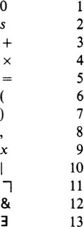

需要许多变量 x₁、x₂、……。方便的做法是给 x 加小竖线下标，得到 x₍|₎、x₍||₎、x₍|||₎、……，以下采用这种写法。表中列出了语言的全部符号；若还有其他符号，也可编号。只用有限多个符号比较方便，因此用竖线构造变量，但并非必需。

I want to have lots of variables *x*<sub>1</sub>, *x*<sub>2</sub>, ... **A** convenient device is to put little bars as subscripts to *x* to get: *x*<sub>|</sub>, *x*<sub>||</sub>, *x*<sub>|||</sub>, ... and we shall use these instead. The list gives all the symbols that we have in our language. If we had others, we could give them numbers, too. It is convenient to use only a finite number of symbols, which is why I put the bars on the *x* for the variables, but it is not essential.

把上面表示 2 + 2 = 4 的那个相当可怕的表达式 (*)，写成 +(s(s(0)),s(s(0))) = s(s(s(s(0))))，再逐一写出对应编号，得到

If you take the rather ghastly expression (*) above for 2 + 2 = 4 in the form + (*s*(*s*(0)), *s*(*s*(0))) = *s*(*s*(*s*(*s*(0)))) and write down the corresponding numbers, it comes out to be

3 6 2 6 2 6 1 7 7 8 2 6 2 6 1 7 7 7 5 2 6 2 6 2 6 2 6 1 7 7 7 7

这还没有问题，显然可以从这堆数恢复 2 + 2 = 4。但若出现 139 呢？应解释为 13 后接 9，即 的编号后接 x 的编号，合起来为 x；还是解释为 1、3、9，即 0 + x 的编号序列？此时无法决定，需要区分多种解释的方法。例如 9 720 000 000 可唯一写成 2⁹·3⁵·5⁷，其中底数是依次排列的素数。若以此编码数列 9、5、7，就不会混淆，因为这种编码唯一。于是可唯一得到 x = 0 的数值编码。用这种方式，可以把整串数编码为单个数；给定编码，总能通过素因数分解唯一恢复语言表达式。数会变得极大，但理论上无关紧要。例如，2 + 2 = 4 的形式表达式 (*) 的编码为 2³·3⁶·5²·7⁶·11²·13⁶·17¹·19⁷·23⁷·29⁸·31²·37⁶·41²·43⁶·47¹·53⁷·59⁷·61⁷·67⁵·71²·73⁶·79²·83⁶·89²·97⁶·101²·103⁶·107¹·109⁷·113⁷·127⁷·131⁷。具体算出来很大，但原则上总能计算，数学关心原则，而非算出某数值表达式是否可行。再如编码 x = 0， 的编号为 11，x 为 9，= 为 5，0 为 1，因此编码为 2¹¹·3⁹·5⁵·7¹。用 ⌈φ⌉ 表示 φ 的哥德尔数，便有 ⌈x = 0⌉ = 2¹¹·3⁹·5⁵·7¹ = 881 798 400 000。当然，有些数不编码公式，例如 3 = 3¹ = 2⁰·3¹，编码数列 0、1，并不对应语言中的公式。但这无妨，因为总能检查是否确实编码了什么：所有指数都必须在 1 至 13 之间，因为只用了这些符号编号。

Now that one is all right. It is quite clear how to recover the 2 + 2 = 4 from this mass of numbers. But what happens if we have something like 139? Should we interpret this as being a 13, which is the number of an , followed by a 9, which is the number of *x*, and thus together stands for *x*, or should we interpret it as a 1 followed by a 3, followed by a 9 which is the sequence of numbers for 0 + *x*? There is in this case no way to decide how to interpret the number. We need some device that enables us to distinguish between two or more possible interpretations. Now suppose we take a simple number, for example 9 720 000 000. We can write this as 2<sup>9</sup>.3<sup>5</sup>.5<sup>7</sup> and we can write it in only one way when the bases are the primes in order of magnitude. Now if we regard 2<sup>9</sup>.3<sup>5</sup>.5<sup>7</sup> as coding the sequence of numbers 9, 5, 7, we are safe because we can code a sequence in exactly one way by using this device. Thus we can uniquely get the number code for *x* = 0. So if we use the prime numbers in this way, we can code into a single number a whole string of numbers, and given a number, we can always factorize it and recover the expression of our language in a unique way. The numbers will get very large indeed, but this is of no theoretical significance. For example, the number we get for the formal expression (*) for 2 + 2 = 4 is: 2<sup>3</sup>.3<sup>6</sup>.5<sup>2</sup>.7<sup>6</sup>.11<sup>2</sup>.13<sup>6</sup>.17<sup>1</sup>.19<sup>7</sup>.23<sup>7</sup>.29<sup>8</sup>.31<sup>2</sup>.37<sup>6</sup>.41<sup>2</sup>.43<sup>6</sup>.47<sup>1</sup>.53<sup>7</sup>.59<sup>7</sup>.61<sup>7</sup>.67<sup>5</sup>.71<sup>2</sup>.73<sup>6</sup>.79<sup>2</sup>.83<sup>6</sup>.89<sup>2</sup>.97<sup>6</sup>.101<sup>2</sup>.103<sup>6</sup>.107<sup>1</sup>.109<sup>7</sup>.113<sup>7</sup>.127<sup>7</sup>.131<sup>7</sup>. This, when explicitly calculated, is rather large but it does not matter because in principle we can always calculate these numbers and mathematics is only concerned with principles and not with the feasibility of working out some numerical expression. As another example, suppose we want to code *x* = 0. Now gets 11, *x* gets 9, = gets 5, and 0 gets 1, so the Gödel number for the formula is 2<sup>11</sup>.3<sup>9</sup>.5<sup>5</sup>.7<sup>1</sup>.1 shall write <sup>⌈</sup>*φ*<sup>⌉</sup> for the Gödel number of *φ*, so <sup>⌈</sup>*x* = 0<sup>⌉</sup> = 2<sup>11</sup>.3<sup>9</sup>.5<sup>5</sup>.7<sup>1</sup> = 881 798 400 000. Of course there are some numbers which do not code formulae, for example the number 3, since 3 = 3<sup>1</sup> = 2<sup>0</sup>.3<sup>1</sup> which codes 0, 1 which is not a sequence of Gödel numbers corresponding to a formula of the language. But that is all right, because we can always tell whether we code anything or not because all the exponents have to lie between 1 and 13. These are the only ones which we have been using.

前面说过，可用数码表示数：零为 0，一为 s(0)，二为 s(s(0))，等等。现在问，能否有机器判断 n 是否为某个数码的哥德尔数？或者问，数码可能有哪些哥德尔数？数码要么是零，要么以哥德尔数为 2 的 s 开头，后面一对括号包着已经是数码的东西。可以为此写出机器。

I said that we could represent the numbers by numerals. That is, we can represent zero by 0, one by *s*(0), two by *s*(*s*(0)), etc. Now I want to know whether we can have a machine which tells us whether *n* is the Gödel number of a numeral or not. Or alternatively we could ask: What are the possible Gödel numbers of the numerals? If something is a numeral, one possibility is that it could be zero and the other is that it starts off with an 5, which has Gödel number 2, and then has a pair of brackets around something which is already a numeral. Now we can write down a machine for this.

关键当然是，这些事情都可计算。确实能有机器在有限时间内判定 n 是否有此性质。作为语言表达式，数码定义如下：常元符号零是数码；若 θ 是数码，则 s(θ) 也是。因此，判断某数是否为数码哥德尔数的机器如下：先输入数 n。零的符号编号是 1，作为只有一个成员的序列，表达式 0 的编码是 2¹ = 2。先问 n = 2 吗？若是，任务完成，它就是数码 0 的编号。若否，则分解素因数，检查前两个素数的指数是否分别为 s 的编号 2、左括号的编号 6，最后一个指数是否为右括号的编号 7。若否，不可能是数码。若是，就删去对应指数 2、6、7 的 s、左括号、右括号，把剩余部分重新编码为 n*，回到起点。数不断变小，最终必得到“不是数码”或“是数码”，两种情形过程都最终停止。

The crucial point of course is that all these things are computable. You really can have a machine that will decide in a finite time whether *n* has this property or not. Now numerals, which are expressions in the language, are defined by saying that the constant symbol zero is a numeral and if we have got something, call it *θ* which *is* a numeral, then *s*(*θ*) is a numeral, so the machine which just calculates whether something is the Gödel number of a numeral looks like this: first we plug in our number. Now zero has the Gödel number 1 and it is a sequence with just one member, so we get as the Gödel number of the sequence 0, the number 2<sup>1</sup> = 2. So we first ask: is *n* = 2? If it is we are home and dry because that is just the number of the numeral 0. If the answer is NO then we factorize the number and ask if the exponents of the first two primes in the factorization are the number for 5, which is 2, and the number for (, which is 6, and whether the last exponent is the Gödel number for the right-hand bracket, which is 7. Now if the answer is NO, then the thing cannot possibly be a numeral. If the answer is YES we remove the *s*, the (, and the) corresponding to the exponents 2, 6, and 7 and we recode as *n** and go back to the beginning. Then the numbers are getting smaller and smaller, so eventually we shall get the answer: NO, it is not a numeral, or: YES, it is a numeral. In either case the process ultimately stops.

输入 n。问 n = 2 吗？若是，回答“是”。若否，作素因数分解，检查前两个指数是否为 2、6，最后一个是否为 7。若否，失败：n 不是数码的哥德尔数。若是，去掉 s、左括号和右括号，把剩余部分重新编码为 n*，重新输入。

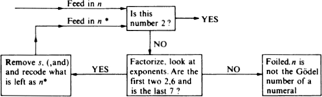

现在回到公式的定义（第 12 页），便能看到采用那种定义方式的另一个原因。所考虑系统唯一的谓词字母是 =，所以基本公式就是有意义的等式：由加、乘、后继等构成的某个可能复杂的表达式，等于另一个可能复杂的表达式。不允许 0 = + 这样的表达式。定义第二款说，若 A 是公式，则 A 也是；若 A、B 是公式，则 (A & B) 也是。第三款说，若 A 是公式，v 是变量，则 vA 是公式。（这里变量是带一串小竖线下标的 x。）

Now let us return to the definition of a formula (p. 12) and you will see another reason why we gave our definition of a formula in the particular way we did. In the system we have been considering, the only predicate letter that we have is =. So the basic formulae are just the meaningful equations. These will say that some (perhaps complicated) expression with plus, times, successor, etc. is equal to some other (perhaps complicated) expression. We disallow expressions like 0 = + . The second clause of the definition says that, if *A* is a formula, then so is *A* and also, if *A* and *B* are formulae, then so is (*A* **&** *B*). The third clause says that if *A* is a formula and *v* is a variable, then *vA* is a formula. (And in this set-up, a variable is an *x* with a string of little bar subscripts on it.)

最后一款说，除此之外没有别的公式。因此，要判定给定符号序列是否为公式，先问：它是等式吗？若是，便完成了。若否，再问是否以 开头；若是，去掉它，检查剩余部分是否为公式。若是，也完成了；若否，就继续，直到去掉所有开头的 。此后可能仍是公式，但不以 开头。再试下一种情形：是否形如 (A & B)，即左括号、一串符号、&、另一串符号、右括号？若是，检查 A、B 是否都是公式；否则试下一种。最后，若前面都不适用，就问是否以 开头。每次所考察的符号串都变短，因此过程最终停止。对哥德尔数也能做完全相同的事：构造机器回答问题 Q：“n 是否为某公式的哥德尔数？”这里公式的哥德尔数指形如 2ᵖ·3ᑫ·5ʳ·……的数，指数是公式各符号的哥德尔编号。

Finally we have a clause that says that is all. So if we just look at this in terms of the actual formulae, in order to decide whether a given sequence of symbols is a formula or not, we first of all ask: Is it an equation? If the answer is YES, we are home and dry, the sequence of symbols is a formula. But if the answer is NO, then we can say: Does it start with the sign? If it does, we knock this off and ask whether what is left is a formula. If the answer to this question is YES we are home and dry again. If the answer is NO, then we repeat until we have removed all the signs. After this we may still have a formula, but not one starting with the sign. Then we can try the next case: we ask if it is of the form (*A* **&** *B*), that is, a left bracket, a string of symbols, an ampersand, another string of symbols, and then a right bracket. If it is, we now ask whether *A*, *B* are formulae and if not we try the next case. Thus, finally, if that does not apply we ask whether it starts with an symbol. But in each case the string of symbols that we are looking at is getting shorter and shorter, so eventually the process is going to stop. Now we can do exactly the same as this for the Gödel numbers. What we can do is to construct a machine which is able to answer the question which I call *Q*: ‘Is *n* the Gödel number of a formula?’ Let me recall that by the Gödel number of a formula I mean a number of the form 2*<sup>p</sup>*3*<sup>q</sup>*.5*<sup>r</sup>* ... where the exponents are the Gödel numbers of the symbols in the formula.

为演示，假定已有机器能做较简单的事，例如判定某数是否为等式或变量的哥德尔数。所需机器怎样组织？先输入 n，问它是否为等式的哥德尔数。若是，就可以回去睡觉了。若否，继续问：它是否编码以 开头的表达式（见图）？换言之，2¹¹ 是否整除 n，且商为奇数？这是直接的数值计算，虽繁琐却可行。若是，就去掉 并重新编码：先除去 2¹¹，再把剩余指数依次放回从最小素数 2 开始的素数上，省去首个指数 11。对先前的 x = 0，所得就是 x = 0 的编号。得到重新编码的数后，回到起点重新开始；输入 x = 0 的编号时，就会得到“是”。

In doing this as an example I am going to assume we already have at our disposal some machines for doing simpler things like deciding whether something is the Gödel number of an equation or of a variable. So what is the the lay-out of such a machine? First of all we take the number *n* and ask whether it is the Gödel number of an equation. If the answer is YES we can go back to sleep. If, however, the answer is NO we take further action; we ask whether *n* may be the Gödel number of an expression starting with a symbol. (See diagram.) To put this another way, does 2<sup>11</sup> divide exactly into *n* and give an odd number? This is a perfectly straightforward numerical calculation, tedious but not impossible to perform. If the answer is YES then what we do is remove the symbol and recode, by which I mean: first remove the 2<sup>11</sup> and then put the primes back again, starting with the smallest, 2, with the same sequence of exponents except for the first one (11). Of course for our previous example, *x* = 0, what we have now will be the number of the formula *x* = 0. Now when we have the recoded number we go back to the beginning and start again. And when we feed in our recoded number (the number of *x* = 0) we shall get the answer YES.

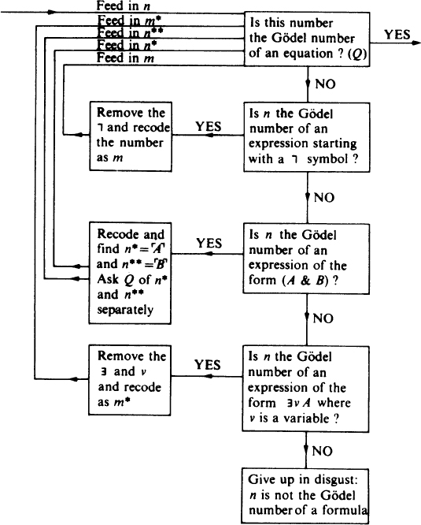

公式定义还有其他款，尚未处理，所以仍可能得到“否”。若一开始既非以 开头，也非等式，就可能是合取。此时再问：n 是否为形如 (A & B) 的表达式的哥德尔数？这里尚不假定 A、B 是公式，只当作符号序列。

But there are other clauses of the definition of a formula and these we have not yet treated. So we have the possibility of getting a NO. If, when we started, we did not start with a symbol or an equation, it is possible that we had a conjunction. So we now ask (that is if we are still getting a NO): Is *n* the Gödel number of an expression of the form (*A* **&** *Β*)? Here *A* and *B* are not assumed to be formulae, just sequences of symbols.

若确为此形式，就把 A、B 分别重新编码为 n*、n**。所谓重新编码，是指 n 原先以因子 2⁶ 开始，最后一个素数的指数为 7；现在取 A 所对应的指数重新编码为 n*，类似地由 B 得到 n**，分别记作 ⌈A⌉、⌈B⌉。它们都小于原数。再分别对 n*、n** 提问 Q：它们是否为公式的哥德尔数？若两者都是，就对整个问题回答“是”；只要一个为“否”，机器就回答“否”，原表达式不是合法公式。这就处理了“公式是否形如 (A & B)”的答案为“是”的情形。

If we do have an expression of this form, what we do is to take *A* and *B* and recode as *n** and *n*** respectively. When I say recode now, I mean that *n* would have started off with a 2<sup>6</sup> and ended up with a prime to the seventh power. We take the exponents corresponding to the things in *A* and recode them as *n**. Similarly we get *n*** from *B* and we shall write <sup>⌈</sup>*A*<sup>⌉</sup> for *n** and <sup>⌈</sup>*B*<sup>⌉</sup> for *n***. These will be smaller numbers than the one we started off with. And now we ask the question *Q* of *n** and of *n***. Is *n** the Gödel number of a formula? Is *n***? If they both come out as Gödel numbers of formulae then we give an answer to the whole question. If either comes out NO, then the machine says NO and we did not have a genuine formula. That finishes the case where we had the answer YES to the question: Did the formula look like (*A* **&** *B*)?

若答案不是“是”，还有最后一招：问 n 是否编码一个以 开头、后接变量、再接符号串 A 的表达式。若是，就去掉 和变量，把 A 重新编码后送回起点；若否，就只好放弃。仔细看，这台机器没有悬而未决的分支：每阶段都有“是”或“否”，无论走哪条路，最终都会得到答案。即使要检查 n*、n** 等，数也不断变小，所以过程总会停止。

If we did not have the answer YES, we still have one more trick to try. And we ask: is *n* the Gödel number of an expression which starts off with an symbol followed by a variable and then a string of symbols which we shall refer to as *A*? If the answer is YES, then remove the and the variable and recode *A* and send it back to the beginning. If the answer is NO, we give up in disgust. If you look at this machine carefully you will see that there are no loose ends. We have a YES or a NO coming out of it at each of the stages, and no matter what way we go, we will end up with a YES or NO. And even if we have to look at *n**, *n***, etc. these numbers are getting smaller and smaller so the process will always stop eventually.

你可能问：判断某数是否编码表达式，与哥德尔不完备性定理有何关系？原来，所有检查某数是否为某类公式哥德尔数的机械装置，在某种意义上都能在算术中表示。它们有对应的算术公式，因此能在算术中证明与现实中发生的事情对应的结果。

Now you may say: What has all this business of being able to tell whether a certain number codes an expression got to do with Gödel’s Incompleteness Theorems? It turns out that all the mechanical devices which you can have for checking whether numbers are the Gödel numbers of certain sorts of formulae or not are in a certain sense representable in arithmetic. These devices have corresponding formulae in arithmetic, so we can actually prove in arithmetic a result corresponding to what is happening in the real world.

接下来的论证本质上类似说谎者悖论，至少受它启发，不过会放在稍不熟悉的背景下。我们将构造一个实际上说“我不可证明”的公式。由于将证明它不可证明，它便为真：得到算术中一个为真却不可证明的公式。根据前述内容，已经几乎可以在算术中写出对应于通常、或说真正自然数上关系的公式。到目前为止，其实一直在讨论某些谓词是递归的。刚才已详细说明，“是本算术语言中某公式的哥德尔数”这一概念是递归的，即可计算：存在机械过程判定任意给定数是否为本语言中公式的哥德尔数。

The argument that I shall produce is essentially an analogue of the Liar Paradox, or at least is suggested by the Liar Paradox, although I shall present it in a slightly unfamiliar context. What we are going to do is produce a formula which says in effect ‘I am not provable’. By virtue of the fact that we shall show that this formula is not provable, it will turn out that it is true. We shall have a formula in arithmetic which is true but not provable. Now from what I have already said we are almost at the stage of writing down in arithmetic some formulae corresponding to relations on ordinary (genuine if you like) natural numbers. I have in fact so far been talking about particular predicates being recursive. I have just gone to some lengths to show that the notion of being the Gödel number of a formula in our language of arithmetic is recursive: it is computable. We have a mechanical procedure for deciding whether a particular number is the Gödel number of a formula in this language or not.

还没有提到，也可以编码公式序列。方法与编码符号序列相同：把 φ₁、φ₂、φ₃ 编码为 2^⌈φ₁⌉·3^⌈φ₂⌉·5^⌈φ₃⌉，其中 ⌈φ₁⌉ 是 φ₁ 的哥德尔数，其他类似。采用何种编码几乎无关紧要，只要有效：给定一个数，首先能判定它是序列编码还是公式编码，其次能确定该序列具体由什么组成。

I have not yet mentioned that we can code sequences of formulae too. We do it in just the same way that we coded sequences of symbols. We code the sequence of formulae, say *φ*<sub>1</sub>, *φ*<sub>2</sub>, *φ*<sub>3</sub> as 2<sup>⌈*φ*<sub>1</sub>⌉</sup>.3<sup>⌈*φ*<sub>2</sub>⌉</sup>.5<sup>⌈*φ*<sub>3</sub>⌉</sup> where ⌈*φ*<sub>1</sub>⌉ is the Gödel number of the formula *φ*<sub>1</sub> and so on. It hardly matters what coding procedure you follow, so long as it works in the sense that, given a number, you can first of all tell whether it is the code of a sequence or whether it is the code of a formula and secondly you can tell of just what that sequence consists.

于是，说 n 是公式序列的哥德尔数就有意义了。证明是特殊的公式序列，因此考虑关系 Pf(x,y)：它为真，当且仅当 x 编码一个公式序列，而该序列构成哥德尔数为 y 的公式的证明。检查任意两数间 Pf(x,y) 是否成立，是机械、可计算的过程。回想第 13 页的定义：证明是公式序列，每个公式要么是公理，要么由序列中较早的公式按推理规则得到。既然能检查是否为公式，就能检查是否为公式序列。公理有可识别的形式，因此能判定某公式是否为公理实例；推理规则也很简单，只涉及对公式例行地“拆分”。这完全机械，所以 Pf(x,y) 可计算。以下把“递归”与“可计算”作为同义词，因此 Pf(x,y) 是递归谓词。一切可计算过程都可由图灵机完成，所以确实能构造图灵机，恰好判定 Pf(x,y) 是否成立。

Hence it now makes sense to say that *n* is the Gödel number of a sequence of formulae. Further, proofs are special sequences of formulae, so consider the relation *Pf*(*x*, *y*). *Pf*(*x*, *y*) is to be true only when *x* is the Gödel number of a sequence of formulae which constitutes a proof of the formula whose Gödel number is *y*. Now to check whether *Pf*(*x*, *y*) holds between any two numbers is a mechanical (computable) procedure. You may recall the way we defined proof of a particular formula (*see* p. 13): a proof is a sequence of formulae (and we can check whether a thing is a formula, so we can check whether we have a sequence of formulae) such that each formula is either an axiom or else is obtained from earlier formulae in the sequence by the rule of inference. Now we can tell whether a formula is an instance of an axiom or not, because the axioms are given in a recognizable form. Also the rule is very simple: all that is involved is a routine ‘chopping up’ of the formulae given. This is a purely mechanical thing, so the predicate *Pf*(*x*, *y*) is computable. Now I shall use recursive and computable as synonyms, so in other words *Pf*(*x*, *y*) is recursive. All computable procedures can be performed by Turing machines, so we can actually construct a Turing machine which will do exactly what we want it to do here, that is, decide whether *Pf*(*x*, *y*) holds.

递归谓词有一种很特殊的性质：它们恰好就是下述意义下可表示的谓词。用 表示 n 的数码，因此 是 s(s(0))。设自然数之间有关系 R(m,n)。若存在算术公式 R(x,y)，满足下列条件，就称关系 R(m,n) 在算术中可表示，以下省去“在算术中”一语：

Recursive predicates have a very special property: they are exactly the ones which are representable in the following sense. Let us write for the numeral for *n* so is *s*(*s*(0)). Suppose we have a relation between natural numbers *R*(*m*, *n*); then I shall say that *R*(*m*, *n*) is representable in arithmetic (and from now on I shall drop the phrase ‘in arithmetic’) if there is a formula of arithmetic R(*x*, *y*) such that

(i) 若 R(m,n) 为真，则 。（说 R(m,n) 没有意义，因为 m、n 不是数码。）

(i) If *R*(*m*, *n*) is true then . (It makes no sense to say that R(*m*, *n*) because *m*, *n* are not numerals.)

(ii) 若 R(m,n) 为假，则 。

(ii) If *R*(*m*, *n*) is false then .

（这里关系有两个自变量 x、y；实际上可有从零开始的任意多个，视所考虑关系而定。）有趣的是，有些关系没有这种性质。这实际上正是哥德尔第一不完备性定理的核心：找到为真的东西，但它及其否定都不可证明。

(In this relation there are two arguments *x*, *y*; in fact there could be any number from zero upwards depending on the relation we are considering.) The interesting point is that there are relations that do not have this property. In fact this is the essence of Gödel’s First Incompleteness Theorem. We find something which is true, but neither it nor its negation is provable.

有些关系可表示，这很容易看出。相等关系由公式 x = y 表示，因为若 m 等于 n，则 ，即 s……（m 次）……s0 = s……（n 次）……s0。由说 0 = sx 等的公理，可以证明 是系统定理，证明相当初等。若 m 不等于 n，则有 。

It is very easy to see that some relations are representable. The relation of equality is representable by the formula *x* = *y* because if *m* equals *n* then (i.e. *s* ... (*m* times) ... *s*0 = *s* ...(*n* times) ... *s*0). We can prove that is a theorem of our system from the axioms which say 0 = *sx*, etc. The proofs are fairly elementary. Also we have that if *m* is not equal to *n* then .

再举一例。加法、乘法在系统中可表示，颇为明显，因为语言中已含加、乘符号。但整除也可表示：“m 整除 n”由公式 z(x × z = y) 表示。若 m 整除 n，就能在算术中证明 ；若不整除，就有 。事实上，可证明每个递归关系都可表示。下面只取两个特例，后一个比前一个复杂。

Now one more example. It is fairly obvious that addition and multiplication are representable in the system because we included plus and times as symbols in our language. But division is also representable, because the relation ‘m divides *n* is represented by the formula *z*(*x* × *z* = *y*). If *m* divides *n* then in arithmetic we can prove and if *m* does not divide *n* then we have . In fact one can show that every recursive relation is representable. We shall take just two special cases, one more complicated than the other.

考虑关系 Pf(x,y)：它成立，当且仅当 x 是哥德尔数为 y 的公式的某个证明的哥德尔数。于是存在算术公式 Pf(x,y)，使得若 Pf(m,n) 为真，就能在算术中证明 。若 m 不是哥德尔数为 n 的公式的证明编码，甚至 n 根本不是公式编码，这也完全可能，则能证明 。原因是该关系递归，而所有递归关系都可表示。注意，若能证明 ，则 m 确实是哥德尔数为 n 的公式的证明编码；否则就会有 ，产生矛盾。现在看更复杂的关系 Pf⁺(x,y,z)，其表示公式本质上给出对角化公式。（加上标 +，以免与前一关系混淆。）它成立，当且仅当 y 是恰有一个自由变量的公式的哥德尔数，而 x 编码的证明并非证明原公式，而是证明它的一个小变体：把数 z 的数码，即 ，代入该自由变量所得的公式。这仍是递归谓词，因为给定 x、y、z，当然能判定 y 是否为公式编码，写出公式后，也能判定它是否恰有一个自由变量。若否，谓词为假；若是，就检查 x 是否编码某个证明，而该证明的结论是把适当的 z 个 s、一个 0 及适当括号代入原公式自由变量后所得的公式。整个检查都可机械完成。

Consider the relation *Pf*(*x*, *y*) which holds only when *x* is the Gödel number of a proof of the formula whose Gödel number is *y*. Then there is a formula *Pf*(*x*, *y*) in arithmetic such that if *Pf*(*m*, *n*) is true, we can actually prove in arithmetic the formula . And if *m* is not the Gödel number of a proof of the formula with Gödel number *n* (or indeed if *n* is not the Gödel number of a formula at all, which is quite possible), then we can prove . The reason we can do this is that this relation is recursive, and I already said that all recursive relations are representable. Let us observe that if we can prove then *m* really is the Gödel number of a proof of the formula with Gödel number n, because if this were not so, then we would have and thus a contradiction. Now for the more complicated relation *Pf*<sup>+</sup>(*x*, *y*, *z*). Its representing formula gives us essentially the diagonalizing formula. (I put a superscript <sup>+</sup> on it, so that we shall not confuse it with the previous relation.) The relation is to hold only when *y* is the Gödel number of a formula with just one free variable and *x* is the Gödel number of a proof not of the formula whose Gödel number is *y*, but of a slight variant of it, namely the formula that results when the numeral for *z* (that is ) has been substituted for the free variable in the formula. This again is a recursive predicate, because if you are given the three numbers *x*, *y*, *z* you can certainly decide whether *y* is the Gödel number of a formula, and if you write that formula out, then you can decide whether it has one free variable or not. If it does not, then the predicate is false. If it does, then we go to the next stage and we look at the number *x*. We check mechanically as to whether it is the Gödel number of a proof of the formula that we have just found when we have made a certain substitution in that formula, namely when we have put an appropriate string of *s*’s (*z* of them) followed by 0 and appropriate brackets instead of the free variable in the formula that we are talking about.

若 x 是这样的数，关系为真；否则不成立。因此显然是机械过程。一切可机械检查的公式都可表示，所以 Pf⁺(x,y,z) 可表示。把表示它的公式也写作 Pf⁺(x,y,z)。

If *x* is such a number then the relation is true and if it is not, then the relation does not hold. So it is obviously a mechanical procedure. But all mechanically checkable formulae are representable, so *Pf*<sup>+</sup>(*x*, *y*, *z*) is representable. I shall write **Pf**<sup>+</sup>(*x*, *y*, *z*) for the formula which represents it.

现在考虑这样的公式：x 是某个公式证明的哥德尔数，而该公式由把原公式自身哥德尔数的数码代入自由变量得到。这与第 1 章枚举实数时改变第 n 个小数第 n 位的对角线论证很相似。这里取第 y 个公式，把 ȳ 代入它。公式 x Pf⁺(x,y,y) 只有一个自由变量 y。设其哥德尔数为 g，公式本身称为 G。现在把 G 的哥德尔数的数码代入 G 的自由变量，即以 替换 y。自由变量出现两次，所以要代入两次。要证明，所得公式及其否定都不能在算术中证明。先看它说什么：所谓“说什么”，实际上是回到公式所对应的关系。非形式地读，它说不存在数 x，使 x 编码某个公式的证明，而该公式由把数 g 的数码代入哥德尔数为 g 的公式（即 x Pf(x,y,y)）唯一自由变量 y 而得。换言之，把 g 的数码代入自由变量 y 后，所得公式没有证明。但所得公式正是这里所说的 G 本身。因此 G 说：“公式 G 没有证明。”若竟能证明它，反而令人惊讶；事实上不能，下面就来说明。

Now let us consider the formula which says that *x* is the Gödel number of a proof of the formula that you get when you put in for its free variable the numeral for its own Gödel number. And this is very similar to the diagonal argument from the first chapter where you are enumerating the real numbers and in the *n*th decimal you change the nth decimal place. Here we have got the *y*th formula and we are putting in *ȳ* in the *y*th formula. The formula *x* **Pf**<sup>+</sup> (*x*, *y*, *y*) has one free variable, namely *y*. It has a Gödel number and let us call its Gödel number *g*. I call the formula itself *G*. Now let us substitute for the free variable *y* in *G* the numeral for *G*’s Gödel number; that is substitute for *y*. The free variable appears twice, so we have to put *g* in twice. What I want to show is that neither this formula nor its negation can be proved in arithmetic. Let us consider for a moment what this formula says. When I say: ‘What this formula says’ I really mean: let us go back to the relation which this formula corresponds to. Reading it informally it says that it is not the case that there is a number *x* such that *x* is the Gödel number of a proof of the formula with Gödel number *g* (which is just the formula *x* **Pf**(*x*, *y*, *y*) when for the single free variable *y* in it we have substituted the numeral for the number *g*). In other words, there is no proof of this formula when we have put the numeral for *g* in place of the free variable *y*. But the resultant formula is exactly the formula *G* itself. So what the formula *G* says is: there is no proof of formula *G*. So it would be somewhat surprising if we could prove that formula, and indeed we cannot. This is what I shall now proceed to show.

首先假设能证明 G，即假设 。若能证明，就存在证明，设其哥德尔数为 m。于是 m 编码一个证明，结论是把数码 代入哥德尔数为 g 的公式自由变量后所得的公式。因此 Pf⁺(m,g,g) 为真。由于关系 Pf⁺(x,y,z) 在算术中由同名公式表示，就能证明对应公式 。再用初等谓词演算，推出 。但已假定算术一致，因此产生矛盾。故原假设错误， 不可证明。

另一方面，假设能证明这个公式的否定，即能证明 。双重否定相互“抵消”，所以能证明 。然而刚才已证明 不可证明。既然没有证明，就没有任何数是其证明的哥德尔数：0 不是 G 的证明编码，1 不是，依此类推。也就是说，Pf⁺(0,g,g) 不成立，Pf⁺(1,g,g) 不成立，等等；这些关系全为假。

既然全为假，由 Pf⁺(x,y,y) 可表示，对每个数 n，都能证明 的否定。若对每个 n 都能如此，却还能证明 ，就极不合理，稍后再谈。这意味着不能证明 ，但刚才假设能证明，所以也不可能。至此，公式及其否定都不可证明。如前所述，这个公式说“我不可证明”，因此其解释确实为真：它不可证明。这样就在两种意义下建立了哥德尔不完备性定理。较强的意义是：存在一个公式，它及其否定都不可证明。较弱的意义是其推论：存在算术中为真却不可证明的公式。

本章最后，就各种形式的一致性作几点说明。一直假定算术一致，而且有充分理由：日常所用的普通算术显然满足这些公理，所以公理为真，证明规则又保持真，因此一切可证明的东西都为真，不会不一致。不过，上面的论证用到稍微更精细的一致性：从对每个 n 都有 ，推断不可能有 。因此在证明该处应注明，假定的是所谓 ω 一致性，这里的 ω 指自然数全体。若形式系统对每个自然数 n 都含其记号或数码 ，且每当对所有自然数 n 都能证明 A()，其中 A 为任意公式，就不能再证明 x A(x)，便称系统 ω 一致。这是很合理的假定。令 A 为 x = x 这样简单的公式，就可看出 ω 一致蕴涵通常意义的一致，但反之不成立：系统可能一致却不 ω 一致。为求完整，补充下一点：可以强化 Pf⁺(x,y,z) 的定义，免除 ω 一致性的条件，这一结果归于巴克利·罗瑟。

I conclude this chapter with one or two remarks concerned with consistency in one shape or another. We have been assuming all along that arithmetic is consistent and we have very good reason for doing that. Namely that the ordinary arithmetic that we deal with in day-to-day life obviously satisfies the axioms that we have, so these axioms are true and we know the rules of proof preserve truth. So therefore all the things that we can prove are true, so we cannot have an inconsistency. However, we invoked a slightly subtler form of consistency in the above argument. From having for each number *n* we concluded we could not have . So you might like to put in a remark at this stage of the proof that we are assuming (what is known in the trade as) *ω*-consistency. (Here *ω* just refers to the totality of the natural numbers.) We say that a formal system containing, for each natural number n, a notation (or numeral) for that number, is *ω*-consistent if whenever we can prove *A*() (where *A* is just some formula) for each natural number *n*, it is not the case that there is something else lurking about which enables us to get a proof *of* *x* *A*(*x*). I think you will admit this is a very reasonable thing to assume. If you take this formula *A* just to say something simple like *x* = *x* then it is clear that if a system is *ω*-consistent, then it is consistent in the usual sense. But the converse is not true. We can have systems which are consistent but which are not *ω*-consistent. I only put this in for thoroughness, as I do the next remark also. It is possible to soup up the definition of the formula *Pf*<sup>+</sup>(*x*, *y*, *z*) so that the condition of *ω*-consistency can be dispensed with. This result is due to Barkley Rosser.

前面考虑的公式说，x Pf⁺(x,g,g) 并不成立。罗瑟的修改是：若 x 是那个复杂公式 的哥德尔数，则存在更小的数，它编码该公式否定的证明。可以想象，解释这个公式会更繁琐，但论证方式与前面十分相似。

We considered a formula which says it is not the case that *x* *Pf*<sup>+</sup>(*x*, *g*, *g*) and the modification that Rosser produced was to say if *x* is the Gödel number of the ghastly formula then there exists a smaller number which is a proof of the negation of that very same formula. And as you can imagine the explanation of the formula gets a little bit more tedious, but the argument goes through in a very similar vein to the one I have given.

最后谈哥德尔第二不完备性定理。它不仅涉及系统中的可证明性，也涉及其界限。定理说：算术的一致性不能在算术中证明。这里仍指本章的形式算术。0 = 1 与“0 不是任何数的后继”这一公理矛盾，因此若能证明它，系统就不一致；反过来，系统不一致就能证明它。所以无法证明它等价于一致性。设该公式的哥德尔数为 k，考虑公式 。其解释是：对所有 x，x 都不是哥德尔数为 k 的公式的证明编码，即公式 没有证明。这就是对 的读法，把这个公式命名为 Consis。下一步并不容易，事实上颇困难，但主要是例行的形式化工作：把前面的全部论证在形式算术中形式化，就能证明 (Consis → G)，即有 (Consis → G)。（回想 G 是公式 。）前面的论证完全采用有穷方式，因此能把它全部放入算术，得到 (Consis → G) 可证明。若现在还能在算术中证明断言算术一致的公式，即有 Consis，则由分离规则可证明 G。但已表明这不可能。因此，不能在算术内部证明算术自身的一致性。

Now I want to make one final remark. I want to talk about Gödel’s Second Incompleteness Theorem. This requires not only talking about provability in the system, but, shall we say, the limits of provability in the system. Gödel’s Second Incompleteness Theorem is the following: the consistency of arithmetic is not provable in arithmetic. And by arithmetic I mean formal arithmetic as I have always done in the course of this chapter. If you take 0 = 1, then that gives you a contradiction with the axiom which says that 0 is not the successor of any number. So if we prove this formula, we shall have an inconsistent system, and if we had an inconsistent system we could prove this formula. So not being able to prove this formula is equivalent to having consistency. Now this formula has a certain number. Let this number be *k*. Then let us consider the formula . What does it say? Its interpretation is that for all *x*, it is not the case that *x* is the Gödel number of a proof of the formula with Gödel number *k*. In other words, it says that there is no proof of the formula . This is how I shall read . So let *Consis* be a name for this formula. Now I shall not say that what we do next is easy to show, because it is quite difficult. But it is more a matter of routine than anything else. What we can actually do is take all the argument which I have been presenting and formalize that. We formalize our previous argument in formal arithmetic and we can prove the formula (*Consis* → *G*), that is to say we have (*Consis* → *G*). (Recall that *G* is the formula .) We take all our previous argument and put all that too within arithmetic. Everything was done in a very finitistic manner and so we can get that (*Consis* → *G*) is provable. But now if we could prove in arithmetic the formula which asserts the consistency of arithmetic, if we had *Consis*, then (by *modus ponens*) we could prove our formula *G*. We have shown that this is impossible. So it must be false that we can prove the consistency of arithmetic within arithmetic.

这就是哥德尔第二不完备性定理：算术不足以证明自身一致。实际上，算术的任何扩张也有同样缺陷，所以无法指望用一个形式化全部数学的系统证明全部数学的一致性。要获得一致性证明，必须进入更大的系统，而这需要超出作为公理模式引入的普通数学归纳法；所需的是超限归纳法，直到一个并不很大的序数。利用直到所谓第一个 ε 数的超限归纳法，可以直接得到算术的一致性证明。

So that is what Gödel’s Second Incompleteness Theorem says. Arithmetic is not sufficient to prove its own consistency. And indeed any extension of arithmetic has this same deficiency, so there is no hope of proving the consistency of all mathematics from a formal system for all mathematics. In order to get consistency we have to go into a bigger system and this system requires more than the ordinary mathematical induction which we introduced as an axiom scheme; what is required is called transfinite induction (up to a not very large ordinal number). We can give a consistency proof for arithmetic as a direct result of transfinite induction up to the first epsilon number, as it is called.

下一章将讨论更大的系统，即集合论系统。不过集合论包含算术，所以也有同样缺陷。其中同样出现一致性问题；由于哥德尔不完备性定理使我们无法指望绝对一致性证明，将会看到，我们主要关心相对一致性，而非绝对一致性。

In the next chapter, bigger systems, systems of set theory, will be considered. However, set theory contains arithmetic, and so has the same deficiency. Consistency problems arise there and you will see that we are very much concerned with relative consistency rather than absolute consistency for the reason that we cannot ever hope for absolute consistency because of Gödel’s Incompleteness Theorems.

## 6. 集合论

## 6. **Set Theory**

在这最后一章，我将讨论集合论。想必大家对集合都有自己的图景，大致认为它是某些东西的汇集。首先说明若干集合公理，也就是大多数数学家都同意对集合成立的公理。

IN this last chapter, I am going to discuss set theory. Probably you all have some sort of picture of your own, some rough idea of what a set is: a sort of collection of things. I shall start by explaining a number of axioms for sets; the axioms that most mathematicians agree are true about sets.

这里的讨论十分非形式化，不过说到底，公理集合论确实是本书前面所描述的那类形式理论。它以带等词的谓词演算为基础，另加一个表示集合隶属关系的谓词符号 ∈。写作 x ∈ y，读作“x 是 y 的元素”。下面给出的全部公理都能用这种语言适当地写出。所得的特定形式系统称为 ZF，即策梅洛—弗兰克尔集合论。

I shall do this very informally, though when you come to the crux of the matter, Axiomatic Set Theory is really a formal theory of the type that has been described earlier in this book. It is based on the predicate calculus with equality, with the one additional predicate symbol ∈ for set membership. I shall write *x* ∈ *y*, and read it as ‘*x* is a member of *y*’. All the axioms which I shall give can be written out appropriately in this language. The particular formal system that results is called ZF, for Zermelo-Fraenkel set theory.

我们相信哪些公理成立？首先，对集合有怎样的图景？起初大概只能说：集合是数学对象的汇集。暂时无法说得更精确。由此首先想到可能成立的原则如下：设有任意适用于集合的性质，则具有这种性质的所有东西构成一个集合。因此得到原则：(P) 对任意性质 ψ(x)，存在集合 y，使得

What sort of axioms do we believe are true? What sort of picture do we have of sets first of all? I suppose that the best we can say to start with is this: sets are collections of mathematical objects. And to start with I cannot be very much more precise. The first principle that this leads me to suspect may be true is the following. Suppose that I have any property that applies to sets. Then there is the set of all things with this property. Thus we have the principle: (*P*) For any property *ψ*(*x*), there is a set *y* such that

Now in fact this principle is not correct, for from it we can derive Russell’s Paradox (found by Russell in about 1902). Apply (*P*) to the property *x* ∉ *x* there must be a set *R* such that

So *R* is the set of all sets which are not members of themselves. If you come to this set *R*, and ask it the question: ‘Do you belong to *R*?’ the set is rather embarrassed and does not know how to answer, because *R* belongs to *R* exactly when it does not:

这一点很容易检验。

as you may check easily.

罗素悖论确实出现，正是我们需要认真建立集合理论的原因。若原则 (P) 成立，就几乎不必再说什么。但罗素竟能从这条起初看似无害的公理推出矛盾，说明必须仔细审视对集合的直观认识，事情并不像最初那样显然。

The fact that Russell’s paradox does occur is the reason why we need to bother with a theory of sets at all. If the principle (*P*) were true, then there would be little else that we need say. But the fact that Russell could derive his contradiction from this first innocent sort of an axiom shows us that we have to look rather carefully at our intuitive view of a set. It is not quite as obvious as it first seemed to us.

要更清楚哪些东西应当是集合，必须分析原则 (P) 错在哪里。为什么罗素的那个汇集不是集合？原来，因为想加入其中的东西太多了。R 这个汇集实在太大，不能成为集合。因此根据这一经验，把直观认识略作修改：集合是一个不太大的汇集。

To get a slightly better idea of what sort of things should be sets, one must analyse where the principle (*P*) goes wrong. Why is the Russell collection not a set? It turns out that it is not a set because there are too many things that want to be in it. *R* is just too big a collection of things to be a set. So in the light of this experience we shall modify slightly our intuitive view of a set to the following: a set is a not-too-big collection of things.

下面的公理就是试图把这种认识表达出来。

And the axioms that I shall write down are axioms that try to capture this view.

For the first one, let us dispose of equals, that is, let us get the connection between ∈ and = in our formal theory. It follows at once from the axioms for equality that if two sets are equal, then they have the same members. Now the only thing that I have in my hands for distinguishing between sets is the membership relation. So if two sets have exactly the same members, then I cannot distinguish between them, in other words, they are equal. And this is what the first axiom is going to say. This is the Axiom of Extensionality,

下一条公理试着从最初的集合构造原则 (P) 中挽救可保留的部分。不再汇集所有具有某性质的集合，而从一个给定集合出发，只汇集其中具有该性质的元素，想来应当无害。这很合理，因为至多只是缩小已有集合的规模，不该得到太大的东西！由此得到概括公理模式。在形式系统中必须把它写成模式，因为对每个性质，都要断言某个集合存在。所谓性质是什么？在形式系统中没有疑问，它就是含一个自由变量的公式。因此，概括公理模式如下：

In the next axiom let us rescue what we can from the set-building principle (*P*) that we had to start with. Certainly there ought not to be any harm if instead of trying to collect together all the sets that have some property, we start with a given set and collect together just the members of that set which have the property in question. This seems reasonable because, if anything, this is cutting down the size of a set that we have already got, and that should not come to something that is too big! This leads to the Comprehension Schema. When I try to write it in the formal system it has to be a schema. For each property I have to say that a particular set exists. Now what do I mean by property? If you think of a formal system, there is no question of what a property is. It is really a formula with one free variable. So the Comprehension Schema is the following:

给定任意集合 a，以及以 x 为自由变量的任意公式 ψ(x)，其中也可有其他自由变量，这无妨，则存在集合 b，其元素恰好是 a 中具有性质 ψ 的元素，即

Given any set a, and given any formula *ψ*(*x*) in which *x* is a free variable (there may be other free variables as well, they do not bother us), then there is a set *b* such that the members of *b* are exactly those members of *a* which have the property *ψ*, that is

It follows from the Axiom of Extensionality that this set *b* is the unique set with this property. I shall write

这个模式尽可能保留了最初那个本身不够妥当的直观原则。

This schema captures as much as we can of the first intuitive principle which was not quite good enough in itself.

还能构造什么？既有两个集合，当然应能构成恰以这两个集合为元素的集合。这就是配对公理：给定集合 x、y，存在另一个集合，恰以 x、y 为元素。把它记作 {x,y}。

What else can we construct? If we have got two sets, surely we can form a set that has exactly these two sets as members. This is the Pair Set Axiom: given two sets *x*, *y* there is another set which has exactly *x* and *y* as members. I write this new set as {*x*, *y*}.

下一条是幂集公理。给定集合，可以考虑它的所有可能子集。这大概是更大的汇集，但也不会大得过分，把它看作集合是合理的。于是得到幂集公理：给定任意集合 x，x 的幂集仍是集合。x 的幂集是 x 的所有子集 y 的汇集：Px = {y : y ⊆ x}。（y ⊆ x 表示 y 是 x 的子集，即 y 的所有元素都是 x 的元素。）

Now the next thing, the Power Set Axiom. If I have a set, then I can think of all possible subsets of this set. It is probably going to be a larger collection, but not so terribly much larger. It is reasonable to think of this as giving us back a set. This leads to the Power Set Axiom: if I am given any set *x*, then the power set of *x* is again a set. The power set of *x* is the collection of those sets *y* which are subsets of *x*: *Px* = {*y*:*y* ⊆ *x*}. (I write *y* ⊆ *x* to mean that *y* is a subset of *x*: all members of *y* are members of *x*.)

下一条公理涉及集合 x 的并集。先取集合 x，可以画一个圆表示它，把元素画在里面。但这些元素是什么？它们本身必定也是集合，因此

The next axiom is concerned with the union set of a set *x*. Take a set *x* to start with. We can think of *x* as being represented by a circle, with its members inside: But what are these members? They must themselves be sets, and so

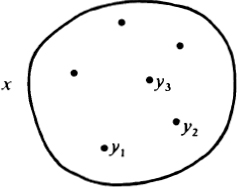

它们自身也有元素，可用同样方式表示，图中只画了其中几个。

they themselves have members, so I can represent them in the same way (I have drawn only a few of them).

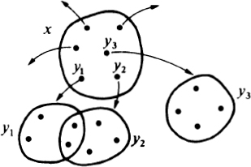

创立集合论的一个原因，是为了谈论无限多个对象的汇集。因此最好有公理断言这类集合存在。这就是无穷公理：存在无限集。

One of the reasons for inventing set theory is to enable us to talk about a collection of infinitely many objects. So we had better have an axiom to say that there are sets of this sort. This is the Axiom of Infinity: there is an infinite set.

Now that we know that there is a set (indeed, an infinite one), we can prove that there is a set which has no members at all. Let *ω*, say, be an infinite set, as provided by the Axiom of Infinity. Consider the following set ∅, which the Comprehension Schema asserts to exist:

由于对所有集合 x 都有 x = x，所以 ∅ 没有任何元素。事实上，∅ 是唯一具有此性质的集合，称为空集。

Since *x* = *x* for all sets *x*, it follows that ∅ can have no members. In fact, ∅ is the unique set with this property. We call ∅ the empty set, or the null set.

下一条公理与前面那些逐步构造集合的公理不太一样。回想谈论集合 x 的并集时的图景：从 x 出发，考虑其元素，并把它们画出来。这些集合自身也有元素，取其中一个，它同样是集合，也可考虑它的元素。再取其中一个元素，又可重复同样的事。这何时才会停止？能否

The next axiom that I want to go on to is not quite the same building-up sort of axiom that we have had so far. Consider the picture that I had when I was talking about the union of a set *x*. I started off with a set *x* and said: think of the members. If I think of the members, I can draw them out. These sets have members themselves. Let me take one of these. This is equally well a set, so I can think of it having members too. Now if I take one of the members of this set I can do the same thing again. When is this going to stop? Can I

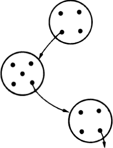

就这样永远继续？我对集合的直观认识当然不允许这样无限向下。因此引入一条公理：每当沿元素链向下追索，都必须在某个有限阶段停止。可这样理解：有集合序列 x₁、x₂、x₃、……，每个都是前一个的元素，即 ……∈ x₃ ∈ x₂ ∈ x₁，称为下降隶属链。于是基础公理，又称正则公理，说：任何下降隶属链都是有限的。

just keep on doing this forever? My intuitive view of a set certainly does not allow us to go infinitely far downwards like that. So let me make an axiom that says: whenever I try to chase down a chain of members, it must stop at some finite stage. You can think of it this way: we have a string of sets *x*<sub>1</sub>, *x*<sub>2</sub>, *x*<sub>3</sub>, ... where each is a member of the preceding one, that is ... ∈ *x*<sub>3</sub> ∈ *x*<sub>2</sub> ∈ *x*<sub>1</sub>. This we shall call a descending membership chain. Then the axiom, the Axiom of Foundation (or of Regularity) is this: any descending membership chain is finite.

由此可证明，集合 x 绝不会以自身为元素。反设有 x ∈ x，考虑全由 x 构成的无限序列 x、x、x、……，便得到无限下降隶属链 ……∈ x ∈ x ∈ x。但公理说这种链不存在，产生矛盾。因此，对所有集合 x 都有 x ∉ x。

Using this axiom, we can show that never is it the case that a set *x* is a member of itself. For suppose, on the contrary, that you had a set *x* such that *x* ∈ *x*. Think of an infinite string of sets, all of them being *x*, thus *x*, *x*, *x*, .... Then we get the infinite descending membership chain ... ∈ *x* ∈ *x* ∈ *x*. But the axiom says that there are no such chains, and we have derived a contradiction. This shows that *x* ∉ *x* for all sets *x*.

下一条公理真正表达前面试图说明的事实：任何不太大的集合汇集，本身也是集合。它将精确说明“不太大”的含义，即任何规模为集合的集合汇集都是集合。怎样用集合论语言表述？从给定集合 a 出发，让 a 的每个元素对应另一个集合，再断言全部对应对象的汇集仍是集合。可用形式语言中至少以 u、v 为自由变量的公式 ψ(u,v) 表达对应关系，使 v 对应于 u。由于每个 u 只应对应一个集合，ψ 必须有如下函数性质：

The next axiom that I want to go on to is the one that really captures the fact that I tried to suggest before, that any not-too-large collection of sets is itself a set. It is going to make quite precise what not-too-large means. It is going to say exactly that any set-sized collection of sets is a set. Now how can we phrase this in set-theoretic language? We want to start off with a given set *a*, and make another set correspond to each element of *a*. Then we shall assert that the collection of all the corresponding things is again a set. I can talk about a correspondence by means of a formula *ψ*(*u*, *v*) of the formal language, with (at least) the variables *u* and *v* free, *ψ* is to make *v* correspond to w, and since I want each *u* to have just one set corresponding to it, *ψ* must have the function-like property:

因此，这条公理仍是模式：每个具有函数性质的公式对应一条公理。模式如下：给定具有函数性质的公式 ψ(u,v) 和集合 a，存在集合 b，其元素恰好是通过 ψ 对应于 a 中某个元素 u 的那些集合 v，即

Thus the axiom will again be a schema: there will be one axiom for each function-like formula. So the schema is this: given a function-like formula *ψ*(*u*, *v*) and a set *a*, there is a set *b* such that the members of *b* are exactly those sets *v* which correspond under *ψ* to some set *u* belonging to *a*, that is

这称为替换公理模式：把 a 中的集合 u 替换为相应的集合 v。它真正表达了规模为集合的集合汇集仍是集合。事实上，有了它，就可删去概括公理模式，因为后者是替换公理模式的推论。不过，所列某些公理能由其他公理推出，我一点也不介意。

This is called the Replacement Schema: it replaces these sets *u* in *a* by the corresponding sets *v*. It is this schema which really captures the fact that set-sized collections of sets give us back sets. And in fact once we have this, we can throw out the Comprehension Schema because it comes as a consequence of the Replacement Schema. But I am not the least bit worried about the fact that some of the things I am listing can be deduced from other ones.

现在只差一条公理就列完 ZF 的公理。把它与其他公理分开，因为从事通常数学的数学家都接受前面那些公理适用于所研究的集合，而对即将提到的这一条，有些人稍有疑虑。这就是选择公理，也称罗素的乘法公理。它说：给定一个由非空集合构成的集合，可以从其中每个集合各选一个元素，再把所选元素汇成一个集合。

Now there is only one more axiom that I need to complete the list of axioms of ZF. Let us keep it separate from the rest, for, whereas all mathematicians working in conventional mathematics accept the others as being true of the sets with which they work, some people are a little more dubious about the one that I am about to mention. This one is the Axiom of Choice, Russell’s Multiplicative Axiom. This one says that if I have a set of non-empty sets, then I can choose one member from each set in this collection and put the chosen elements together into a set.

进一步讨论前，先把它改写成更数学化的形式。注意，凭现有公理，已能表达普通数学中想表达的一切。例如可以谈论有序对。有序对 ⟨x,y⟩ 是由第一分量 x、第二分量 y 唯一确定的集合，意思是

Before I discuss this further axiom I shall put it in another form which is somewhat more mathematical. Let me observe that from the axioms that we have at this stage I can say all the things that one wants to say in ordinary mathematics. I can talk about ordered pairs, for instance. An ordered pair 〈*x*, *y*〉 is a set which is uniquely determined by its first component *x* and its second component *y*, in the sense that

可以定义一个满足此性质的集合 ⟨x,y⟩。（不妨想想集合 {{x},{x,y}}。）

It turns out that we can define a set 〈*x*, *y*〉 which has this property. (You may care to meditate upon the set {{*x*}, {*x*, *y*}}.)

有了有序对，就能精确定义数学函数。函数使一个集合的元素对应于另一个集合的元素。准确地说，在函数中放入有序对 ⟨x,y⟩，便建立 x 与 y 的对应。函数就是所有这些对应的 x、y 所构成的有序对的汇集。因此，函数是满足适当函数性质的有序对集合。

Now with this concept of ordered pair I can say precisely when a set is going to be a function, a mathematical function. A function makes the members of one set correspond to the members of another set. Now I can express this precisely: you make the correspondence between the *x*’s of one set and the *y*’s of another by having in the function the ordered pairs 〈*x*, *y*〉. And the functions can be just the collection of all such ordered pairs, the *x*’s and the *y*’s that correspond. So a function is a set of ordered pairs, with the right function property.

与选择公理更直接相关的是选择函数。若 x 是集合，则 x 上的选择函数是一个函数 f，使得对 x 的每个非空元素 y，都有 f(y) ∈ y。于是选择公理可表述为：对每个集合 x，都存在 x 上的选择函数。

More relevant to the Axiom of Choice, let me now say what a choice function is. If *x* is a set, then a choice function for *x* is a function *f* which has the property that whenever I have a non-empty element of *x*, say *y*, then *f* makes a member of *y* correspond to *y*. I can write it this way: if *y* ∈ *x* and *y* ≠ ∅, then *f* (*y*) ∈ *y*. So, if you like, the *f* chooses for us a member of each of the *y*’s. Such a thing I call a choice function for *x*: it chooses something from all the non-empty sets in *x*. Now I can express the Axiom of Choice rather more precisely: every set has a choice function.

暂且指出，为什么接受其他公理的人，有时对选择公理稍有疑虑。在我看来它是真的：有一族非空集合，当然可以从每个集合中选一个元素。早期集合论研究者觉得它如此显然，甚至没注意自己在使用它。后来仔细分析论证，才发现同时作出许多选择确实用到了某种原则。有人对它比对其他公理更怀疑，原因如下：回看其他公理所断言存在的集合，它们都给出具体构造。从集合 x 出发，断言另一个集合存在，并提供生成它的配方。选择公理却没这么明确：只说存在选择函数，却不说怎样得到它。正因如此，有些人更怀疑它。其实，从能证明哪些定理来看，拒绝选择公理的人是在限制自己：可以证明，若用选择公理能导出矛盾，则不用它也能导出矛盾。因此，若只担心会不会推出矛盾，使用选择公理并无害处。稍后将尝试概述其原因。

I am going to return to the Axiom of Choice later. For the moment, I think it is appropriate to point out why people who accept the rest of the axioms are sometimes a little more dubious about the Axiom of Choice. To me it is true. It is clear that if I have a collection of non-empty sets, certainly I can choose a member from each. And in fact people working in set theory at the beginning thought it was so true they did not even notice they were using it. However, when people analysed their arguments more closely later, they realized that there was a principle involved in being able to make a whole lot of choices. Now the reason some people are a little more dubious about this than the others is this: let us go back and look at the other axioms and the things that they say are sets. These axioms give us a concrete construction for sets. Given a set *x*, they say that there is another set, and they give the recipe for producing it. Now the Axiom of Choice is not quite as definite as that. All it says is: given a set there is a choice function, but it does not say how to get the choice function. And some people are a little more dubious of the Axiom of Choice for just that reason. In fact the people who deny the Axiom of Choice are really doing themselves a disservice when they are thinking about the theorems they can prove, in the following sense: one can show that, if one can derive a contradiction using the Axiom of Choice, then one in fact could have derived a contradiction without using the Axiom of Choice. So there is no harm in using the Axiom of Choice if you are just worried about deriving a contradiction or not. I shall try and outline how this happens later.

现在不妨用所列公理，先重新得到那些确凿的数学对象 0、1、2、3、4、……，再把它们扩展到无穷之外，进入超限领域。实际上将沿两条途径扩展，分别对应于数本来就有的两种用途。

Now I think it would be rather fun to use the axioms that we have listed and first of all recover those definitely mathematical objects 0, 1, 2, 3, 4, ... And then I would like to extend them out beyond infinity and go into the trans-finite with these numbers. And in fact I am going to extend them in two ways—two different ways concerned with the two different ways in which one uses numbers anyway.

先考虑数的一种用途：标明事物的顺序，第一、第二、第三，等等。比如到电影院买票，有好几个售票窗口，各有一条队伍，想找最短的队伍。做法是心中数出第一、第二、第三、……，把每条队伍与这个标准比较，选延伸得最短的一条。现在想象集合们在电影院外排队：一个可怜的集合来晚了，急忙赶来，也想知道哪条最短。它同样开始给各队的位置编号，第一、第二、第三、……。但集合太多，即使数完第一、第二、第三、……，后面仍有许多。把所有这些位置之后的那个位置称为第 ω 个；接下来是第 ω + 1 个、第 ω + 2 个，依此继续。该构造怎样的标准，才能让这个集合记在心里，用来给这种队伍的位置编号？既要记在心里，就应尽可能简单。因此要构造一条标准队伍，供每个集合与其他队伍比较。最简单的东西是什么？要知道谁在谁前面，两个集合间最简单的关系当然是隶属关系。因此试着建立由隶属关系排序的标准队伍：每个 y 属于紧接其后的那个对象。事实上，若只看 x 本身、不必查看前面所有对象，就能确定 x 的全部前驱，会很方便。因此要求所有前驱都属于 x，不仅紧前一个，而是前面的一切都属于 x。

The first things that I want to consider are the ordinal numbers. One can think of the ordinal numbers as counting off places in a queue. Suppose that you are going to the theatre and there are a number of ticket windows and queues of people at the ticket windows. You wish to know which is the shortest queue to get on. How do you decide? You number off the places in each queue, so there is a first place, second place, and third place in this one, a first, second, third, fourth, and fifth in the next one, and so on. In other words you compare each queue with a standard that you hold in your head. And you pick as the queue to get on the one that goes the shortest distance down your standard. Consider now how sets would find this. Think of a whole lot of sets lining up at the ticket offices outside a picture theatre. And if one poor set is a bit late, he comes rushing down and wants to know which is the best queue to get on, that is, which is the shortest queue. Now he would want to do something the same as we did above. He would want to start numbering off each queue. So he looks at a queue. He sees a first place, a second place, a third place, ..., and so on. However, there are so many sets that even when he has numbered first, second, third, ..., there are still a whole lot more sets in the queue. Let us call the place after all these the ω-th place. Then there is the place after that: the *ω* + 1st place. Then there would be the *ω* + 2nd place. And so on: it would keep on going. Now what can we construct as a standard for this set to carry in his head? He must be able to number off the places in a queue that goes on just like the one we have been talking about. If it is a standard that he can carry in his head, it must be the simplest possible sort of thing we can imagine. So I want to construct the standard queue that every set can carry in his head and can compare other ones against. Now let us think, what are the easiest things to use? He wants to know when one thing comes before another. What is the simplest relation that two sets can have? Surely the membership relation. Let us then try and build up a standard queue where things will be related by membership. So the standard will be a queue ordered by membership. A particular *y* will belong to the next thing after *y* in the queue. It is rather convenient, in fact, if we are able to determine all the predecessors of *x* in the standard queue, just by looking at *x* without having to look at all the things before it. So let us ask that alîthe predecessors should also belong to *x*. We have not only the thing immediately before, but everything before, belonging to *x*.

标准队伍的第一个对象是什么？从最简单的集合，即空集开始。按上述想法，空集之后应是什么？就是以它的全部前驱为元素的集合，而 ∅ 不是唯一前驱吗？所以应是唯一元素为 ∅ 的集合，即 {∅}。（两者差别很大：∅ 没有元素，{∅} 却恰有一个元素，就是 ∅。）{∅} 之后是什么？必须包含前面所有对象，所以包含 ∅ 和 {∅}，即 {∅,{∅}}。再后一个也包含此前一切，所以是 {∅,{∅},{∅,{∅}}}。再后一个是 {∅,{∅},{∅,{∅}},{∅,{∅},{∅,{∅}}}}。如此不断构造。可见，写起来已颇繁琐。

What should be our first thing in the standard queue? We should start with the simplest set there is, in other words, with the empty set. On the suggestion above, what should come next after the empty set? Just all its predecessors. And is ∅ not its only predecesser? So it should be the set whose only member is ∅, in other words {∅}. (Note that there is a big difference between these two objects, for ∅ has no members at all, but {∅} has exactly one member: it has ∅ as its member.) Now what is going to be next after {∅}? Because it has to have all earlier things in it, it has to have ∅ and {∅}. So this set is {∅, {∅}}· The one that comes after {∅, {∅}} should have all the earlier things in it. So it is {∅, {∅}, {∅, {∅}}}. And the next one is: {∅, {∅}, {∅, {∅}}, {∅, {∅}, {∅, {∅}}}· We keep building them up like that. As you can see, it is getting a little bit tedious to write these down.

因此需要简写。该叫什么？看看就有显然的建议：第一个没有元素，第二个有一个，第三个有两个，等等。索性把它们定义为零、一、二等。因此

So I want a shorthand for them. What should I call them? If you look at them, there is an obvious suggestion that comes out. The first has no members, the second one has one member, the third has two members, and so on. So let us actually define these as zero, one, two, etc. Thus

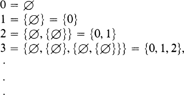

现在看：1 是唯一元素为零的集合；2 是元素为零和 1 的集合，依此类推。因此一般地，整数 n 是所有较小整数构成的集合：n = {0,1,2,3,…,n − 1}。于是可把自然数定义为特定集合；具体地，自然数 n 就取为全部较小自然数的集合。

Now look what happens. 1 is the set where the only member is zero. 2 is the set whose members are zero and 1, and so on. Thus we have in general that the integer *n* is the set of all the smaller integers: *n* = {0, 1, 2, 3, ..., *n* – 1}. Thus we can define the natural numbers to be particular sets; in fact we can take for the natural number *n* the set of all the smaller natural numbers.

回到标准队伍，自然数只是开头。因此它以 0、1、2、3、……开始。第 ω 个位置会怎样？0、1、2、3、4、……之后应接什么？说过，应是所有较早对象构成的集合。因此，第 ω 个位置的对象，索性称为 ω，就应包含 0、1、2、3、……，即 ω = {0,1,2,…}。第 ω + 1 个位置又怎样？

We must return to our standard queue again. The natural numbers are just the beginning of it. So the standard starts 0, 1, 2, 3, ... What is going to happen at the *ω*-th place? After 0, 1, 2, 3, 4, ... what should follow? We said it was to be the set of all the earlier things. So the thing that comes at the *ω*-th place, let me call it in fact *ω*, should just be the set that has in it 0, 1, 2, 3, ... So *ω* = {0, 1, 2, ...}. Now what happens at the *ω* + 1st place?

它必须包含前面所有对象。因此，第 ω + 1 个对象，不妨称为 ω + 1，应包含 0、1、2、……以及 ω，即 ω + 1 = {0,1,2,…,ω}。再走一步，ω + 2 是什么？有 ω + 2 = {0,1,2,3,…,ω,ω + 1}。如此便可构造一条标准队伍，让集合记在心中，借此为其他任何队伍编号。

It has to have in it all the things before. So the *ω* + 1st thing, which we might as well call *ω* + 1, should have in it 0, 1, 2, ... and *ω* too. So *ω* + 1 = {0, 1, 2, ..., *ω*}. Let us go just one step further at this stage. What is *ω* + 2? We shall have *ω* + 2 = {0, 1, 2, 3, ..., *ω*, *ω* + 1}. And in this way one can build up a standard sort of queue that a set can carry in its head and against which it can number off any other one.

以这种方式构造、进入标准队伍的集合，称为序数。以下用 α、β、γ、……表示序数。由构造方式，序数 α 恰以标准队伍中排在它前面的序数 β 为元素。因此，α 是序数，当且仅当 α = {β : β 是小于 α 的序数}。这些序数对后面的全部讨论都极为重要。

The sets that can be constructed in this way, that fall into the standard queue, are what are called the *ordinal numbers*. I shall use *α*, *β*, *γ*, ... in future for ordinal numbers. And from the way we have constructed them, it turns out that the ordinal number *α* is the set that has in it as members exactly these ordinal numbers *β* which are before a in the standard queue. So we have: a is an ordinal exactly when *α* = {*β*:*β* is a smaller ordinal than *α*}. The ordinal numbers that we get in this way are going to be very important for all that we do from now on.

现在考虑把自然数扩展到超限的另一方式，即基数。每个集合恰好关联一个基数，告诉我们集合的大小，也就是有多少元素。

Now I start considering another way of extending the natural numbers into the transfinite. I shall deal with the *cardinal numbers*. Each set has associated with it exactly one cardinal number, and this tells us the size of the set, how many elements it has.

何时说两个集合大小相同？先看有限情形：一袋苹果、一袋橙子，怎样判定数目相同？把橙子与苹果配对：每袋各取一个放在一起，重复此过程，若能把全部橙子与全部苹果恰好配完，就说橙子与苹果一样多。

When should we say that two sets have the same size? Think what it means in the finite case first of all: if I have a bag of apples and a bag of oranges, how do I decide if there is the same number of apples as of oranges? What I do is to pair off oranges with apples. I take an orange from the one bag and an apple from the other and put those two together. Then I repeat the process, and if I can exactly pair off *all* the oranges with *all* the apples, then I say there are as many oranges as there are apples.

同样，可用配对判定两个集合大小相同：当且仅当一个集合的全部元素能与另一个的全部元素一一配对。更精确地说，存在建立这种对应的函数。对集合 x、y，此时记为 x y，因此：

x y ↔ 存在函数，把 x 的全部元素与 y 的全部元素一一配对。

类似地，可定义 x 的大小小于或等于 y：x 的全部元素能与 y 的一部分元素配对，不必用尽 y。因此

In a similar way, I can say when *x* is of size less than or equal to that of y: all the members of *x* can be paired off with some (but possibly not all) of the members of *y*. Thus

x y ↔ 存在函数，把 x 的全部元素与 y 的一部分元素一一配对。

例如，对任意有限序数 n，都有 n ω。

但值得注意的是，

It is of interest to note, however, that

记住，ω = {0,1,2,…}，ω + 1 = {0,1,2,…,ω}。要证明 ω ω + 1，须给出把二者元素一一配对的函数。取如下函数：让最后一个排到第一，其余全后移一位。图示如下：

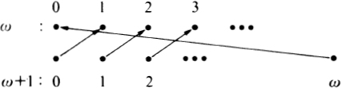

若要成为有用的大小概念，当然必须能比较任意两个给定集合。因此，对任意集合 x、y，需要知道

If this is to be a useful concept of size we must certainly be able to compare any two sets given to us. Thus we need to know, for any sets *x*, *y* that

这确实可由公理证明，事实上它等价于选择公理。这又为选择公理的真实性提供了支持。

This is indeed provable from our axioms. In fact it turns out to be equivalent to the Axiom of Choice. This just gives more evidence for the truth of the Axiom of Choice.

这种大小概念会不会让所有无限集大小相同？若是，就没什么用。幸而无限集有很多种大小：给定任意集合 a，都能给出确定更大的集合，即 a 的幂集。这是康托尔已知的结果，见第 1 章。

Does this concept of size give all the infinite sets the same size? It would not be of much use if it did. Fortunately, however, there are lots of sizes of infinite sets. For take any set *a*, then I can show you a set that is definitely of larger size—the power set of *a*. This is a result known to Cantor (see Chapter 1).

康托尔定理：对任意集合 a，都有 a Pa。

证明：总有 a Pa，因为可把每个 x ∈ a 与 {x} 配对，而 {x} ⊆ a，所以 {x} ∈ Pa。这样把 a 的每个元素与 Pa 的某个元素配对，说明 a Pa。

*Proof*: It is always the case that *a* *Pa*, for I can pair off each *x* ∈ *a* with {*x*}, and certainly {*x*} ⊆ *a*, so that {*x*} ∈ *Pa*. So this pairs off each element of *a* with some element of *Pa*, so showing *a* *Pa*.

现在假设 a Pa，即有函数 f，把 a 的全部元素与 a 的全部子集配对。取 x ∈ a，则 f(x) ⊆ a，因此可问 x ∈ f(x) 是否成立。

Now suppose *a* *Pa*. So there is a function *f* that pairs off all the members of *a* with all the subsets of *a*. Take *x* ∈ *a*, then *f* (*x*) ⊆ *a*, so we may ask if *x* ∈ *f* (*x*).

考虑集合 b，

Consider the set *b*,

因为 b ⊆ a，存在唯一 y ∈ a，使 b = f(y)。问 y ∈ f(y) 是否成立。

Since *b* ⊆ *a* there is a unique *y* ∈ *a* such that *b* = *f*(*y*). Let us ask whether or not *y* ∈ *f*(*y*).

| (i) (i) | 若 y ∈ f(y)，则 y ∈ b，而由 b 的定义，y ∉ f(y)。 If *y* ∈ *f* (*y*), then *y* ∈ *b*, and so *y* ∉ *f*(*y*) by the definition of *b*. |
| --- | --- |
| (ii) (ii) | 另一方面，若 y ∉ f(y)，则 y ∉ b。但由 b 的定义，y ∉ f(y) 又意味着 y ∈ b。 On the other hand, if *y* ∉ *f*(*y*), then *y* ∉ *b*. But if *y* ∉ *f*(*y*) then by the definition of *b*, *y* ∈ *b*. |

因此，两种情形都导致矛盾。矛盾来自假设 a Pa，所以必须断定 a Pa。

这就证明，给定任意集合，特别是无限集，取幂集便能得到更大的集合。这个过程可反复进行，所以无限集有很多种大小。

So this establishes that given any set, in particular an infinite one, I can give you one of larger size by taking its power set. Since I can repeat the process again and again, there are thus lots of sizes of infinite sets.

再看序数：每种可能的大小都有相应序数，这一断言也等价于选择公理。既然如此，可问某种大小的序数有哪些，并取其中最小的。由此可为每种大小选定一个标准序数。有限情形最简单：0 对应没有元素的集合；1 = {0}，直观上有一个元素，因此恰好是单元素集合能与 1 配对；同样，恰好是二元素集合能与 2 = {0,1} 配对，其他有限序数亦然。

Reconsider the ordinal numbers: it turns out there is an ordinal of every possible size. (This statement also is equivalent to the Axiom of Choice.) Knowing that there are ordinals of every possible size, we can ask which ordinals are the first of any particular size. The answer is this: first there are the finite ordinals. There is exactly one of these for each size. 0 is the size of a set with no elements. Since 1 = {0}, and so has (intuitively) one element, exactly the singleton sets can be paired off with 1. Likewise, just the two-element sets can be paired off with 2 = {0, 1}, and similarly for the other finite ordinals.

无限大小如何？第一个无限序数当然是 ω，因此 ω 是最小无限大小的集合，这样的集合称为可列集。何时才遇到更大序数？知道它们存在，但最小的是哪个？不是 ω + 1，因为已证明 ω ω + 1；也不是 ω + 2，因为“最后两个排到最前，其余后移两位”的函数表明 ω ω + 2；同样不是 ω + 3 等。甚至不是 ω + ω，因为把其中前 ω 个元素映到 ω 的偶数元素，后 ω 个映到奇数元素，就说明 ω ω + ω。

What of the infinite sizes? The first infinite ordinal is certainly *ω*. So *ω* is a set of the smallest possible infinite size. (Such sets are called *denumerable*.) Now when am I going to find an ordinal of larger size? I know they exist, but which will be the smallest of them? It is not *ω* + 1, because I showed *ω* *ω* -h 1. Neither is it *ω* + 2, because the function saying ‘the last two shall be the first two and the others move down two’ shows *ω* *ω* + 2. Likewise it is not *ω* + 3 and so on. It is not even *ω* + *ω*, for the function mapping the first *ω* elements in *ω* + *ω* onto the even elements of *ω* and the second *ω* elements in *ω* + *ω* onto the odd elements of *ω* shows *ω* *ω* + *ω*.

图示如下：

Diagrammatically

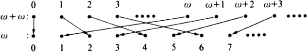

重新考虑康托尔定理，把它用于集合 ω，得到

Reconsider Cantor’s Theorem. Applied to the set *ω*, it says

对任意集合 x，把 |Px| 记为 2^|x|。于是康托尔定理告诉我们：

Let us write 2<sup>|</sup>*<sup>x</sup>*<sup>|</sup> for |**P***x*|, for any set *x*. Then Cantor’s Theorem tells us:

2^ℵ₀ 是某个大于 ℵ₀ 的无限基数。它是哪个？ℵ₁？ℵ₂？……遗憾的是，集合论并不告诉我们，集合论公理未能决定此事。猜想 2^ℵ₀ 尽可能小，即等于 ℵ₁，就是连续统假设（CH）：2^ℵ₀ = ℵ₁，康托尔于 1878 年首次提出。很容易证明 Pω 与实数集大小相同，因此连续统假设是在猜测究竟有多少实数。

对任意无限基数 ℵα，都可问 2^ℵα 是哪个 aleph。康托尔定理说，它必须大于 ℵα。猜想它尽可能小，即 (GCH) 2^ℵα = ℵα₊₁，就是广义连续统假设。集合论公理同样不能决定其真假。

离开基数前，强调怎样检验某个序数 α 是否为基数：当且仅当不存在函数，能把 α 的元素与任何更小序数的元素一一配对。由此产生下述情况。

Before we leave the cardinal numbers, let me emphasize how to test whether a particular ordinal number *α* is in fact a cardinal number. *α* is a cardinal exactly when there is no function available which will pair off (the members of) a with (the members of) any smaller ordinal. This brings about the following situation.

### 选择公理的一致性

### **Consistency of Axiom of Choice**

现在说明：若仅用其他公理推不出矛盾，加上选择公理也推不出。这不过是说，选择公理与集合论其他公理相容。记得，要证明这一点，只需找到其他公理的一种实现，即模型，使选择公理也在其中为真。下面的模型由哥德尔于 1938 年首先发现，称为“可构造集”模型。

Now I want to show you that you cannot get a contradiction using the Axiom of Choice, if you cannot get one just using the other axioms. You will realize that this is merely another way of saying that the Axiom of Choice is consistent with the other axioms of set theory. You remember then that to show the Axiom of Choice is consistent with the other axioms, all we need do is find a realization (that is, a model) of the other axioms in which the Axiom of Choice is also true. The model that I am going to describe was first found by Gödel (in 1938), the model of ‘constructible sets’.

集合论语言只有 ∈ 和 = 两个谓词符号，因此模型须解释它们。模型正规，所以 = 解释为真正的相等；∈ 也解释为模型论域元素之间真正的隶属关系。因此模型形如 ⟨L,∈⟩，按正规模型的约定不再写 =。论域 L 的成员称为可构造集。

The language of set theory has in it just the two predicate .symbols ∈ and =, so our model must give an interpretation for both these. It will be a normal model, so = will be interpreted as true =. We shall also interpret ∈ as ∈, among the elements of the universe of the model. So it will be a model of the form 〈*L*, ∈〉 (not mentioning =, by our convention for normal models). The members of the universe L are called *constructible sets*.

既然关心选择公理的一致性，构造 L 时会谨慎地不使用它。尽管如此，最终选择公理以及其他全部公理都将在 ⟨L,∈⟩ 中为真。

Since we are concerned about the consistency of the Axiom of Choice, I shall be careful not to use it in building up *L*. Nonetheless, it will turn out that this axiom is true in 〈*L*, ∈〉, as well as all the other axioms.

先说明可构造集定义的动机。给定集合 A，只能看到 A 的元素，想象自己被关在 A 这个房间里，此外什么也看不到。能谈论哪些集合，即能说出 A 的哪些子集？通常用概括公理模式构造集合，那么在 A 内怎样进行？模式说，给定公式 ψ(v,v₁,…,vₙ)，这里列出全部自由变量，对任意集合 x₁、……、xₙ，可得到 {x ∈ A : ψ(x,x₁,…,xₙ)}。但在 A 内，能代入自由变量的集合受到限制，必须是 A 的元素 a₁、……、aₙ。还不止如此：若 ψ 提及 Px，x 的某些子集可能不属于 A，因此在 A 内无法谈论真正的 Px。所以不能直接使用 {x ∈ A : ψ(x,a₁,…,aₙ)}。不过可以谈论那些“在 A 看来”具有性质 ψ 的 x，即满足 ⟨A,∈⟩ ⊨ ψ[x,a₁,…,aₙ] 的 x。因此，当然能谈论

Let me try to motivate the definition of a constructible set. Suppose you are given some particular set *A*, and can see nothing except the members of *A*. Think of yourself as shut up in a room that is *A*, able to see nothing but the elements of *A*. What sets can you talk about? In other words, what subsets of *A* can you name? We usually construct sets from the axiom schema of comprehension, so how would we proceed from this in *Α*? The schema says, given any formula *ψ*(*ν*, *v*<sub>1</sub>, ..., *v<sub>n</sub>*) (here I have mentioned all the free variables in *ψ*), for any sets *x*<sub>1</sub>, ..., *x<sub>n</sub>* we can find the set {*x* ∈ *Α*:*ψ*(*x*, *x*<sub>1</sub>, ..., *x<sub>n</sub>*)}. Now consider our plight in *A*. There is a restriction on the sets that we can find to put in for the free variables of ψ: they must be members *a*<sub>1</sub>, ..., *a<sub>n</sub>* of *A*. But this is not all: if *ψ* were to mention say *Px*, it may well be the case that *x* has subsets which are not members of *A*, and so we cannot talk about *Px* from inside *A*. Thus from within *A* we could not use {*x* ∈ *Α*:*ψ*(*x*, *α*<sub>1</sub>, ..., *α<sub>η</sub>*)}. However, what we can do is talk about those *x* which, as far as *A* can see, have the property *ψ* that is, those *x* for which 〈*A*, ∈〉 *ψ*[*x*, *a*<sub>1</sub>, ..., *a<sub>n</sub>*]. So we can certainly talk about

其中 a₁、……、aₙ ∈ A。这种形式的集合称为在 A 中可定义的集合。用 Def(A) 表示所有在 A 中可定义的集合构成的集合，形式地说：

where *a*<sub>1</sub>, ..., *a<sub>n</sub>*∈ *A*. Sets of this form are said to be *definable in A*. Let us write Def(*A*) for the set of all sets definable in *A*, so formally

Def(A) = {y : 对某个公式 ψ(v,v₁,…,vₙ) 及某些 a₁,…,aₙ ∈ A，有 y = {x ∈ A : ⟨A,∈⟩ ⊨ ψ[x,a₁,…,aₙ]}}。

Def(*A*) = {*y*:for some formula *ψ*(*ν*, *v*<sub>1</sub>, ..., *v<sub>n</sub>*) and some *a*<sub>1</sub>, ..., *a<sub>n</sub>* ∈ *A*, *y* = {*x* ∈ *A*:〈*A*, ∈〉 *ψ*[*x*, *a*<sub>1</sub>, ..., *a<sub>n</sub>*]}}.

举一个在 A 中可定义的集合。若 a、b ∈ A，断言 {a,b} 在 A 中可定义。令 ψ(v,v₁,v₂) 为公式

Let us have an example of a set definable *in* *A*. If *a*, *b* ∈ *A*, then I claim that {*a*, *b*} is definable in *A*. Let *ψ*(*ν*, *v*<sub>1</sub>, *v*<sub>2</sub>) be the formula

显然，⟨A,∈⟩ ⊨ ψ[x,a,b] 当且仅当 x = a 或 x = b。

Then it is clear that 〈*A*, ∈〉 *ψ*[*x*, *a*, *b*] if and only if *x* = *a* or *x* = *b*.

因此有

So we have that

故 {a,b} ∈ Def(A)。

Hence {*a*, *b*} ∈ Def(*A*).

有了“在……中可定义”的概念，就能得到哥德尔的可构造集。从空集开始，反复取“在已有集合中可定义的集合所构成的集合”。更精确地说，先定义极限序数：它前面没有紧邻序数，例如 ω、ω + ω；而 ω + 1、ω + ω + 23 等不是极限序数。为定义可构造集，沿全部序数构成的序列前进，经过每个 α 时按如下方式赋予集合 Mα。先令 M₀ = ∅。在 α 后面的 α + 1 处，令 Mα₊₁ 为前一阶段 Mα 加上在 Mα 中可定义的全部集合，即 Mα₊₁ = Mα ∪ Def(Mα)。到极限序数 β 时，这一配方无意义，因为没有紧前的 Mα；此时汇集此前所得的一切：

With the concept of ‘definable in ...’ we can get to Gödel’s constructible sets. We start from the empty set and repeat again and again the operation of taking the set of sets definable in what we already have. To put this a little more precisely, I must first say what a limit ordinal is. A limit ordinal is an ordinal which has no ordinal immediately before it—one like *ω*, or *ω* + *ω*. On the other hand, ones like *ω* + 1, or *ω* + *ω* + 23 are not limit ordinals. To define the constructible sets, think of the line of all ordinals. As we pass each ordinal *α* we assign to it a set *M*<sub>α</sub>, in the following way. First, *M*<sub>0</sub> = ∅. At the ordinal *α* + 1 which is next after *α*, we put for *M*<sub>α + 1</sub> the immediately preceding *M<sub>α</sub>* together with the set of all sets definable in this immediately preceding *M*<sub>α</sub>, so *M*<sub>α + 1</sub> = *M*<sub>α</sub> ∪ Def(*M*<sub>α</sub>). When we come to a limit ordinal *ß*, this recipe is meaningless (for there is no *immediately* preceding *M*<sub>α</sub>). Here we collect together everything that we have obtained so far:

Mβ = ⋃{Mα : α < β}。最后，若集合 x 属于某个 Mα，就称 x 可构造。

*M<sub>β</sub>* = ∪ {*M*<sub>α</sub>: *α* < *β*}. Now finally, a set *x* is said to be *constructible* if *x* is a member of one of the *M*<sub>α</sub>.

把这一性质记为 L(x)，因此

I write *L*(*x*) for this, so

提醒一点：前面定义模型时，模型论域是集合。但 L 太大，不是集合。不过可略改模型定义，使之仍适用于 L。主要是避免写 L ∈ x，因为 L 不可能属于任何集合。这样处理后，⟨L,∈⟩ 确实给出集合论的模型。这里不证明，因为部分内容非常困难。

A word of warning: as we defined a model earlier, the universe of the model was a set. Now it turns out that *L* is not a set: it is too large to be one. However, it is possible to modify slightly the earlier definition, so that it still works for *L*. The main thing is to avoid writing *L* ∈ *x*, for *L* cannot be a member of any set. Once this is done, then 〈*L*, ∈〉 does indeed give us a model for set theory. I shall not go into the proof, for parts of it are very difficult.

还需说明 ⟨L,∈⟩ 满足选择公理。先说明对任意 α，Mα 的元素都能排成列表。由 M 的定义，只需说明怎样把 Mα₊₁ 的新元素加入 Mα 的列表。从 Mα 到 Mα₊₁，是保留已有元素，再加入在 Mα 中可定义的集合。因此只需把后者排成列表。Def(Mα) 的每个成员只依赖一个公式 ψ(v,v₁,…,vₙ)，以及代入自由变量的 a₁、……、aₙ ∈ Mα。语言中公式可数，当然可列出。再利用 Mα 元素的列表，就能对所有可能的 n，列出全部 (n + 1) 元组 ⟨ψ,a₁,…,aₙ⟩。Def(Mα) 中每个对象都由某个这样的元组得到，因此按元组在列表中出现的顺序排列它们，再接到 Mα 的列表后，就得到 Mα₊₁ 的列表。

It remains to show that the Axiom of Choice is satisfied by 〈*L*, ∈〉. I shall show that for any *α*, the members of *M<sub>α</sub>* can be written down in a list. If you think of how *M* was defined, you will see that it is enough to show how the new members of *M<sub>α</sub>*<sub>+ 1</sub> can be added to a list of those in *M<sub>α</sub>*. To go from *M<sub>α</sub>* to*M<sub>α</sub>*<sub>+ 1</sub> I took what was already in *M<sub>α</sub>* and added in the sets definable from *M<sub>α</sub>*. Given a list of the members of *M<sub>α</sub>* I just need a listing of the sets definable in *M<sub>α</sub>* to be able to list *Μ<sub>α</sub>*<sub>+ 1</sub>. Now each member of Def(*M<sub>α</sub>*) depended only on a formula *ψ*(*υ*, *v*<sub>1</sub>, ..., *v<sub>n</sub>*) and the sets *a*<sub>1</sub>, ..., *a<sub>n</sub>*∈ *M<sub>α</sub>* which were substituted for the free variables *v*<sub>1</sub>, ..., *v<sub>n</sub>*. There are a countable number of formulae in our language, so I can certainly write these formulae out in a list. Then, using the list of the members of *M<sub>α</sub>*, I can form a list of all *n* + 1-tuples 〈*ψ*, *a*<sub>1</sub>, ..., *a<sub>n</sub>*〉 (for all possible values of *n*). Anything in Def(*M<sub>α</sub>*) is obtained by using one of these tuples, so the members of Def(*M<sub>α</sub>*) may be listed in the order that their tuples appear in the list of tuples. This list of the members of Def(*M<sub>α</sub>*) is now tacked on to the list of *M<sub>a</sub>* to give us a list of *M<sub>α</sub>*<sub>+ 1</sub>.

利用各 Mα 的列表，可把全部可构造集排序如下。取可构造集 x、y，分别令 α、β 为使 x ∈ Mα、y ∈ Mβ 成立的最小序数。若 α < β，或 α = β 且 x 在 Mα 的列表中先于 y，就把 x 排在 L 的列表中 y 的前面。

Using these lists of the members of each *M<sub>α</sub>*, I can now give a list of all the constructible sets as follows. Take constructible sets *x* and *y*. Let a and *β* be, respectively, the least ordinals for which *x* ∈ *Μ<sub>α</sub>* and *y* ∈ *Μ<sub>β</sub>*. Then *x* is before *y* in the list of *L* if *α* < *β* or if *α* = *β* and *x* is before *y* in the list of *M<sub>α</sub>*.

现在取任意可构造集 x，描述它的选择函数 f。不难证明，若 y ∈ x，则 y 及其全部元素也可构造，因而出现在 L 的列表中。对 x 中每个非空集合 y，令 f(y) 为 L 的列表中第一个满足 z ∈ y 的 z。于是 f 确实是 x 的选择函数。

Now take any constructible set *x*, and I shall describe to you a choice function *f* for *x*. It is easy to show that if *y* ∈ *x* then *y* and all the members of *y* are also constructible, and so occur in our list of *L*. So, for any non-empty set *y* from *x*, let *f*(*y*) be the first *z* in the list of *L* for which *z* ∈ *y*. Then *f* is indeed a choice function for *x*.

要证明 ⟨L,∈⟩ 满足选择公理，还差一点：函数 f 本身必须在 L 中。这确实成立，不过证明更困难。

There is just one more point in establishing that 〈*L*, ∈〉 satisfies the Axiom of Choice. The function *f* must be itself in *L*. This is in fact the case, although it is rather more difficult to show.

这就结束了对哥德尔可构造集的概述：它是选择公理成立的集合论模型，因此选择公理与集合论相容。事实上，广义连续统假设在 L 中也为真，所以 GCH 同样与集合论，包括选择公理，相容。

This concludes my outline of Gödel’s constructible sets—a model of set theory in which the Axiom of Choice is true. The Axiom of Choice is thus consistent with set theory. In fact, the Generalized Continuum Hypothesis is also true in *L*, and so the GCH is likewise consistent with set theory (including the Axiom of Choice).

本章余下部分将说明，选择公理和广义连续统假设各自独立于集合论，即不能从集合论其他公理证明。方法是分别找到使它们为假的集合论模型。保罗·科恩于 1963 年首次找到这些模型，距离人们意识到选择公理是所需集合公理已有约六十年。耗时如此之久，反映出建立模型的困难，也说明这里只能极粗略地介绍方法。事实上，只说明一个比 GCH 独立性稍强的结果：存在连续统假设为假的集合论模型。不处理选择公理，其方法类似，只是更复杂。

In the remainder of this chapter I shall indicate how to show that the Axiom of Choice and the Generalized Continuum Hypothesis are each independent of set theory: neither can be proved from the other axioms of set theory. This is done by finding models of set theory in which each in turn is false. These models were first found in 1963 by Paul Cohen, some sixty years after it was first realized that the Axiom of Choice was an axiom about sets that one needed to have. The fact that it took this long reflects the difficulty in setting up the models, and emphasizes that I shall be presenting only a very rough outline of the method here. I shall in fact show only the result, slightly stronger than the independence of the Generalized Continuum Hypothesis, that there is a model of set theory in which the Continuum Hypothesis is false. I shall not deal with the Axiom of Choice. The method there is similar, just a little more complicated.

记得 CH 断言 2^ℵ₀ = ℵ₁。实际上，可以给出使 2^ℵ₀ = ℵ₂、ℵ₃ 或许多其他无限基数的模型。策略如下：若已能找到一个包含选择公理、但 CH 为假的 ZF 模型，就无需再做什么。因此假定能找到的 ZF 模型都满足 CH，再说明怎样修改其中一个，使 CH 变假。

固定一个 CH 为真的可数 ZF 模型 ⟨M,∈⟩，并进一步假定 M 是传递集，即若 x ∈ M 且 y ∈ x，则 y ∈ M。使用这样的可数传递 ∈ 模型不算限制，因为可以证明，若 ZF 一致，正如一直默默假定的，就有这样的模型。（可数模型的存在来自第 3 章的勒文海姆—斯科伦定理。）要求 M 传递，是因为这样能证明 M 认为是序数的对象确实是序数，而且恰好是某个固定序数以下的全部序数。

So let us fix on a countable model 〈*M*, ∈〉 for ZF, in which CH is true, and I shall assume further that *M* is a transitive set—that is, if *x* ∈ *M* and *y* ∈ *x*, then also *y* ∈ *M*. It is no restriction to use such a countable transitive e-model of ZF, for one can show that if ZF is consistent, as we have tacitly assumed, then it has such a model. (The existence of a countable model comes from the Löwenheim-Skolem theorem of Chapter 3.) I ask that *M* be transitive, for then one can show that what *M* sees as ordinals are truly ordinals, and in fact are all the ordinals less than some fixed ordinal.

可把宇宙中的全部集合画在圆锥内，中央贯穿着按递增顺序排列的序数“脊柱”。集合在锥中的高度衡量其复杂程度。复杂程度由集合的层级给出，即与它同高的序数。这一概念可以精确化。

Pictorially I can represent all the sets in the world as fitting inside a cone, up the middle of which runs the ‘backbone’ of ordinals, in increasing order. The height up the cone that a set falls is a measure of how complicated it is. The degree of complication is given by the level of a set, that is, the ordinal which is at the same height. This notion can be made precise.

传递模型 M 包含某个位置以下的全部序数，以及每层的一部分相应集合。

Our transitive model *M* will have all the ordinals up to some point, plus some of the corresponding sets at each level.

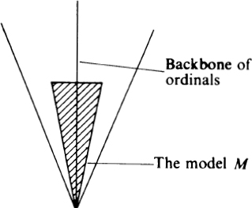

集合宇宙

THE UNIVERSE OF SETS

由于 CH 在 ⟨M,∈⟩ 中为真，其中自然数的子集尽可能少。将说明怎样加入 κ 个额外子集，其中 κ 是 M 中任意固定基数，得到同样传递、具有相同序数的新模型 ⟨N,∈⟩。图上看，N 是与 M 同高、但更宽的楔形区域。

In 〈*M*, ∈〉 there are as few as possible subsets of the natural numbers, for CH is true there. I shall show how to add *κ* extra subsets, where *κ* is any fixed cardinal from *M*, to create a new model 〈*N*, ∈〉, transitive and with the same ordinals in it. Pictorially, *N* is a fatter wedge of the same height as *M*.

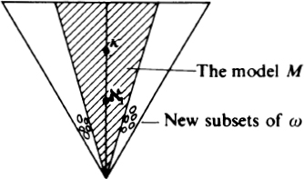

新模型 N

THE NEW MODEL TV

我将在现实世界中说明构造方法。事实上，最后要陈述的大定理，其证明关键在于：M 中的人，即生活在 M 内的人，也能跟上。他会理解并执行部分指令。当然，有些话对他没有意义，例如说 M 可数。M 是他的整个宇宙，他当然不认为 M 可数。关于这一点就不再多说。

I shall describe to you, here in the real world, how to make the construction. In fact, the key point in the proof of the final big theorem that I shall state is the observation that an *M*-person (that is, someone living in *M*) could follow too. He will understand, and be able to carry out, some of the instructions that I shall give. Of course, some of what I say will not make sense to him—for instance, when I say that *M* is countable. *M* is his whole universe, and so *he* certainly does not think that *M* is countable. But I shall say no more on this point.

在尚未指定 N 和 ω 的新子集、还不知道它们究竟是什么之前，为了谈论它们，需要给最终进入 N 的全部集合取名。为此建立一种语言，其形成规则提供构造这些名称的方法。称它为 (M)，依赖原模型 M。(M) 是谓词演算的扩张。

In order to be able to talk about *N* and the new subsets of *ω* before I have specified them, before I know exactly what they are going to be, I want to have names for all the sets that eventually will be in *N*. To do this, I shall set up a language whose formation rules give a way of building up names for all the sets that will be in *N*. Call the language (*M*)—it will depend on our original model *M*. (*M*) is an extension of predicate calculus.

它包含：

It contains:

[output not shown]

(M) 的语句定义与通常谓词演算相同，只需对 α 和 {− : …}α 作简单扩展。模型 N 中每个集合都由上述列表中的项命名。某些集合可能有多个名称，但无妨。

Sentences of (*M*) can be defined as for any predicate calculus, but with a simple extension for <sub>α</sub> and {–: ...}*<sub>α</sub>*. The model *N* will have every set in it named by a term from the above list. Some sets may have many such names, but this will not matter.

用这些符号，按下列方式构造 (M) 的项。同时给每个项赋予 M 中一个序数作为层级，表示最终由该项命名的 N 中集合可能具有的最高复杂层级。

Using these symbols, we form the terms of (*M*) in the following ways. At the same time, I shall assign to each term an ordinal from *M*, its *level*, which indicates the largest level of complexity that the set of *N* eventually to be named by the term may have.

[output not shown]

现在考虑，若要让 N 有希望成为集合论模型，必须对新集合 αη 加哪些限制。假定知道 5 ∈ α₃₇ 或 11 ∉ α₃，N 中还必须成立哪些事实？这类考虑引出下述定义。

We must now consider what restrictions are needed on the new sets *α<sub>η</sub>*, if we are to have any chance of making *N* a model of set theory. Suppose we know that 5 ∈ *α*<sub>37</sub>, or 11 ∉ *a*<sub>3</sub>; what other facts must then hold in *Ν*? Considerations of this type lead to the following definition.

定义。条件 p 是由有序三元组 ⟨n,η,i⟩ 构成的有限一致集，其中 n < ω、η < κ、i = 0 或 1。“一致”指若 ⟨n,η,0⟩ ∈ p，则 ⟨n,η,1⟩ ∉ p，反之亦然。

*Definition*. A *condition* *p* is a finite consistent set of ordered triples 〈*n*, *η*, *i*〉 where *n* < *ω*, *η* < *κ* and *i* = 0, 1. ‘Consistent’ means that if 〈*n*, *η*, 0〉 ∈ *p*, then 〈*n*, *η*, 1〉 ∉ *p*, and vice versa.

每个条件 p 可看作编码了关于模型 N 的少量信息。⟨n,η,0⟩ ∈ p 表示 n ∈ αη；⟨n,η,1⟩ ∈ p 表示 n ∉ αη。若 q 是另一条件，且 p ⊆ q，则 q 提供比 p 更多的信息，称 q 扩张 p。

Each condition *p* can be thought of as encoding a small amount of information about the model *N*. If 〈*n*, *η*, 0〉 ∈ *p*, then this means that *n* ∈ *a<sub>η</sub>*: if 〈*n*, *η*, 1〉 ∈ *p* then *n* ∉ *a<sub>η</sub>*. If *q* is another condition and *p* ⊆ *q*, then *q* gives more information than *p*. I shall say that *q* *extends* *p*.

条件 p 编码的信息可能使 N 中更复杂的事情成立。可以用语言 (M) 谈论 N，因此定义条件 p 与 (M) 的语句 ψ 之间的关系，使它恰在 p 编码的信息导致 ψ 所说的事情成立时成立。虽然尚不知道 N 是什么，却要借此谈论最终在 N 中为真的事情。具体要求如下：

(b) 不存在 G 中的 p、q 以及 (M) 的语句 ψ，使 p ψ 与 q ψ 同时成立。

(b) For no *p*, *q* from *G* and sentence *ψ* in (*M*) do we have both *p* *ψ* and *q* *ψ*.

具有 (a)、(b) 两性质的条件集 G 称为泛型集。可以证明，这样的泛型集确实存在。这是唯一用到 M 可数这一事实的地方。

A set *G* of conditions is called *generic* if it has the properties (a) and (b). One can show that in fact such a generic set does indeed exist. (This is the only point at which one uses the fact that *M* is countable.)

固定一个泛型集 G，用它把语言 (M) 的每个项解释为某个具体集合，最后令 N 为全部这些解释构成的集合。因此，t 一直是其解释的名称。对每个项 t，定义其解释 I(t) 如下：

Now fix on a generic set *G*. I shall use it to give an interpretation, as a particular set, to each of the terms in the language (*M*), and then, finally, our set *N* will be just the set of all these interpretations. (Thus *t* has been a name for its interpretation.) So for each term *t*, I define its interpretation *I*(*t*) as follows:

[output not shown]

因此，{v : ψ(v)}α 被解释为层级小于 α 的那些对象构成的集合，其名称被 G 中某个 p 力迫具有性质 ψ。现在令 N 为全部解释的汇集。再把 ε 和 ≡ 解释为真正的 ∈ 和 =，便能证明一直追求的结果确实发生。

(So 0*ν*:*ψ*(*ν*)}<sub>α</sub> is interpreted as the set of those things of level less than a which some *p* in *G* forces (their name) to have the property *ψ*) Now let *N* be the collection of all the interpretations. If we now interpret *ε* and ≡ as truly ∈ and =, we can prove that what we have been working for actually does happen.

定理（科恩真值引理）：(M) 的语句 ψ 在上述解释下于 N 中为真，当且仅当存在 p ∈ G，使 p ψ。

如前面暗示，这个定理成立，是因为 M 中的人实际上能够理解并写出力迫的定义。由真值引理，关于 N 的问题可改写为关于 M 的问题。既然 M 是集合论模型，就知道那里相应问题的答案。

As I hinted earlier, this theorem holds because in fact an *M*-person can understand and write down the definition of forcing. The Truth Lemma above thus shows that questions about *N* can be rephrased as questions concerning *M*. Since *M* is a model of set theory, we know the answers there.

第 (iii) 部分没有前两部分困难。不难证明，全部 αη 确实互异，即 η ≠ ζ 时 αη ≠ αζ。因此有 κ 个不同的 ω 的子集，故 2^ℵ₀ 至少为 κ。若取 κ = ℵ₂，事实上也可取任意有限 n 对应的 ℵₙ，则有 ⟨N,∈⟩ ⊨ 2^ℵ₀ = κ。因此可有例如满足 2^ℵ₀ = ℵ₂ 的集合论模型。任何这样的模型，都足以确立连续统假设独立于 ZF 集合论。

## 延伸阅读建议

## Some Suggestions for Further Reading

对本书主题作任何深入处理，都涉及相当困难的数学，下面所列书籍没有一本特别易读，这也是我们写作本书的原因之一。

ANY thorough treatment of the topics covered in this book involves quite hard mathematics and none of the books listed below is particularly easy to read (which is one of the reasons we wrote our book).

|  | 涵盖本书以下章节的部分内容 COVERS PARTS OF CHAPTERS |
| --- | --- |
| E. J. 莱蒙：《逻辑入门》。 E.J.LEMMON Beginning logic. | 2 |
| 纳尔逊出版社，1965 年。 (Nelson 1965) |  |
| G. T. 尼博恩：《数理逻辑与数学基础》。 G. T. KNEEBONE Mathematical logic and the foundations of mathematics. | 1, 2, 4, 5, 6 |
| 范诺斯特兰德出版社，1963 年。 (van Nostrand 1963) |  |
| R. R. 斯托尔：《集合论与逻辑》。 R. R. STOLL Set theory and logic. | 2, 5 |
| W. H. 弗里曼出版社，1963 年。 (W. H. Freeman 1963) |  |
| A. 马加里斯：《一阶数理逻辑》。 A. MARGARIS First order mathematical logic. | 2 |
| 布莱斯德尔出版社，1967 年。 (Blaisdell 1967) |  |
| J. W. 罗宾：《数理逻辑初级教程》。 J. W. ROBBIN Mathematical logic, a first course. | 2, 5 |
| 本杰明出版社，1969 年。 (Benjamin 1969) |  |
| A. I. 马尔采夫：《算法与递归函数》。 A. I. MAL’CEV Algorithms and recursive functions. | 4 |
| 沃尔特斯—诺德霍夫出版社，1970 年。 (Wolters-Noordhoff 1970) |  |
| R. C. 林登：《逻辑讲义》。 R. C. LYNDON Notes on logic. | 2, 5 |
| 范诺斯特兰德出版社，1966 年。 (van Nostrand 1966) |  |
| J. R. 舍恩菲尔德：《数理逻辑》。 J. R. SHOENFIELD Mathematical logic. | 1, 6 |
| 艾迪生—韦斯利出版社，1967 年。 (Addison-Wesley 1967) |  |
| E. 门德尔松：《数理逻辑导论》。 E. MENDELSON Introduction to mathematical logic. | 2, 5 |
| 范诺斯特兰德出版社，1964 年。 (van Nostrand 1964) |  |
| P. J. 科恩：《集合论与连续统假设》。 P. J. COHEN Set theory and the Continuum Hypothesis. | 5, 6 |
| 本杰明出版社，1966 年。 (Benjamin 1966) |  |

## 索引

## **Index**

算法 8, 37, 44

algorithm 8, 37, 44

分析学 3

analysis 3

算术 1, 7, 46

arithmetic 1, 7, 46

公理

axiom of

选择公理 9, 63, 70

choice 9, 63, 70

外延公理 60

extensionality 60

基础公理 63

foundation 63

无穷公理 62

infinity 62

配对公理 61, 72

pair set 61, 72

幂集公理 29, 61

power set 29, 61

并集公理 62

union set 62

以下理论的公理

axioms for

算术 46

arithmetic 46

等词 21, 46

equality 21, 46

谓词演算 19

predicate calculus 19

词变换 43

word transformations 43

约束变量 12

bound variable 12

微积分 1

calculus 1

康托尔定理 5, 68, 69

Cantor’s theorem 5, 68, 69

集合的基数 69

cardinality of a set 69

基数 28, 67

cardinal number 28, 67

选择函数 64

choice function 64

科恩真值引理 77

Cohen’s truth lemma 77

紧致性定理 25, 27

compactness theorem 25, 27

谓词演算的完备性 7, 11, 13, 15, 21, 44

completeness of predicate calculus 7, 11, 13, 15, 21, 44

概括公理模式 60

comprehension schema 60

可计算函数 8, 37

computable function 8, 37

联结词 1, 11, 20

connectives 1, 11, 20

以下理论的一致性

consistency of

算术 56

arithmetic 56

选择公理 9, 70

axiom of choice 9, 70

连续统假设 9, 73

continuum hypothesis 9, 73

广义连续统假设 7.

generalized continuum hypothesis 7.

常元字母 20, 26

constant letter 20, 26

可构造集 70

constructible set 70

连续统假设 9, 70

continuum hypothesis 9, 70

广义连续统假设 70, 73

generalized 70, 73

可数的

countable

模型 6, 18

model 6, 18

集合 28

set 28

可判定问题 37

decidable problem 37

小数展开 4

decimal expansion 4

可定义集 71

definable set 71

可列集 28, 69

denumerable set 28, 69

对角线论证 4, 7, 37, 55

diagonal argument 4, 7, 37, 55

空集 62

empty set 62

力迫

forcing

条件 75

condition 75

关系 76

relation 76

形式理论 5

formal theory 5

谓词演算的公式 11

formula of predicate calculus 11

自由变量 12

free variable 12

完全语句集 16

full set of sentences 16

函数 64

function 64

选择函数 64

choice 64

可计算函数 8, 37

computable 8, 37

部分函数 36

partial 36

部分递归函数 37

>recursive 37

递归函数 7, 37

recursive 7, 37

广义连续统假设 70, 73

generalized continuum hypothesis 70, 73

泛型集 77

generic set 77

哥德尔—亨金定理 15, 25, 28

Gödel-Henkin theorem 15, 25, 28

哥德尔数 45, 48

Gödei number 45, 48

哥德尔不完备性定理

Gödel’s incompleteness theorems

第一不完备性定理 46

first 46

第二不完备性定理 57

second 57

停机问题 38, 42

halting problem 38, 42

希尔伯特纲领 45

Hubert’s programme 45

同一性 20

identity 20

算术的不完备性 7, 46, 57

incompleteness of arithmetic 7, 46, 57

以下公理的独立性

independence of

选择公理 73

axiom of choice 73

连续统假设 73

continuum hypothesis 73

无穷小 2

infinitesimals 2

内部状态 32

internal state 32

解释 13, 20

interpretation 13, 20

正规解释 21

normal 21

同构模型 23

isomorphic models 23

说谎者悖论 52

liar paradox 52

极限序数 71

limit ordinal 71

林登鲍姆引理 16

Lindenbaum’s lemma 16

勒文海姆—斯科伦定理 6, 20, 29, 73

Löwenheim-Skolem theorem 6, 20, 29, 73

数学归纳法 46

mathematical induction 46

模型 6, 14, 23

model 6, 14, 23

分离规则 13, 19

*modus ponens* 13, 19

自然数 3, 9, 22, 47, 66

natural numbers 3, 9, 22, 47, 66

非标准模型 27

non-standard model 27

正规解释 21

normal interpretation 21

数码 47

numeral 47

一一对应 27, 67

one-to-one correspondence 27, 67

序数 65

ordinal number 65

悖论 5

paradox 5

说谎者悖论 52

liar 52

罗素悖论 5, 59

Russell 5, 59

斯科伦悖论 6, 70

Skolem 6, 70

谓词

predicate

演算 1, 2, 11, 19

calculus 1, 2, 11, 19

可表示的谓词 53

representable 53

符号 1, 11, 20

symbol 1, 11, 20

量词 1, 11, 20

quantifier 1, 11, 20

有理数 3

rational number 3

实数 4, 9, 28

real number 4, 9, 28

递归的

recursive

函数 7, 37

function 7, 37

谓词 53

predicate 53

替换公理模式 63

replacement schema 63

可表示谓词 53

representable pred cate 53

推理规则 12, 19

rules of inference 12, 19

罗素悖论 5, 59

Russell’s paradox 5, 59

在解释中满足 13

satisfaction in an interpretation 13

语句 12

sentence 12

斯科伦悖论 6, 70

Skolem paradox 6, 70

可解问题 37

solvable problem 37

定理 6, 13, 14

theorem 6, 13, 14

在解释中为真 13, 14

truth in an interpretation 13, 14

图灵机 8, 32, 53

Turing machine 8, 32, 53

谓词演算的不可判定性 8, 44

undecidability of predicate calculus 8, 44

普遍有效公式 12, 14

universally valid formula 12, 14

通用机 39

universal machine 39

不可解问题 8, 31, 38, 39, 42

unsolvable problem 8, 31, 38, 39, 42

变量 12

variable 12

词变换 41

word transformation 41

策梅洛—弗兰克尔集合论 59

Zermelo-Fraenkel set theory 59